# 🔵 MAVİ ÇİZGİ DÜZELTMESİ SÜRÜMÜ — referanslar artık sizin çizdiğiniz sınırlardan alınır

**Neden yeni sürüm?** Önceki sürümlerdeki mavi çizgi eşiği (`rgb_margin = 40`) koyu mavi için ayarlıydı. Sizin çizgileriniz **açık (gök) mavi**dir: mavi kanal yeşil kanaldan ortalama yalnızca ~27 birim büyüktür. Bu yüzden hiçbir görüntüde çizgi bulunamadı ve kod uyarı verip **klasik yöntemin ürettiği sözde-etiketlere** geçti. Önceki bütün eğitimler ve skorlar sizin çizdiğiniz sınırlara göre değil, bu sözde-etiketlere göredir. (00_dataset_grid figüründeki mavi çizgiler de sizin çizgileriniz değil, sözde-etiketten çizilmiş sınırlardı.)

Bu sürümde:

1. **Uyarlanır mavi algılama:** Önce ayardaki eşikler denenir; çizgi bulunamazsa eşikler kademeli olarak gevşetilir (koyu mavi → açık mavi → camgöbeği → soluk çizgi). Her kademede "yara boyunca uzanan iki sınır çizgisi var mı?" diye kontrol edilir.
2. **Yara yönü:** Yaranız dikey bir "nehir"dir (`YARA_YONU = "dikey"`). Eski sürüm geniş görüntülerde yönü yanlış ("yatay") buluyordu; düzeltildi.
3. **Güvenlik kilidi:** `REFERANS_ZORUNLU = True` iken bir görüntüde mavi çizgi bulunamazsa notebook **durur** ve nedenini gösteren bir tanı resmi kaydeder. Uzun eğitim artık yanlış referansla başlamaz.
4. **Kontrol figürü:** `00b_reference_check.png` — her mavi çizgili görüntünün üzerine algılanan sol (kırmızı) ve sağ (mor) sınır çizilir. Eğitim başlamadan önce bu figüre bakın.
5. **Ölçek:** Görüntülerdeki 300 µm ölçek çubuğu otomatik ölçülür; uzunluk ve alan sonuçları µm cinsinden verilir (`PIXEL_SIZE_UM = "auto"`).
6. **Eski sonuçlar kullanılmaz:** Her sonuç dosyasına referans maskelerin ve ayarların **parmak izi** yazılır. Parmak izi tutmayan eski (sözde-etiketli) sonuçlar otomatik olarak yok sayılır; modeller sizin referanslarınızla **yeniden eğitilir**. Eski dosyaları silmeniz gerekmez, üzerine yazılır.
7. **Kesintiye dayanıklı:** Her dış katlama bitince diske kaydedilir. Bilgisayar kapanırsa notebook'u tekrar çalıştırdığınızda **kaldığı katlamadan** devam eder.
8. **Yüksek ve güvenli GPU kullanımı:** Her model için bir eğitim adımının GPU belleği ölçülür. Belleğe sığdığı sürece GA bireyleri, tohum tekrarları ve öğrenme eğrisi eğitimleri **aynı anda** çalışır; sığmayan büyük batch'ler gradyan biriktirmeyle parçalanır. GPU dolu çalışır ama VRAM taşmaz (taşma Windows'ta eğitimi çok yavaşlatır).

**Sıra ve süre:** Önce ana model (Attention U-Net), sonra klasik yöntem, en son U-Net eğitilir. Böylece ana modelin sonuçları ilk biter. Her dış katlamadan sonra kalan süre tahmini ekrana yazılır.

**Kullanım:** (1) Önceki notebook'u kapatın. (2) Bu dosyayı aynı klasöre koyun. (3) Ayar hücresindeki klasör yollarını (`DATA_DIR`, `ANNOT_DIR`, `OUT_ROOT`) kendi yollarınızla değiştirin. (4) Kernel → Restart Kernel and Run All Cells. (5) 4. bölümdeki `00b_reference_check` figürünü kontrol edin.

**Makale figürleri:** Bütün grafik yazıları İngilizcedir (grup adları `DRUG_LABELS` ayarından). Her grafiğin İngilizce açıklaması notebook'ta grafiğin altına ve `outputs_FULL/figures/FIGURE_CAPTIONS_EN.txt` dosyasına yazılır.

# 🩹 Yara İyileşmesi (Scratch / Wound-Healing Assay) — Çoklu Mimari Segmentasyon, Sınır Birleşme Analizi, Genetik Algoritma ile Hiperparametre Optimizasyonu, Zaman ve Doz Tahmini

**Amaç.** Faz-kontrast mikroskopi görüntülerinde iki hücre tabakası arasında kalan "nehir" (yara / hücresiz boşluk) bölgesini piksel düzeyinde bölütlemek, **iki sınırın birbirine yaklaşmasını ve birleşmesini** nicelleştirmek, ilaçların (ati, ap) kontrol ilacına (PLA) göre yara kapanmasına etkisini istatistiksel olarak modellemek ve **hiç gözlenmemiş zaman noktaları** (12, 36, 60, 84, 96 saat) ile **hiç denenmemiş dozlar** (1.41, 1.5, 2.1, 2.25, 2.5 µM) için **görsel tahminler** üretmek.

**Deney tasarımı.** 12 görüntü = 3 ilaç (ati, ap, **PLA = kontrol**) × 4 zaman (0, 24, 48, 72 saat). **Üç grubun hepsi tek doz, 1 µM** uygulanmıştır (veride 0 µM grubu yoktur).

**Referans (ground truth):** Her görüntü için iki yara sınırının **mavi çizgiyle** çizildiği bir kopya (`data/annotated/`). Kod mavi çizgileri otomatik algılar, iki sınırın arasını doldurarak yara maskesini ve **sol/sağ sınır eğrilerini** çıkarır.

| Bölüm | İçerik |
| --- | --- |
| 0–2 | Kurulum (Jupyter içinden), donanım optimizasyonu + CPU/GPU monitörü, konfigürasyon |
| 3 | Veri yükleme, dosya adından ilaç/zaman/doz çıkarma |
| 4 | **Mavi çizgi referanslarından** maske + sınır eğrileri (yedek: manuel maske / LabelMe / sözde-etiket) |
| 5–6 | GPU'da veri artırma; kayıplar; **metrikler** (Dice, IoU, F1, Accuracy, Precision, Recall, Specificity, MCC, κ, HD95, alan hatası, **sınır konum hatası, genişlik hatası, birleşme oranı**) |
| 7 | **Model hayvanat bahçesi:** CNN (U-Net, U-Net++, Attention U-Net, U-Net 3+, DeepLabv3+, FPN, MA-Net), Vision Transformer (SegFormer, TransUNet), SAM ViT-B, MobileSAM, Vision GNN, INR (SIREN), MLP-Mixe… |
| 8–9 | Eğitim motoru (AMP, TTA, kayan pencere) ve **Genetik Algoritma** |
| 10 | Çapraz doğrulama — her model **ayrı ayrı** (ROC/PR eğrileri dahil); **yarı-denetimli öz-eğitim ablasyonu**; **öğrenme eğrisi** |
| 11 | Tüm modellerin **birlikte** karşılaştırılması: **ROC–AUC, PR–AP**, istatistik testler, Pearson r / Lin CCC |
| 12 | Regresyon (alan ~ zaman × ilaç, PLA referans), kinetik modeller (Gompertz dahil), **sınır kapanması ve birleşme analizi** (görüntü başına çoklu genişlik ölçümü, iki yönlü ANOVA + Tukey) |
| 13 | **Zaman tahmini** (12–96 h) + **sınırların birleşme zamanı** tahmini |
| 14 | **Doz tahmini** (tek doz verisinden, varsayımları açık senaryolar + Monte Carlo + duyarlılık analizi) |
| 15 | Kaynak kullanım raporu ve dışa aktarma |

### Az veriyle başarı: incelenen makalelerden alınan stratejiler

| Makale | Az veri stratejisi | Bu notebook'taki karşılığı |
| --- | --- | --- |
| **Ramesh, Liu & Tasdizen (2017)**, *J. Healthc. Eng.* 2017:4080874 | Yalnızca 2 eğitim görüntüsü; görüntüleri ~1/8 boyutunda **alt-görüntülere** bölme; etiketsiz test görüntülerini de kullanan **yarı-denetimli (transdüktif)** öğrenme; MSER uç-bölgeleri; ilastik olasılı… | Yama tabanlı eğitim; **SSL öz-eğitim ablasyonu** (test görüntüsünün etiketi kullanılmadan sözde-etiketle ince ayar); MSER yoğunluk özniteliği; `N_REPEATS` tohum tekrarı; **öğrenme eğrisi** (1→9 eğitim… |
| **Rosoff, Elkabetz & Gheber (2022)**, *Microsc. Microanal.* 28:1712 | ilastik **paralel Random Forest** (37 çok ölçekli öznitelik, 100 ağaç), **tek görüntüde seyrek etiketle** eğitim, olasılık haritasına **Otsu eşiği**; doğrulama: Accuracy/Precision/Sensitivity + alan e… | ilastik-tipi öznitelikli RF; GA'da **`thr_mode` (sabit / Otsu)** geni; alan ve genişlik için **Pearson r (%99 GA) + Lin CCC**; kinetik modellere **Gompertz** eklendi; kinetik parametrelerin yöntemler … |
| **Plotczyk vd. (2023)**, *npj Regen. Med.* 8:1 | N=3 hasta, her örnekte **çok sayıda ölçüm** (ör. kalınlık 150 µm arayla 10 konumda); ilastik ile 6 görüntüde eğitim → toplu işleme; **iki yönlü ANOVA + Tukey**, normallik (D'Agostino–Pearson), paramet… | Her görüntüde yara boyunca **eşit aralıklı K konumda genişlik**; **ilaç × zaman iki yönlü ANOVA + Tukey HSD**, D'Agostino–Pearson, Kruskal–Wallis; her sınır için **yay/kiriş (tortuosity)**; raporlarda… |

> **Bilimsel dürüstlük:** 12 görüntü derin öğrenme için çok küçüktür. Ön-eğitimli ağırlıklar, yoğun veri artırma, yama tabanlı eğitim, sızıntısız çapraz doğrulama ve yukarıdaki stratejiler bu yüzden kullanılır. Zaman ekstrapolasyonları ve **özellikle doz tahminleri** (veride tek doz var) model tabanlı hipotezlerdir; belirsizlik aralıklarıyla raporlanmalıdır.

## ⚙️ KULLANICI AYARLARI — elle değiştirmeniz gereken her şey bu hücrede

Notebook'ta **yalnızca aşağıdaki hücreyi** düzenlemeniz gerekir; diğer hücrelere dokunmayın.

- **Donanım:** Kod sizin bilgisayarınız (i5-11260H, 32 GB RAM, RTX 3050 4 GB) düşünülerek ayarlandı ama bu özellikleri **hiçbir yerde varsaymaz veya kontrol etmez**. Çekirdek sayısı, GPU, VRAM ve uygun PyTorch sürümü (CUDA 12.6 / CUDA 13.0 / CPU) her bilgisayarda çalışma anında okunur ve ayarlar buna göre seçilir. Aynı notebook başka bir bilgisayarda değişiklik yapmadan çalışır.
- **Windows yolları:** Tam yol yazarken başına `r` koyun: `r"C:\Users\DELL\Desktop\yara\data\images"`. İsterseniz ters bölü yerine `/` da kullanabilirsiniz.
- **Göreli yollar** (ör. `"data/images"`) notebook dosyasının bulunduğu klasöre göredir.

```python
# WH-ALWAYS
# ╔══════════════════════════════════════════════════════════════════════════════════════╗
# ║  ⚙️  KULLANICI AYARLARI — elle değiştirmeniz gereken HER ŞEY yalnızca bu hücrededir.  ║
# ╚══════════════════════════════════════════════════════════════════════════════════════╝
from pathlib import Path

# ── 1) ÇALIŞMA MODU ───────────────────────────────────────────────────────────────────────
MODE = "FULL"                  # makale sonuçları için "FULL" (çıktılar OUT_ROOT/outputs_FULL klasörüne yazılır)

# ── 2) KLASÖRLER / DOSYALAR ───────────────────────────────────────────────────────────────
PROJE_KLASORU = Path(".")                              # "." = notebook'un bulunduğu klasör
DATA_DIR  = PROJE_KLASORU / r"C:/Users/DELL/Downloads/merve_sent/makale verisi" / "sade"          # ⭐ 12 HAM (çizimsiz) görüntü
ANNOT_DIR = PROJE_KLASORU / r"C:/Users/DELL/Downloads/merve_sent/makale verisi" / "mavili"      # ⭐ 12 MAVİ ÇİZGİLİ referans görüntü
MASK_DIR  = PROJE_KLASORU / "data" / "masks"           # (opsiyonel) hazır maske varsa; yoksa boş/eksik olabilir
META_CSV  = PROJE_KLASORU / "data" / "metadata.csv"    # (opsiyonel) dosya adından ilaç/zaman okunamıyorsa
OUT_ROOT  = PROJE_KLASORU                              # sonuçlar  OUT_ROOT/outputs_<MODE>  klasörüne yazılır
CKPT_DIR  = PROJE_KLASORU / "checkpoints"              # SAM / MobileSAM ağırlıkları (otomatik indirilir)
DEMO_IF_EMPTY = False           # DATA_DIR boşsa sentetik DEMO veri üretilsin mi? (gerçek veriyle False önerilir)

# ── 3) DENEY TASARIMI ─────────────────────────────────────────────────────────────────────
# Dosya adlarınız: 0_ap, 0_ati, 0_control, 24_ap, … 72_atı  →  sayı = saat, "control" = PLA (kontrol), doz = 1 µM.
# Aynı adlar mavi çizgili klasörde de olabilir. Türkçe karakter (atı) ve büyük/küçük harf sorun değildir.
DRUGS     = ["ati", "ap", "PLA"]                       # gruplar (dosya adındaki "control" otomatik olarak PLA'ya eşlenir)
CONTROL   = "PLA"                                      # kontrol (referans) grubu
TIMES_OBS = [0, 24, 48, 72]                            # gözlenen zamanlar (saat)
DOSE_UM   = {"ati": 1.0, "ap": 1.0, "PLA": 1.0}        # her grubun dozu (µM)
PIXEL_SIZE_UM = "auto"         # µm/piksel: "auto" = görüntüdeki ölçek çubuğundan ölç | sayı (ör. 2.91) | None = piksel birimi
OLCEK_CUBUGU_UM = 300          # görüntülerin sağ altındaki ölçek çubuğunun gerçek uzunluğu (µm)

# ── 4) TAHMİN HEDEFLERİ ───────────────────────────────────────────────────────────────────
TIME_TARGETS = [12, 36, 60, 84, 96]                    # görsel tahmin istenen zamanlar (saat)
DOSE_TARGETS = [1.41, 1.5, 2.1, 2.25, 2.5]             # tahmin istenen dozlar (µM)

# ── 5) MAVİ ÇİZGİ (REFERANS) ALGILAMA ────────────────────────────────────────────────────
BLUE = dict(h_lo=80, h_hi=135,  # mavi ton aralığı (OpenCV HSV, 0–180); 80–135 açık maviyi ve camgöbeğini de kapsar
            s_min=50, v_min=40, # doygunluk / parlaklık alt sınırı
            rgb_margin=15,      # mavi kanalın yeşil/kırmızıdan en az bu kadar büyük olması (sizin açık mavi çizgileriniz ≈ 27)
            min_len_frac=0.15,  # çizgi parçasının yara boyuna oranla en kısa uzunluğu
            close_px=3)         # çizgideki küçük boşlukları kapatma yarıçapı (piksel)
                                # Not: bu eşiklerle çizgi bulunamazsa kod eşikleri kendisi kademeli gevşetir.
YARA_YONU = "dikey"            # yara (nehir) yönü: "dikey" (sınırlar solda ve sağda) | "yatay" | "otomatik"
REFERANS_ZORUNLU = True        # True: bir görüntüde mavi çizgi bulunamazsa DUR (sözde-etiketle sessizce devam etme)
MERGE_THR_PX  = None           # bu genişliğin (orijinal piksel) altı "birleşmiş" sayılır; None = otomatik
N_WIDTH_LINES = 20             # her görüntüde yara genişliğinin ölçüleceği konum sayısı

# ── 6) MODEL SEÇİMİ ──────────────────────────────────────────────────────────────────────
MODELS = ["U-Net", "Attention U-Net", "Klasik (Varyans+Otsu)"]   # sıra otomatik: ANA_MODEL → klasik → diğerleri
                               # yalnızca ana model + klasik isterseniz: MODELS = ["Attention U-Net", "Klasik (Varyans+Otsu)"]
                               # ⚠️ her ek derin model (ör. "U-Net++") 4 GB'lık GPU'da süreyi ~6–7 saat uzatır
SKIP_MODELS = []               # atlanacak modeller, ör. ["SAM ViT-B"]
SAM_CUSTOM_CKPT = None         # (opsiyonel) alan-özel SAM ViT-B ağırlığı, ör. CKPT_DIR / "vit_b_lm.pt"

# ── 7) DONANIM — "auto" her bilgisayarda kendiliğinden ayarlanır; yalnızca isterseniz sayı yazın ──
DEVICE_PREF = "auto"           # "auto" | "cuda" | "cpu"
BATCH_MULT  = "auto"           # batch çarpanı: "auto" (VRAM'e göre) veya sayı, ör. 1.5
GA_WORKERS  = "auto"           # aynı anda eğitilebilecek en fazla model: "auto" (VRAM ölçülerek) veya 1, 2, 3…
N_THREADS   = "auto"           # CPU iş parçacığı: "auto" (tümü) veya sayı

# ── 8) DİĞER ─────────────────────────────────────────────────────────────────────────────
RESUME       = True            # yarıda kalırsa tamamlanan katlamaları/modelleri tekrar eğitme (yalnız AYNI referans + ayarla üretilenler)
CV_SCHEME    = "latin4"        # "latin4" (4 katlı, önerilen) | "loocv" (12 katlı)
AUTO_INSTALL = True            # eksik paketleri ve bu bilgisayara uygun PyTorch'u otomatik kur
SEED         = 42              # tekrarlanabilirlik için rastgelelik tohumu

# ── 9) ANALİZ SEÇENEKLERİ ────────────────────────────────────────────────────────────────
ANA_MODEL      = "Attention U-Net"  # makalenin ana modeli: regresyon, sınır/birleşme, kinetik ve zaman tahmini bununla yapılır
TOPLULUK       = False              # True: modellerin olasılık ortalaması (ensemble) da hesaplanır
SSL_ABLASYON   = False              # True: öz-eğitim ablasyonu (model başına 4 ek eğitim; uzun sürer)
OGRENME_EGRISI = "hızlı"            # "kapalı" | "hızlı" (16 eğitim) | "tam" (40 eğitim) — EN SONDA çalışır, diğer sonuçları bekletmez
DOZ_ANALIZI    = True               # 14. bölüm (doz senaryoları); birkaç dakika sürer

# ── 10) MAKALE FİGÜRLERİ (bütün grafik yazıları İngilizce) ──────────────────────────────────
DRUG_LABELS = {"ati": "ATI", "ap": "ATI-PLA", "PLA": "PLA"}   # grafiklerde görünecek grup adları (makaledeki adlarla aynı olmalı)
FIG_CAPTION_IN_IMAGE = False   # False: İngilizce açıklamalar figures/FIGURE_CAPTIONS_EN.txt dosyasına ve notebook'ta grafiğin altına yazılır
                               # True : açıklama ayrıca PNG resminin altına da basılır (dergiler açıklamayı genelde metin olarak ister)

print(f"✅ Ayarlar yüklendi | MODE = {MODE} | ana model: {ANA_MODEL} | veri: {Path(DATA_DIR).resolve()} | referans: {Path(ANNOT_DIR).resolve()}")
```

```
✅ Ayarlar yüklendi | MODE = FULL | ana model: Attention U-Net | veri: C:\Users\DELL\Downloads\merve_sent\makale verisi\sade | referans: C:\Users\DELL\Downloads\merve_sent\makale verisi\mavili
```

## 0. Kurulum ve ortam kontrolü (Jupyter içinden — Anaconda Prompt gerekmez)

**Nasıl çalıştırılır:** Menüden **Kernel → Restart Kernel and Run All Cells** (Çekirdeği yeniden başlat ve tüm hücreleri çalıştır).

Bu hücre her şeyi kendisi yapar:

1. **Zincirleme hata koruması:** Bir hücre hata verirse sonraki hücreler 40 ayrı `NameError` üretmez; tek satırlık "atlandı" mesajı yazar. Böylece **asıl hata** tek başına görünür. Hatalı hücreyi düzeltip yeniden çalıştırırsanız koruma kendiliğinden kalkar.
2. **OpenMP çakışması önlemi:** Anaconda'da hem Intel (`libiomp5md.dll`) hem LLVM (`libomp.dll`) OpenMP kütüphaneleri bulunabilir. Bu durumda `OMP: Error #15` hatası alınır. Hücre, PyTorch'un önerdiği `KMP_DUPLICATE_LIB_OK=TRUE` ayarını **her şeyden önce** yapar.
3. **PyTorch'u kontrol eder ve gerekirse onarır.** Kontrol **ayrı bir süreçte** yapılır, bu çekirdeğe DLL yüklenmez. Onarım gerektiren durumlar:
   - PyTorch kurulu değil, ya da **CPU sürümü** kurulu (ör. `2.14.0+cpu`) ama bilgisayarda NVIDIA GPU var → **CUDA 12.6** sürümü kurulur.
   - `torchvision` sürümü `torch` ile **uyumsuz** (ör. torch 2.14 + torchvision 0.26) → eşleşmiş çift kurulur.
   - Yarım kalmış kurulum artıkları (`~orch` gibi klasörler) bulunuyor → temizlenir.

   İndirme yaklaşık 2.5 GB'tır ve ilk seferde birkaç dakika sürer.
4. **Eksik paketleri kurar.** Paketler kurulumdan önce **import edilmez**. Kurulum, torch/torchvision/numpy sürümlerini sabitleyen bir kısıt dosyasıyla yapılır; böylece Anaconda'daki mevcut paketler bozulmaz.
5. **Kütüphaneleri çakışmasız yükler.** Jupyter çekirdeği açılırken kendi kütüphanelerini (zmq, ssl, sqlite3, tornado, debugpy) yükler. Windows + Anaconda'da bunların DLL'leri bazen PyTorch'unkilerle çakışır; sizin bilgisayarınızdaki `WinError 127 … shm.dll` hatası bu yüzdendi. Hücre bu durumu önce ayrı bir süreçte taklit ederek test eder ve çakışmaya yol açan modülü raporlar.
6. **Çakışma varsa** PyTorch'u Jupyter'dan **önce** yükleyen özel bir çekirdek kurar: **"Python 3 (Yara - torch önce)"**. Bu çekirdek Anaconda'nızı kullanır, ek indirme veya yönetici izni gerekmez. Hücre çekirdeği gerçekten başlatıp içinde tüm kütüphaneleri dener, sonra size **tek seferlik** şu adımı söyler: **Kernel → Change Kernel… → "Python 3 (Yara - torch önce)"**, ardından **Restart Kernel and Run All Cells**. Notebook'u kaydedince bu seçim hatırlanır. Çakışma olmayan bilgisayarlarda bu adım hiç çıkmaz.

```python
# WH-ALWAYS  (bu satır, hücrenin koruma tarafından hiçbir zaman atlanmamasını sağlar)
import os, sys, re, json, shutil, subprocess, importlib, importlib.util, importlib.metadata as _md
from pathlib import Path

# ---- 1) OpenMP / iş parçacığı ortam değişkenleri: torch, numpy vb. YÜKLENMEDEN ÖNCE ----
os.environ["KMP_DUPLICATE_LIB_OK"] = "TRUE"           # Anaconda'da Intel + LLVM OpenMP çakışması (OMP: Error #15)
_nt = globals().get("N_THREADS", "auto")
N_CPU = int(_nt) if str(_nt).isdigit() else (os.cpu_count() or 4)
if str(globals().get("DEVICE_PREF", "auto")).lower() == "cpu":
    os.environ["WH_FORCE_CPU"] = "1"
for _v in ["OMP_NUM_THREADS", "MKL_NUM_THREADS", "OPENBLAS_NUM_THREADS", "NUMEXPR_NUM_THREADS", "VECLIB_MAXIMUM_THREADS"]:
    os.environ.setdefault(_v, str(N_CPU))
if os.name != "nt":
    os.environ.setdefault("PYTORCH_CUDA_ALLOC_CONF", "expandable_segments:True")

# ---- 2) Zincirleme hata koruması ----
try:
    from IPython import get_ipython
    _ip = get_ipython()
except Exception:
    _ip = None
if _ip is not None:
    import builtins
    if not hasattr(builtins, "_WH_GUARD"):
        builtins._WH_GUARD = {"failed": None}
    _WH = builtins._WH_GUARD
    _WH["failed"] = None
    _norm = lambda src: "\n".join(l.rstrip() for l in str(src).strip().splitlines())
    def _wh_post(result):
        src = _norm(getattr(result.info, "raw_cell", "") or "")
        err = result.error_in_exec is not None or result.error_before_exec is not None
        if err and _WH["failed"] is None:
            _WH["failed"] = src
            print("\n⛔ Bu hücrede hata oluştu. Sonraki hücreler otomatik olarak ATLANACAK (zincirleme hata olmasın diye).\n"
                  "   Yukarıdaki hata mesajını okuyun, sorunu giderin, sonra bu hücreyi tekrar çalıştırın "
                  "veya Kernel → Restart Kernel and Run All Cells yapın.")
        elif not err and _WH["failed"] is not None and src == _WH["failed"]:
            _WH["failed"] = None
            print("✅ Hatalı hücre artık başarılı; koruma kaldırıldı. Sonraki hücreleri çalıştırabilirsiniz.")
    def _wh_transform(lines):
        src = _norm("".join(lines))
        if _WH["failed"] is None or "# WH-ALWAYS" in src or src == _WH["failed"]:
            return lines
        return ["print('⏭  Atlandı: daha önceki bir hücrede hata var (⛔ işaretli hücreye bakın).')\n"]
    for _f in list(_ip.events.callbacks.get("post_run_cell", [])):
        if getattr(_f, "__name__", "") == "_wh_post":
            _ip.events.unregister("post_run_cell", _f)
    _ip.events.register("post_run_cell", _wh_post)
    _ip.input_transformers_post[:] = [t for t in _ip.input_transformers_post if getattr(t, "__name__", "") != "_wh_transform"]
    _ip.input_transformers_post.append(_wh_transform)

# ---- 3) Ayarlar (kullanıcı ayarları hücresinden; yoksa varsayılan) ----
AUTO_INSTALL = bool(globals().get("AUTO_INSTALL", True))
TORCH_PAIR = ("2.12.1", "0.27.1")                               # sınanmış, eşleşmiş torch/torchvision çifti
PT_INDEX = "https://download.pytorch.org/whl/"

def _run(cmd, show=True):
    """Komutu çalıştır, çıktısını hücreye canlı yaz."""
    cmd = list(map(str, cmd))
    if show:
        print(">>", " ".join(cmd))
    p = subprocess.Popen(cmd, stdout=subprocess.PIPE, stderr=subprocess.STDOUT, text=True, encoding="utf-8",
                         errors="replace", env=os.environ.copy())
    out = []
    for line in p.stdout:
        out.append(line)
        if show and line.strip() and not line.startswith(("  Downloading", "  Using cached")):
            print("  ", line.rstrip()[:200])
    p.wait()
    return p.returncode, "".join(out)

def _pip(*args):
    return _run([sys.executable, "-m", "pip", "install", "--progress-bar", "off", "--disable-pip-version-check", *args])

def _ver(pkg):
    try:
        return _md.version(pkg)
    except _md.PackageNotFoundError:
        return None

def _site_dirs():
    return sorted({Path(p) for p in sys.path if p.lower().endswith("site-packages") and Path(p).is_dir()})

def _leftovers():
    out = []
    for sd in _site_dirs():
        out += [p for p in sd.iterdir() if p.name.startswith("~") and p.name[1:].split("-")[0] in
                ("orch", "orchvision", "orchaudio", "unctorch", "orchgen")]
    return out

def _gpu_info():
    """(GPU adı, compute capability) — NVIDIA GPU yoksa (None, None). Hiçbir donanım varsayılmaz."""
    smi = shutil.which("nvidia-smi") or (r"C:\Windows\System32\nvidia-smi.exe" if os.name == "nt" else None)
    if not smi or not Path(smi).exists():
        return None, None
    try:
        r = subprocess.run([smi, "--query-gpu=name", "--format=csv,noheader"], capture_output=True, text=True, timeout=20)
        name = r.stdout.strip().splitlines()[0] if r.returncode == 0 and r.stdout.strip() else None
        cc = None
        r2 = subprocess.run([smi, "--query-gpu=compute_cap", "--format=csv,noheader"], capture_output=True, text=True, timeout=20)
        if r2.returncode == 0:
            try:
                cc = float(r2.stdout.strip().splitlines()[0])
            except Exception:
                cc = None
        return name, cc
    except Exception:
        return None, None

def _torch_index(gpu, cc):
    """Bu bilgisayara uygun PyTorch paket deposu: Mac → PyPI, NVIDIA yok → CPU, Blackwell (RTX 50xx) → cu130, diğer → cu126."""
    if sys.platform == "darwin":
        return None, "PyPI (macOS)"
    if not gpu or str(globals().get("DEVICE_PREF", "auto")).lower() == "cpu":
        return PT_INDEX + "cpu", "CPU"
    if cc is not None and cc >= 10.0:
        return PT_INDEX + "cu130", "CUDA 13.0"
    return PT_INDEX + "cu126", "CUDA 12.6"

def _tv_expected(tver):
    m = re.match(r"(\d+)\.(\d+)", tver or "")
    return f"0.{int(m.group(2)) + 15}" if m and m.group(1) == "2" else None

def torch_import_test():
    """Ayrı süreçte yalnızca torch + torchvision (kurulumun sağlam olup olmadığı)."""
    code = ("import os; os.environ['KMP_DUPLICATE_LIB_OK']='TRUE'\n"
            "import torch, torchvision\n"
            "x = torch.ones(2, 2) @ torch.ones(2, 2)\n"
            "ok = torch.cuda.is_available()\n"
            "print('OK torch', torch.__version__, '| torchvision', torchvision.__version__, '| CUDA', torch.version.cuda, "
            "'| GPU', ok, '|', torch.cuda.get_device_name(0) if ok else '-')\n")
    r = subprocess.run([sys.executable, "-c", code], capture_output=True, text=True, encoding="utf-8", errors="replace",
                       env=os.environ.copy())
    return r.returncode == 0, ((r.stdout or "") + (r.stderr or "")).strip()
```

```python
# ---- 4) PyTorch kontrolü ve otomatik onarım ----
GPU_HW, GPU_CC = _gpu_info()
TORCH_INDEX, _idx_label = _torch_index(GPU_HW, GPU_CC)
tv_, tvv_ = _ver("torch"), _ver("torchvision")
print(f"NVIDIA GPU (nvidia-smi): {GPU_HW or 'bulunamadı'}" + (f" | compute capability {GPU_CC}" if GPU_CC else ""))
print(f"Kurulu torch: {tv_} | torchvision: {tvv_} | bu bilgisayar için uygun paket: {_idx_label}")
reasons = []
if tv_ is None:
    reasons.append("torch kurulu değil")
else:
    _cpu_build = "+cpu" in tv_ or (os.name == "nt" and "+cu" not in tv_)
    if GPU_HW and _idx_label.startswith("CUDA") and _cpu_build:
        reasons.append(f"CPU sürümü kurulu ({tv_}) ama NVIDIA GPU var")
    if GPU_HW and GPU_CC is not None and GPU_CC >= 10.0 and re.search(r"\+cu1[01]\d", tv_ or ""):
        reasons.append(f"GPU'nuz (compute {GPU_CC}) için CUDA 12.6 sürümü yetersiz ({tv_})")
    if tvv_ is None or not str(tvv_).startswith(str(_tv_expected(tv_)) + "."):
        reasons.append(f"torchvision {tvv_} ↔ torch {tv_} uyumsuz (beklenen {_tv_expected(tv_)}.x)")
if _leftovers():
    reasons.append("yarım kalmış kurulum artıkları: " + ", ".join(p.name for p in _leftovers()))
TORCH_OK, _tmsg = (False, "") if tv_ is None else torch_import_test()
if tv_ is not None and not TORCH_OK:
    reasons.append("ayrı süreçte 'import torch' başarısız")
    print("Test çıktısı (son satırlar):\n", _tmsg[-800:])

if reasons and AUTO_INSTALL:
    if "torch" in sys.modules:
        if os.environ.get("WH_TORCH_FIRST_KERNEL") == "1":
            print("⚠️ PyTorch onarımı gerekiyor ama bu özel çekirdek torch'u açılışta yüklüyor (dosyalar kilitli).\n"
                  "   → Kernel → Change Kernel → 'Python 3' seçip bu hücreyi bir kez çalıştırın (onarım yapılır),\n"
                  "     sonra tekrar 'Python 3 (Yara - torch önce)' çekirdeğine dönüp Restart & Run All yapın.")
        else:
            print("⚠️ Onarım gerekiyor ama torch bu çekirdekte zaten yüklü (dosyalar kilitli).\n"
                  "   → Kernel → Restart Kernel and Run All Cells yapın.")
        raise RuntimeError("PyTorch onarımı için çekirdeği yeniden başlatın.")
    print("🔧 PyTorch onarılıyor. Nedenler:\n   - " + "\n   - ".join(reasons))
    print("   (Açık olan başka notebook/Spyder pencerelerini kapatın; torch dosyalarını kilitleyebilirler.)")
    for _ in range(2):
        _run([sys.executable, "-m", "pip", "uninstall", "-y", "torch", "torchvision", "torchaudio"], show=False)
    for p in _leftovers():
        try:
            shutil.rmtree(p) if p.is_dir() else p.unlink(); print("   artık silindi:", p.name)
        except Exception as ex:
            print("   silinemedi:", p, ex)
    cons = Path.home() / ".wh_constraints.txt"
    npv = _ver("numpy")
    cons.write_text(f"numpy=={npv}\n" if npv else "", encoding="utf-8")
    _idx_args = ["--index-url", TORCH_INDEX] if TORCH_INDEX else []
    print(f"⬇️  torch {TORCH_PAIR[0]} + torchvision {TORCH_PAIR[1]} ({_idx_label}) indiriliyor "
          f"({'~2.5 GB' if _idx_label.startswith('CUDA') else '~250 MB'}, birkaç dakika)...")
    rc, out = _pip("--no-cache-dir", f"torch=={TORCH_PAIR[0]}", f"torchvision=={TORCH_PAIR[1]}", *_idx_args, "-c", cons)
    if rc != 0:
        print("Sabit sürüm bulunamadı; bu depodaki en güncel eşleşmiş çift deneniyor...")
        rc, out = _pip("--no-cache-dir", "torch", "torchvision", *_idx_args, "-c", cons)
    importlib.invalidate_caches()
    TORCH_OK, _tmsg = torch_import_test()

if not TORCH_OK:
    print("❌ PyTorch bu Python ortamında hâlâ yüklenemiyor. Hata özeti:\n", _tmsg[-1500:])
    print("\n→ Aşağıdaki '0.1 Onarım' hücresi otomatik tanı yapacak. En kesin çözüm orada CREATE_ENV = True "
          "(ayrı ortam + Jupyter çekirdeği).")
    raise RuntimeError("PyTorch yüklenemedi — 0.1 onarım hücresine bakın.")
print("✅", [l for l in _tmsg.splitlines() if l.startswith("OK")][-1])
if GPU_HW and "GPU False" in _tmsg and _idx_label.startswith("CUDA"):
    print("⚠️ NVIDIA GPU var ama PyTorch onu göremiyor. NVIDIA sürücünüzü güncelleyin (NVIDIA App / GeForce Experience) "
          "ve bilgisayarı yeniden başlatın. Bu arada kod CPU'da çalışır (çok daha yavaş).")
if not GPU_HW:
    print("ℹ️ Bu bilgisayarda NVIDIA GPU yok: kod CPU'da çalışacak (daha yavaş). MODE='QUICK' ile başlamanız önerilir.")

# ---- 5) Diğer paketler: import ETMEDEN kontrol et, eksikse sürüm kısıtlı kur ----
cons = Path.home() / ".wh_constraints.txt"
cons.write_text("".join(f"{k}=={v}\n" for k, v in [("torch", _ver("torch")), ("torchvision", _ver("torchvision")),
                                                     ("numpy", _ver("numpy"))] if v), encoding="utf-8")
PKGS = [("numpy", "numpy"), ("pandas", "pandas"), ("scipy", "scipy"), ("matplotlib", "matplotlib"), ("seaborn", "seaborn"),
        ("cv2", "opencv-python"), ("skimage", "scikit-image"), ("sklearn", "scikit-learn"), ("statsmodels", "statsmodels"),
        ("psutil", "psutil"), ("pynvml", "nvidia-ml-py"), ("tqdm", "tqdm"), ("openpyxl", "openpyxl"), ("timm", "timm"),
        ("segmentation_models_pytorch", "segmentation-models-pytorch"),
        ("mobile_sam", "https://github.com/ChaoningZhang/MobileSAM/archive/refs/heads/master.zip")]
missing = [(m, p) for m, p in PKGS if importlib.util.find_spec(m) is None]
for mod, pkg in missing:
    print(f"📦 Eksik: {mod} → kuruluyor")
    rc, out = _pip(pkg, "-c", cons)
    if rc != 0 and mod == "cv2":
        rc, out = _pip("--no-deps", pkg)          # numpy'ye dokunmadan
    if rc != 0:
        print(f"❌ {pkg} kurulamadı. Son satırlar:\n", out[-1500:])
        raise RuntimeError(f"{pkg} kurulamadı")
importlib.invalidate_caches()
still = [m for m, _ in PKGS if importlib.util.find_spec(m) is None]
if still:
    raise RuntimeError(f"Hâlâ eksik paketler: {still}")

# ---- 6) Kütüphaneleri çakışmasız yükle ----
# Jupyter çekirdeği açılırken kendi kütüphanelerini (zmq, ssl, sqlite3, tornado, debugpy...) yükler. Windows+Anaconda'da
# bunların DLL'leri bazen PyTorch'unkilerle çakışır (WinError 127 … shm.dll). Önce bu durumu ayrı süreçte TAKLİT EDİP test
# ederiz; çakışma varsa PyTorch'u Jupyter'dan ÖNCE yükleyen özel bir çekirdek ("Python 3 (Yara - torch önce)") kurarız.
STACK = ["numpy", "pandas", "matplotlib", "matplotlib.pyplot", "seaborn", "cv2", "scipy.ndimage", "scipy.stats",
         "skimage.filters", "skimage.feature", "skimage.metrics", "sklearn.ensemble", "sklearn.metrics",
         "statsmodels.formula.api", "psutil", "timm", "segmentation_models_pytorch", "mobile_sam"]
ORDERS = {"torch-önce": ["torch", "torchvision"] + STACK,
          "numpy-önce": ["numpy", "scipy.ndimage", "sklearn.ensemble", "cv2", "skimage.filters", "torch", "torchvision"] + STACK}
JUPYTER_PRE = [m for m in ["zmq", "tornado.ioloop", "ssl", "sqlite3", "zlib", "bz2", "lzma", "ctypes", "psutil", "debugpy",
                           "IPython", "ipykernel.kernelapp"] if m in sys.modules or importlib.util.find_spec(m.split(".")[0])]
TF_KERNEL_NAME, TF_KERNEL_DISPLAY = "yara_torch_first", "Python 3 (Yara - torch önce)"
IN_TF_KERNEL = os.environ.get("WH_TORCH_FIRST_KERNEL") == "1"
```

```python
def seq_test(seq, gpu_check=True, timeout=600):
    code = ("import os, warnings, importlib; warnings.filterwarnings('ignore')\n"
            "os.environ['KMP_DUPLICATE_LIB_OK']='TRUE'; os.environ['MPLBACKEND']='Agg'\n"
            f"for m in {list(seq)!r}: importlib.import_module(m)\n"
            "import torch\n"
            "y = torch.nn.functional.conv2d(torch.ones(1, 3, 16, 16), torch.ones(4, 3, 3, 3))\n"
            "cuda_ok = False\n"
            + ("if torch.cuda.is_available():\n"
               "    try:\n"
               "        z = torch.nn.functional.conv2d(torch.ones(1, 3, 16, 16, device='cuda'), torch.ones(4, 3, 3, 3, device='cuda'))\n"
               "        torch.cuda.synchronize(); cuda_ok = True\n"
               "    except Exception as ex:\n"
               "        print('CUDA_FAIL', type(ex).__name__, str(ex)[:300])\n" if gpu_check else "")
            + "print('STACK_OK cuda_conv=', cuda_ok)\n")
    env = os.environ.copy(); env["MPLBACKEND"] = "Agg"
    try:
        r = subprocess.run([sys.executable, "-c", code], capture_output=True, text=True, encoding="utf-8",
                           errors="replace", env=env, timeout=timeout)
    except subprocess.TimeoutExpired:
        return False, "zaman aşımı"
    out = ((r.stdout or "") + (r.stderr or "")).strip()
    return r.returncode == 0 and "STACK_OK" in out, out

LAUNCHER_CODE = """# Yara notebook'u için Jupyter çekirdek başlatıcısı: PyTorch'u Jupyter kütüphanelerinden ÖNCE yükler.
import os, sys
os.environ.setdefault("KMP_DUPLICATE_LIB_OK", "TRUE")
os.environ["WH_TORCH_FIRST_KERNEL"] = "1"
_here = os.path.dirname(os.path.abspath(__file__))
if sys.path and os.path.abspath(sys.path[0] or ".") == _here:
    del sys.path[0]
try:
    import torch  # noqa: F401
except Exception as _e:
    sys.stderr.write("[Yara çekirdeği] torch önceden yüklenemedi: %r\\n" % (_e,))
from ipykernel import kernelapp as _app
_app.launch_new_instance()
"""

def install_torch_first_kernel():
    """Kullanıcı düzeyinde bir Jupyter çekirdeği kurar (yönetici izni ve indirme gerekmez)."""
    import tempfile
    from jupyter_client.kernelspec import KernelSpecManager
    d = Path(tempfile.mkdtemp(prefix="wh_kernel_"))
    (d / "wh_launcher.py").write_text(LAUNCHER_CODE, encoding="utf-8")
    spec = {"argv": [sys.executable, "{resource_dir}" + os.sep + "wh_launcher.py", "-f", "{connection_file}"],
            "display_name": TF_KERNEL_DISPLAY, "language": "python",
            "env": {"KMP_DUPLICATE_LIB_OK": "TRUE"}, "metadata": {"debugger": True}}
    (d / "kernel.json").write_text(json.dumps(spec, indent=1), encoding="utf-8")
    return KernelSpecManager().install_kernel_spec(str(d), kernel_name=TF_KERNEL_NAME, user=True)

def validate_kernel(name, timeout=300):
    """Çekirdeği ayrı bir süreçte gerçekten başlatıp içinde tüm kütüphaneleri ve küçük bir işlemi çalıştırır."""
    cell = ("import importlib, warnings\nwarnings.filterwarnings('ignore')\n"
            f"for m in {STACK!r}: importlib.import_module(m)\n"
            "import torch\nx = torch.nn.functional.conv2d(torch.ones(1, 3, 8, 8), torch.ones(2, 3, 3, 3))\n"
            "print('KOK', torch.__version__, torch.cuda.is_available())")
    code = (
        "import sys, json\n"
        "from jupyter_client.manager import start_new_kernel\n"
        f"km, kc = start_new_kernel(kernel_name={name!r}, startup_timeout=180)\n"
        "out = []\n"
        "def hook(m):\n"
        "    t = m['msg_type']\n"
        "    if t == 'stream': out.append(m['content']['text'])\n"
        "    elif t == 'error': out.append('ERROR ' + m['content']['ename'] + ': ' + m['content']['evalue'])\n"
        f"cell = {cell!r}\n"
        f"kc.execute_interactive(cell, timeout={timeout}, output_hook=hook)\n"
        "km.shutdown_kernel(now=True)\n"
        "print(''.join(out))\n")
    try:
        r = subprocess.run([sys.executable, "-c", code], capture_output=True, text=True, encoding="utf-8",
                           errors="replace", timeout=timeout + 240)
    except subprocess.TimeoutExpired:
        return False, "zaman aşımı"
    out = ((r.stdout or "") + (r.stderr or "")).strip()
    return ("KOK" in out and "ERROR" not in out), out

def _cuda_note(out):
    if "CUDA_FAIL" in out:
        os.environ["WH_FORCE_CPU"] = "1"
        print("⚠️ PyTorch CUDA'yı görüyor ama GPU üzerinde işlem yapamıyor (sürücü/cuDNN sorunu):\n  ",
              [l for l in out.splitlines() if l.startswith("CUDA_FAIL")][:1], "\n   NVIDIA sürücüsünü güncelleyin. Şimdilik CPU kullanılacak.")

IMPORT_ORDER, _last, kernel_err = None, "", None
if "torch" in sys.modules:                       # 'torch önce' çekirdeğindeyiz veya hücre yeniden çalıştırıldı
    IMPORT_ORDER = "torch-önce"
    if IN_TF_KERNEL:
        print(f"ℹ️ '{TF_KERNEL_DISPLAY}' çekirdeğinde çalışılıyor (PyTorch Jupyter'dan önce yüklendi).")
else:
    for name, order in ORDERS.items():           # bu çekirdeğin durumunu taklit et: Jupyter modülleri zaten yüklü
        ok, out = seq_test(JUPYTER_PRE + order)
        if ok:
            IMPORT_ORDER = name; _cuda_note(out); break
        _last = out
        print(f"   ({name} sırası bu çekirdekte çakışıyor, diğer sıra deneniyor)")

if IMPORT_ORDER is not None:
    try:
        import warnings as _w
        with _w.catch_warnings():
            _w.simplefilter("ignore")
            for _m in ORDERS[IMPORT_ORDER]:
                importlib.import_module(_m)
    except (OSError, ImportError) as _e:              # WinError 126/127/1114 veya "DLL load failed"
        if isinstance(_e, ImportError) and "DLL" not in str(_e) and "dll" not in str(_e):
            raise
        kernel_err = _e

if IMPORT_ORDER is None or kernel_err is not None:
    print("⚠️ Bu Jupyter çekirdeğinde PyTorch, Jupyter'ın kendi kütüphaneleriyle DLL çakışması yaşıyor"
          + (f":\n   {kernel_err}" if kernel_err else "."))
    culprits = [m for m in JUPYTER_PRE if not seq_test([m, "torch"], gpu_check=False)[0]]
    if culprits:
        print("   Çakışmaya yol açan Jupyter modül(ler)i:", culprits)
    ok_tf, out_tf = seq_test(["torch", "torchvision"] + JUPYTER_PRE + STACK)
    if ok_tf and not IN_TF_KERNEL:
        print(f"🔧 Çözüm: PyTorch'u Jupyter'dan ÖNCE yükleyen özel çekirdek kuruluyor: '{TF_KERNEL_DISPLAY}' ...")
        kdir = install_torch_first_kernel()
        ok_k, out_k = validate_kernel(TF_KERNEL_NAME)
        print("   Çekirdek klasörü:", kdir)
        _kl = [l for l in out_k.splitlines() if l.startswith("KOK")]
        print("   Doğrulama (yeni çekirdekte tüm kütüphaneler):", "BAŞARILI ✅" if ok_k else "BAŞARISIZ ❌",
              "|", (_kl[-1].replace("KOK", "torch") if _kl else ""))
        if ok_k:
            print("\n" + "═" * 90 +
                  f"\n➡️  TEK SEFERLİK ADIM: menüden  Kernel → Change Kernel…  →  '{TF_KERNEL_DISPLAY}'  seçin,"
                  "\n    sonra  Kernel → Restart Kernel and Run All Cells.  (Notebook'u kaydedince bu seçim hatırlanır.)\n"
                  + "═" * 90)
            raise RuntimeError(f"Çekirdeği '{TF_KERNEL_DISPLAY}' olarak değiştirin (bir kez).")
        print(out_k[-1500:])
    print("❌ Otomatik çözüm bu bilgisayarda yeterli olmadı. Son çıktı:\n", (out_tf if not ok_tf else _last)[-1500:])
    print("\n→ En kesin çözüm: aşağıdaki 0.1 hücresinde CREATE_ENV = True (ayrı, temiz ortam + Jupyter çekirdeği).")
    raise RuntimeError("Kütüphaneler bu çekirdekte yüklenemedi — 0.1 hücresine bakın.")
```

```python
import torch
print(f"✅ Kütüphaneler '{IMPORT_ORDER}' sırasıyla yüklendi | torch {torch.__version__} | "
      f"CUDA: {torch.cuda.is_available() and os.environ.get('WH_FORCE_CPU') != '1'}")
print("✅ Tüm paketler hazır:", ", ".join(m for m, _ in PKGS))
```

```
NVIDIA GPU (nvidia-smi): NVIDIA GeForce RTX 3050 Laptop GPU | compute capability 8.6
Kurulu torch: 2.12.1+cu126 | torchvision: 0.27.1+cu126 | bu bilgisayar için uygun paket: CUDA 12.6
✅ OK torch 2.12.1+cu126 | torchvision 0.27.1+cu126 | CUDA 12.6 | GPU True | NVIDIA GeForce RTX 3050 Laptop GPU
ℹ️ 'Python 3 (Yara - torch önce)' çekirdeğinde çalışılıyor (PyTorch Jupyter'dan önce yüklendi).
✅ Kütüphaneler 'torch-önce' sırasıyla yüklendi | torch 2.12.1+cu126 | CUDA: True
✅ Tüm paketler hazır: numpy, pandas, scipy, matplotlib, seaborn, cv2, skimage, sklearn, statsmodels, psutil, pynvml, tqdm, openpyxl, timm, segmentation_models_pytorch, mobile_sam
```

## 0.1 🔧 PyTorch tanı ve onarım (yalnızca `import torch` hata verirse)

**Belirti:** `OSError: [WinError 127] Belirtilen yordam bulunamadı. Error loading "...\torch\lib\shm.dll" or one of its dependencies` (veya WinError 126 / 1114).

**Anlamı:** Torch'un bağımlı olduğu bir DLL'in, **aynı adlı ama farklı sürümlü** bir kopyası süreçte zaten yüklü. Windows + Anaconda'da en sık nedenler:

1. **OpenMP çakışması + yükleme sırası** (sizin bilgisayarınızdaki tanı bunu gösterdi). Anaconda'nın numpy/MKL/scikit-learn paketleri kendi OpenMP DLL'lerini önce yükler, sonra PyTorch aradığı fonksiyonu bulamaz. **Hücre 0 artık bunu otomatik önlüyor:** `KMP_DUPLICATE_LIB_OK` en başta ayarlanıyor ve torch ilk olarak yükleniyor.
2. **Karışık, yarım kalmış veya uyumsuz kurulum:** `~orch` artıkları, torch ile torchvision sürüm uyumsuzluğu, CPU sürümü. **Hücre 0 bunu da otomatik onarıyor.**
3. **Eski Visual C++ çalışma zamanı.** Güncel PyTorch VC++ 14.38+ ister. Sizin bilgisayarınızda 14.44 kurulu, yani bu sorun yok.

Bu hücreye ancak hücre 0'daki otomatik onarım yetmezse ihtiyaç olur.

**Nasıl kullanılır** (her adımdan önce **Kernel → Restart**; bu hücreyi diğer hücrelerden önce çalıştırın):

| Adım | Bayrak | Ne yapar |
| --- | --- | --- |
| 1 | (varsayılan) | Sadece **tanı**: sürümler, DLL sürümleri, karışık kurulum kontrolü, ayrı süreçte `import torch` denemesi ve öneri |
| 2 | `FIX_VC_RUNTIME = True` | Bu ortamdaki Anaconda VC++ DLL'lerini conda ile günceller (`vs2015_runtime >= 14.40`) |
| 3 | `LAUNCH_VC_REDIST = True` | Microsoft'un resmî VC++ 2015–2022 x64 yükleyicisini indirip açar (yönetici onayı ister) |
| 4 | `REINSTALL_TORCH = True` | torch/torchvision'ı (pip ve conda) tamamen kaldırır, artıkları siler, CUDA 12.6 sürümünü temiz kurar |
| 5 | `TORCH_PIN = "==2.12.1"` | Yukarıdakiler yetmezse, yeni çalışma zamanı DLL'ini gerektirmeyen bir torch sürümüne sabitler (4. adımla birlikte) |
| 6 | `CREATE_ENV = True` | **En sağlam çözüm:** Ayrı bir conda ortamı (yoksa venv) oluşturur, tüm paketleri kurar ve **"Python (yara_env)"** adlı bir Jupyter çekirdeği kaydeder. Ardından **Kernel → Change kernel → Python (yara_… |

```python
# WH-ALWAYS
import sys, os, re, json, shutil, subprocess, platform, urllib.request, importlib.metadata as _md
from pathlib import Path
os.environ["KMP_DUPLICATE_LIB_OK"] = "TRUE"

FIX_VC_RUNTIME = False       # 2) Anaconda ortamındaki eski VC++ DLL'lerini güncelle (conda)
LAUNCH_VC_REDIST = False     # 3) Microsoft VC++ 2015–2022 x64 yükleyicisini indir ve aç
REINSTALL_TORCH = False      # 4) torch'u tamamen kaldır + temiz CUDA 12.6 kurulumu
TORCH_PIN = ""               # 5) ör. "==2.12.1" (yalnızca gerekirse)
CREATE_ENV = False           # 6) ayrı ortam + Jupyter çekirdeği (en sağlam)
ENV_NAME = "yara_env"
TORCH_CUDA_INDEX = globals().get("TORCH_INDEX") or "https://download.pytorch.org/whl/cu126"   # hücre 0'ın seçtiği depo
VC_REDIST_URL = "https://aka.ms/vs/17/release/vc_redist.x64.exe"
EXTRA_PKGS = ["numpy", "pandas", "scipy", "matplotlib", "seaborn", "opencv-python", "scikit-image", "scikit-learn",
              "statsmodels", "psutil", "nvidia-ml-py", "tqdm", "openpyxl", "timm", "segmentation-models-pytorch",
              "nbformat", "ipywidgets", "https://github.com/ChaoningZhang/MobileSAM/archive/refs/heads/master.zip"]

def sh(cmd, timeout=None):
    cmd = list(map(str, cmd))
    print("\n>>", " ".join(cmd))
    r = subprocess.run(cmd, capture_output=True, text=True, encoding="utf-8", errors="replace", timeout=timeout)
    out = (r.stdout or "") + (r.stderr or "")
    print(out[-3000:] if out else "(çıktı yok)")
    return r.returncode, out

def torch_test(py=None):
    code = ("import os; os.environ['KMP_DUPLICATE_LIB_OK']='TRUE'; import torch; ok = torch.cuda.is_available(); "
            "print('torch', torch.__version__, '| CUDA', torch.version.cuda, '| GPU', ok, '|', torch.cuda.get_device_name(0) if ok else '-')")
    r = subprocess.run([str(py or sys.executable), "-c", code], capture_output=True, text=True, encoding="utf-8", errors="replace")
    return r.returncode == 0, ((r.stdout or "") + (r.stderr or "")).strip()

def dll_version(p):
    if os.name != "nt":
        return "?"
    try:
        r = subprocess.run(["powershell", "-NoProfile", "-Command", f"(Get-Item -LiteralPath '{p}').VersionInfo.FileVersion"],
                           capture_output=True, text=True, timeout=30)
        return r.stdout.strip() or "?"
    except Exception:
        return "?"

def vtuple(v):
    try:
        return tuple(int(x) for x in re.findall(r"\d+", v)[:3])
    except Exception:
        return (0,)

def find_conda():
    cands = [os.environ.get("CONDA_EXE"), shutil.which("conda"),
             Path(sys.prefix) / "Scripts" / "conda.exe", Path(sys.base_prefix) / "Scripts" / "conda.exe",
             Path(sys.prefix) / "condabin" / "conda.bat", Path(sys.prefix).parent.parent / "Scripts" / "conda.exe"]
    for c in cands:
        if c and Path(c).exists():
            return str(c)
    return None

def site_dirs():
    return sorted({Path(p) for p in sys.path if p.lower().endswith("site-packages") and Path(p).exists()})

def conda_pkgs(pattern):
    meta = Path(sys.prefix) / "conda-meta"
    out = []
    if meta.exists():
        for f in meta.glob("*.json"):
            try:
                js = json.loads(f.read_text(encoding="utf-8"))
                if re.search(pattern, js.get("name", "")):
                    out.append((js["name"], js.get("version", "?"), js.get("channel", "")))
            except Exception:
                pass
    return sorted(out)

_flags = any([FIX_VC_RUNTIME, LAUNCH_VC_REDIST, REINSTALL_TORCH, CREATE_ENV])
if globals().get("TORCH_OK") and not _flags:
    print("✅ PyTorch sorunsuz yüklendiği için bu onarım hücresi atlandı.")
else:
    # ------------------------------------------------------------------ 1) TANI
    print("=" * 80, "\nTANI\n" + "=" * 80)
    print("İşletim sistemi :", platform.platform())
    print("Python          :", sys.executable, "|", sys.version.split()[0])
    print("Ortam (prefix)  :", sys.prefix, "| conda ortamı:", (Path(sys.prefix) / "conda-meta").exists())
    for pkg in ["torch", "torchvision", "torchaudio"]:
        try:
            d = _md.distribution(pkg)
            print(f"{pkg:12s}: {d.version}  (yükleyici: {(d.read_text('INSTALLER') or '?').strip()})")
        except _md.PackageNotFoundError:
            print(f"{pkg:12s}: kurulu değil")
    multi = {str(sd): sorted(p.name for p in sd.glob("torch-*.dist-info")) + sorted(p.name for p in sd.glob("~orch*")) for sd in site_dirs()}
    for k, v in multi.items():
        if v:
            print("site-packages :", k, "→", v)
    mixed = any(len([n for n in v if n.startswith("torch-")]) > 1 or any(n.startswith("~") for n in v) for v in multi.values())
    ct = conda_pkgs(r"^(pytorch|torchvision|torchaudio|libtorch|pytorch-cuda|pytorch-mutex)$")
    print("conda ile kurulmuş torch paketleri:", ct or "yok")
    print("conda VC++ / OpenMP / MKL paketleri:", conda_pkgs(r"^(vs2015_runtime|vc14_runtime|vc|ucrt|intel-openmp|mkl|llvm-openmp)$") or "yok")
    dll_rows = []
    sysdir = Path(os.environ.get("SystemRoot", r"C:\Windows")) / "System32"
    for dll in ["msvcp140.dll", "vcruntime140.dll", "vcruntime140_1.dll", "vcruntime140_threads.dll"]:
        for loc in [Path(sys.prefix), Path(sys.prefix) / "Library" / "bin", sysdir]:
            f = loc / dll
            if f.exists():
                dll_rows.append((dll, str(loc), dll_version(f)))
    for r_ in dll_rows:
        print(f"  {r_[0]:26s} {r_[2]:18s} {r_[1]}")
    old_local = [r_ for r_ in dll_rows if Path(r_[1]) != sysdir and r_[0] in ("msvcp140.dll", "vcruntime140.dll")
                 and r_[2] != "?" and vtuple(r_[2]) < (14, 38)]
    sys_threads = any(r_[0] == "vcruntime140_threads.dll" and Path(r_[1]) == sysdir for r_ in dll_rows)
    ok, msg = torch_test()
    print("\nAyrı süreçte 'import torch':", "BAŞARILI ✅" if ok else "BAŞARISIZ ❌")
    print(msg[-1200:])
    print("\nÖNERİ:")
    if ok:
        print("  • torch çalışıyor. Kernel → Restart yapıp notebook'u baştan çalıştırın.")
    else:
        if old_local:
            print(f"  • Ortamınızdaki VC++ DLL'leri eski ({', '.join(r_[0] + ' ' + r_[2] for r_ in old_local)}). → FIX_VC_RUNTIME = True")
        if os.name == "nt" and not sys_threads:
            print("  • Windows'ta vcruntime140_threads.dll yok (VC++ < 14.38). → LAUNCH_VC_REDIST = True")
        if mixed or ct:
            print("  • Karışık/yarım torch kurulumu izleri var. → REINSTALL_TORCH = True")
        print("  • Bunlar yetmezse en sağlam yol: CREATE_ENV = True (ayrı ortam + Jupyter çekirdeği).")

    conda = find_conda()
    # ------------------------------------------------------------------ 2) VC++ (conda)
    if FIX_VC_RUNTIME:
        if conda and (Path(sys.prefix) / "conda-meta").exists():
            print("\nNot: Kurulum sırasında açık olan diğer Python programlarını (Spyder, başka notebook'lar) kapatın.")
            sh([conda, "install", "-y", "-p", sys.prefix, "vs2015_runtime>=14.40"], timeout=1800)
        else:
            print("conda bulunamadı veya bu bir conda ortamı değil; LAUNCH_VC_REDIST veya CREATE_ENV kullanın.")
    # ------------------------------------------------------------------ 3) VC++ (Microsoft yükleyicisi)
    if LAUNCH_VC_REDIST and os.name == "nt":
        dst = Path.home() / "Downloads" / "vc_redist.x64.exe"
        dst.parent.mkdir(parents=True, exist_ok=True)
        print(f"\nİndiriliyor: {VC_REDIST_URL} → {dst}")
        urllib.request.urlretrieve(VC_REDIST_URL, dst)
        print("Yükleyici açılıyor; 'Yükle' / 'Onar' deyin. Bitince bilgisayarı yeniden başlatmanız gerekebilir.")
        os.startfile(str(dst))
    # ------------------------------------------------------------------ 4/5) torch temiz kurulum
    if REINSTALL_TORCH:
        if ct and conda:
            sh([conda, "remove", "-y", "-p", sys.prefix, "--force", *sorted({n for n, _, _ in ct})], timeout=1800)
        for _ in range(2):
            sh([sys.executable, "-m", "pip", "uninstall", "-y", "torch", "torchvision", "torchaudio"])
        names = {"torch", "torchvision", "torchaudio", "functorch", "torchgen",
                 "~orch", "~orchvision", "~orchaudio", "~unctorch", "~orchgen"}
        locked = []
        for sd in site_dirs():
            for p in sd.iterdir():
                if p.name.split("-")[0] in names:
                    try:
                        shutil.rmtree(p) if p.is_dir() else p.unlink()
                        print("silindi:", p)
                    except Exception as ex:
                        locked.append(str(p))
        if locked:
            print("⚠️ Bazı dosyalar kullanımda olduğu için silinemedi:", locked[:5],
                  "\n   Kernel → Restart yapıp bu hücreyi İLK hücre olarak tekrar çalıştırın.")
        tv = {"==2.12.1": "==0.27.1", "==2.12.0": "==0.27.0", "==2.13.0": "==0.28.0"}.get(TORCH_PIN, "")
        if not TORCH_PIN:
            TORCH_PIN, tv = "==2.12.1", "==0.27.1"
        sh([sys.executable, "-m", "pip", "install", "--no-cache-dir", f"torch{TORCH_PIN}", f"torchvision{tv}",
            "--index-url", TORCH_CUDA_INDEX], timeout=3600)
        ok, msg = torch_test()
        print("\nYeniden kurulum sonrası 'import torch':", "BAŞARILI ✅" if ok else "BAŞARISIZ ❌", "\n", msg[-800:])
    # ------------------------------------------------------------------ 6) ayrı ortam + Jupyter çekirdeği
    if CREATE_ENV:
        env_py = None
        if conda:
            sh([conda, "create", "-y", "-n", ENV_NAME, "python=3.11", "pip", "vs2015_runtime>=14.40"], timeout=3600)
            rc, out = sh([conda, "info", "--envs", "--json"])
            try:
                envs = json.loads(out[out.index("{"):])["envs"]
                env_dir = next(Path(e) for e in envs if Path(e).name == ENV_NAME)
                env_py = env_dir / "python.exe" if os.name == "nt" else env_dir / "bin" / "python"
            except Exception as ex:
                print("conda ortam yolu bulunamadı:", ex)
        if env_py is None or not Path(env_py).exists():
            env_dir = Path.home() / ENV_NAME
            sh([sys.executable, "-m", "venv", env_dir])
            env_py = env_dir / ("Scripts/python.exe" if os.name == "nt" else "bin/python")
        sh([env_py, "-m", "pip", "install", "--upgrade", "pip"])
        tv = {"==2.12.1": "==0.27.1", "==2.12.0": "==0.27.0", "==2.13.0": "==0.28.0"}.get(TORCH_PIN or "==2.12.1", "")
        sh([env_py, "-m", "pip", "install", f"torch{TORCH_PIN or '==2.12.1'}", f"torchvision{tv}", "--index-url", TORCH_CUDA_INDEX], timeout=3600)
        sh([env_py, "-m", "pip", "install", "ipykernel", *EXTRA_PKGS], timeout=3600)
        sh([env_py, "-m", "ipykernel", "install", "--user", "--name", ENV_NAME, "--display-name", f"Python ({ENV_NAME})"])
        ok, msg = torch_test(env_py)
        print(f"\nYeni ortamda 'import torch':", "BAŞARILI ✅" if ok else "BAŞARISIZ ❌", "\n", msg[-800:])
        if ok:
            print(f"\n➡️ Şimdi menüden Kernel → Change kernel → 'Python ({ENV_NAME})' seçin ve notebook'u baştan çalıştırın.")
    if _flags:
        print("\nİşlem bitti. Kernel → Restart yapın, sonra notebook'u baştan çalıştırın.")
```

```
✅ PyTorch sorunsuz yüklendiği için bu onarım hücresi atlandı.
```

## 1. Donanım optimizasyonu ve kaynak kullanım monitörü

Kod, sizin bilgisayarınız (**Intel i5-11260H, 6 çekirdek / 12 iş parçacığı, 32 GB RAM, NVIDIA RTX 3050 Laptop 4 GB**) düşünülerek ayarlandı. Ancak bu özellikler **sabit olarak yazılmadı ve kontrol edilmiyor**: çekirdek sayısı, GPU adı, VRAM ve CUDA durumu her çalıştırmada okunur. Batch büyüklüğü ve paralellik, `"auto"` ayarlarıyla o bilgisayara göre seçilir. Başka bir bilgisayarda (daha güçlü/zayıf GPU, GPU'suz, farklı çekirdek sayısı) aynı notebook değişiklik yapmadan çalışır.

İşlemci ve ekran kartının boşta kalmaması (hedef ≥ %90 kullanım) için alınan önlemler:

1. **Tüm CPU iş parçacıkları** PyTorch, OpenCV, NumPy/BLAS ve scikit-learn'e açılır (`OMP_NUM_THREADS`, `torch.set_num_threads`, `cv2.setNumThreads`, `n_jobs=-1`).
2. **Veri artırma GPU'da** yapılır: görüntüler bir kez GPU belleğine yüklenir, kırpma/döndürme/parlaklık/gürültü işlemleri GPU'da toplu (batch) hâlde uygulanır → CPU darboğazı ve GPU'nun veri beklemesi ortadan kalkar.
3. **cuDNN benchmark**, **TF32** (Ampere mimarisi) ve **karma hassasiyet (AMP, float16)** açılır → aynı VRAM'e daha büyük batch sığar, tensör çekirdekleri kullanılır.
4. **VRAM ölçümüne dayalı paralel eğitim:** Her model için bir eğitim adımının GPU belleği ölçülür. Belleğe sığdığı sürece birden çok GA bireyi, tohum tekrarı ve öğrenme eğrisi eğitimi aynı anda (ayrı CUDA stream'lerinde) çalışır; sığmayan büyük batch'ler **gradyan biriktirmeyle** parçalara bölünür (etkin batch değişmez). Toplam kullanım VRAM'in %85'ini aşmaz → Windows'taki yavaş "paylaşılan bellek" taşması önlenir.
5. CPU modelleri (Random Forest, öznitelik çıkarımı) **tüm çekirdeklerde** paralel çalışır.
6. Arka planda bir **monitör iş parçacığı** her saniye CPU% ve GPU% değerini kaydeder; sonda grafik ve aşama bazlı ortalama raporlanır. Böylece %90 hedefine ulaşılıp ulaşılmadığını kanıtlayabilirsiniz. Ulaşılmıyorsa `CFG["BATCH_MULT"]` veya `CFG["GA"]["workers"]` değerini artırın.

> Not: 12 küçük görüntüyle sürekli %90 GPU kullanımı, büyük batch ve paralel değerlendirme sayesinde yaklaşılabilir bir hedeftir; her aşamada (ör. veri yükleme, grafik çizimi) garanti edilemez. Monitör bunu şeffaf biçimde gösterir.

```python
import os, sys
os.environ["KMP_DUPLICATE_LIB_OK"] = "TRUE"                     # (hücre 0'da da ayarlı) OpenMP çakışması önlemi
_nt = globals().get("N_THREADS", "auto")
N_CPU = int(_nt) if str(_nt).isdigit() else (os.cpu_count() or 4)

import torch                                                     # (hücre 0 doğru sırayla zaten yükledi; burada tekrar yüklenmez)
import torch.nn as nn
import torch.nn.functional as F

import re, json, time, math, glob, random, copy, threading, warnings, itertools, hashlib, shutil, urllib.request
from pathlib import Path
from collections import defaultdict, OrderedDict
from concurrent.futures import ThreadPoolExecutor, as_completed

import numpy as np
import pandas as pd
import matplotlib
import matplotlib.pyplot as plt
import seaborn as sns
import cv2
import scipy
from scipy import ndimage as ndi
from scipy import stats, optimize
import skimage
from skimage import filters, morphology, measure, feature, exposure
from skimage.metrics import structural_similarity, peak_signal_noise_ratio
import sklearn
from sklearn.ensemble import RandomForestClassifier
import statsmodels.formula.api as smf
from statsmodels.stats.multitest import multipletests
import psutil
from tqdm.auto import tqdm

try:
    from IPython.display import display, Markdown
except Exception:
    display = print
    Markdown = str

warnings.filterwarnings("ignore", category=UserWarning)
warnings.filterwarnings("ignore", category=FutureWarning)
warnings.filterwarnings("ignore", category=DeprecationWarning)

# ---- CPU paralelliği ----
torch.set_num_threads(N_CPU)
try:
    torch.set_num_interop_threads(max(2, N_CPU // 2))
except RuntimeError:
    pass                                        # notebook yeniden çalıştırıldığında zaten ayarlıdır
cv2.setNumThreads(N_CPU)
cv2.setUseOptimized(True)

# ---- GPU ayarları ----
DEVICE = torch.device("cuda" if (torch.cuda.is_available() and os.environ.get("WH_FORCE_CPU") != "1") else "cpu")
if str(globals().get("DEVICE_PREF", "auto")).lower() == "cuda" and DEVICE.type != "cuda":
    print("⚠️ DEVICE_PREF='cuda' istendi ama kullanılabilir CUDA GPU yok; CPU kullanılacak.")
USE_AMP = DEVICE.type == "cuda"
AMP_DTYPE = torch.float16
if DEVICE.type == "cuda":
    torch.backends.cudnn.benchmark = True       # sabit boyutlu girdilerde en hızlı konvolüsyon algoritmasını seçer
    torch.backends.cuda.matmul.allow_tf32 = True
    torch.backends.cudnn.allow_tf32 = True
    torch.set_float32_matmul_precision("high")
    _gp = torch.cuda.get_device_properties(0)
    GPU_NAME, GPU_MEM_GB = _gp.name, _gp.total_memory / 1024**3
else:
    GPU_NAME, GPU_MEM_GB = "Yok (CPU)", 0.0

print(f"Python      : {sys.version.split()[0]}")
print(f"PyTorch     : {torch.__version__} | CUDA: {torch.version.cuda} | cihaz: {DEVICE}")
print(f"GPU         : {GPU_NAME} ({GPU_MEM_GB:.1f} GB)")
print(f"CPU         : {N_CPU} mantıksal çekirdek | RAM: {psutil.virtual_memory().total/1024**3:.1f} GB")
print(f"OpenCV      : {cv2.__version__} ({cv2.getNumThreads()} iş parçacığı) | scikit-learn {sklearn.__version__}")

def autocast():
    """Karma hassasiyet bağlamı (GPU varsa float16)."""
    return torch.autocast(device_type=DEVICE.type, dtype=AMP_DTYPE, enabled=USE_AMP)

def set_seed(seed=42):
    random.seed(seed); np.random.seed(seed); torch.manual_seed(seed)
    if torch.cuda.is_available():
        torch.cuda.manual_seed_all(seed)
```

```
Python      : 3.13.9
PyTorch     : 2.12.1+cu126 | CUDA: 12.6 | cihaz: cuda
GPU         : NVIDIA GeForce RTX 3050 Laptop GPU (4.0 GB)
CPU         : 12 mantıksal çekirdek | RAM: 31.7 GB
OpenCV      : 4.13.0 (12 iş parçacığı) | scikit-learn 1.7.2
```

### 1.1 Kaynak kullanım monitörü

Arka planda çalışan bir iş parçacığı her saniye **CPU %** (psutil) ve **GPU %** (NVIDIA NVML) değerlerini, o anda hangi aşamada olduğumuzla (`GA | U-Net`, `CV | SAM ViT-B` …) birlikte kaydeder. Notebook'un sonunda aşama bazlı ortalamalar ve %90 hedef çizgili bir grafik üretilir.

```python
class ResourceMonitor:
    """Arka planda CPU% ve GPU% (NVML) değerlerini belirli aralıklarla kaydeder."""
    def __init__(self, interval=1.0):
        self.interval, self.records, self.stage = interval, [], "başlangıç"
        self._stop = threading.Event(); self._thread = None; self._nvml = None
        try:
            import pynvml
            pynvml.nvmlInit()
            self._nvml = pynvml
            self._h = pynvml.nvmlDeviceGetHandleByIndex(0)
        except Exception:
            self._nvml = None

    def set_stage(self, name):
        self.stage = str(name)

    def _loop(self):
        psutil.cpu_percent(None)
        t0 = time.time()
        while not self._stop.is_set():
            rec = {"t": time.time() - t0, "stage": self.stage, "cpu": psutil.cpu_percent(None),
                   "ram_gb": psutil.virtual_memory().used / 1024**3}
            if self._nvml is not None:
                try:
                    u = self._nvml.nvmlDeviceGetUtilizationRates(self._h)
                    m = self._nvml.nvmlDeviceGetMemoryInfo(self._h)
                    rec.update(gpu=float(u.gpu), vram_gb=m.used / 1024**3)
                except Exception:
                    pass
            self.records.append(rec)
            self._stop.wait(self.interval)

    def start(self):
        if self._thread is None or not self._thread.is_alive():
            self._stop.clear()
            self._thread = threading.Thread(target=self._loop, daemon=True)
            self._thread.start()
        return self

    def stop(self):
        self._stop.set()

    def df(self):
        return pd.DataFrame(self.records)

    def summary(self):
        d = self.df()
        if d.empty:
            return d
        cols = [c for c in ["cpu", "gpu", "ram_gb", "vram_gb"] if c in d]
        out = d.groupby("stage", sort=False)[cols].mean().round(1)
        out["süre_s"] = d.groupby("stage", sort=False)["t"].agg(lambda s: s.max() - s.min()).round(0)
        return out

    def plot(self, path=None):
        d = self.df()
        if d.empty:
            print("Kayıt yok."); return
        fig, ax = plt.subplots(figsize=(14, 4))
        ax.plot(d["t"] / 60, d["cpu"].rolling(5, min_periods=1).mean(), label="CPU %", lw=1)
        if "gpu" in d:
            ax.plot(d["t"] / 60, d["gpu"].rolling(5, min_periods=1).mean(), label="GPU %", lw=1)
        ax.axhline(90, ls="--", c="k", lw=0.8, label="90% target")
        ax.set_xlabel("Time (min)"); ax.set_ylabel("Utilisation (%)"); ax.set_ylim(0, 105); ax.legend(loc="lower right")
        ax.set_title("CPU and GPU utilisation during the computation")
        plt.tight_layout()
        if path: savefig(Path(path).stem)
        plt.show()

if "MONITOR" in globals():
    MONITOR.stop()
MONITOR = ResourceMonitor(interval=1.0).start()
print("Kaynak monitörü başladı. NVML (GPU ölçümü):", "aktif" if MONITOR._nvml else "yok")
```

```
Kaynak monitörü başladı. NVML (GPU ölçümü): aktif
```

## 2. Konfigürasyon (otomatik — bu hücreyi değiştirmeniz gerekmez)

Bu hücre, en üstteki **⚙️ KULLANICI AYARLARI** hücresindeki değerleri okur. Bunlara ek olarak:

- **Donanıma göre otomatik ayarlar:** batch çarpanı VRAM'e göre seçilir (≤7 GB: 1.0, ≤13 GB: 1.5, üstü: 2.0). Aynı anda eğitilebilecek model sayısının üst sınırı VRAM'e göre 2–4'tür; gerçek eşzamanlılık her model için **ölçülen** bellek ihtiyacına göre çalışma anında belirlenir.
- **Moda göre bütçeler:** eğitim iterasyonu, GA nüfusu/nesil sayısı, tohum tekrarı ve görüntü çözünürlüğü.

> **Bu sürümde** referans maskeler değiştiği için derin modeller yeniden eğitilir. 4 GB'lık bir dizüstü GPU'da derin model başına kabaca 6–7 saat (iç içe GA + 4 dış katlama × 3 tohum) beklenir; daha güçlü GPU'larda çok daha kısadır. Her dış katlamadan sonra kalan süre tahmini yazılır; yarıda kalırsa kaldığı katlamadan devam eder.

```python
SMOKE_TEST = os.environ.get("WH_SMOKE", "0") == "1"     # yalnızca geliştirici testi içindir (gerçek analizde False)

# Kullanıcı ayarları hücresindeki değerler alınır; o hücre çalıştırılmadıysa varsayılanlar kullanılır.
_U = lambda name, default: globals().get(name, default)
MODE = str(_U("MODE", "QUICK")).upper()
assert MODE in ("QUICK", "FAST", "FULL"), "MODE yalnızca 'QUICK', 'FAST' veya 'FULL' olabilir."
_auto = lambda v: v is None or str(v).strip().lower() == "auto"
_VRAM = GPU_MEM_GB if DEVICE.type == "cuda" else 0.0
_BM = (1.0 if _VRAM < 7 else (1.5 if _VRAM < 13 else 2.0)) if _auto(_U("BATCH_MULT", "auto")) else float(_U("BATCH_MULT", 1.0))
_LC = str(_U("OGRENME_EGRISI", "hızlı")).strip().lower().replace("ı", "i").replace("â", "a")
assert _LC in ("kapali", "hizli", "tam"), "OGRENME_EGRISI yalnızca 'kapalı', 'hızlı' veya 'tam' olabilir."
# Aynı anda eğitilebilecek en fazla model (üst sınır). Gerçek eşzamanlılık, her model için ölçülen VRAM ihtiyacına göre
# çalışma anında belirlenir (bkz. 8. bölüm: VRAM bütçesi) → küçük GPU'da da taşma olmaz.
_GW = ((2 if _VRAM < 8 else (3 if _VRAM < 16 else 4)) if DEVICE.type == "cuda" else 1) if _auto(_U("GA_WORKERS", "auto")) \
      else max(1, int(_U("GA_WORKERS", 1)))
_OR = str(_U("YARA_YONU", "otomatik")).strip().lower()
_OR = "v" if _OR in ("dikey", "v", "vertical", "dik") else ("h" if _OR in ("yatay", "h", "horizontal") else "auto")
_PX = _U("PIXEL_SIZE_UM", None)
_PX = "auto" if (isinstance(_PX, str) and _PX.strip().lower() in ("auto", "otomatik")) else (float(_PX) if _PX not in (None, "", 0) else None)

CFG = dict(
    MODE=MODE,
    SEED=int(_U("SEED", 42)),
    RESUME=bool(_U("RESUME", True)),
    # ---- yollar (kullanıcı ayarlarından) ----
    DATA_DIR=Path(_U("DATA_DIR", "data/images")),
    ANNOT_DIR=Path(_U("ANNOT_DIR", "data/annotated")),
    MASK_DIR=Path(_U("MASK_DIR", "data/masks")),
    META_CSV=Path(_U("META_CSV", "data/metadata.csv")),
    OUT_DIR=Path(_U("OUT_ROOT", ".")) / f"outputs_{MODE}",   # her mod kendi klasörüne yazar
    DEMO_IF_EMPTY=bool(_U("DEMO_IF_EMPTY", True)),
    # ---- deney tasarımı ----
    DRUGS=list(_U("DRUGS", ["ati", "ap", "PLA"])),
    CONTROL=str(_U("CONTROL", "PLA")),
    TIMES_OBS=list(_U("TIMES_OBS", [0, 24, 48, 72])),
    DOSE_UM=dict(_U("DOSE_UM", {"ati": 1.0, "ap": 1.0, "PLA": 1.0})),
    PIXEL_SIZE_UM=_PX,                       # "auto" → 3. bölümde ölçek çubuğundan ölçülür ve sayıya çevrilir
    SCALE_BAR_UM=_U("OLCEK_CUBUGU_UM", 300),
    # ---- mavi çizgi algılama ----
    BLUE=dict(dict(h_lo=80, h_hi=135, s_min=50, v_min=40, rgb_margin=15, min_len_frac=0.15, close_px=3), **dict(_U("BLUE", {}))),
    ORIENT=_OR,                              # "v" (dikey yara) | "h" | "auto"
    REF_REQUIRED=bool(_U("REFERANS_ZORUNLU", True)),
    VRAM_FRAC=0.85,                          # aynı anda çalışan eğitimlerin toplam VRAM bütçesi (boş belleğin oranı)
    # ---- sınır / genişlik analizi ----
    N_WIDTH_LINES=int(_U("N_WIDTH_LINES", 20)),
    MERGE_THR_PX=_U("MERGE_THR_PX", None),
    # ---- görüntü / eğitim ----
    WORK_LONG_SIDE=768,                      # çalışma çözünürlüğü (uzun kenar, piksel)
    PATCH=256,                               # eğitim yaması
    CLAHE=True,                              # kontrast sınırlı uyarlamalı histogram eşitleme
    TRAIN_ITERS=1500 if MODE == "FULL" else 600,
    BATCH_MULT=_BM,                          # VRAM'e göre otomatik (≤6 GB: 1.0, ≤12 GB: 1.5, üstü: 2.0) veya kullanıcı değeri
    USE_TTA=True,                            # test-zamanı artırma (8 dihedral dönüşüm)
    N_REPEATS=3 if MODE == "FULL" else 1,    # son eğitimde tohum tekrarı (Ramesh vd. 2017)
    SSL=dict(enabled=bool(_U("SSL_ABLASYON", False)), top_k=3, iters_frac=0.5, tau=0.9),   # öz-eğitim ablasyonu
    LEARNING_CURVE=dict(enabled=_LC != "kapali", models=[str(_U("ANA_MODEL", "Attention U-Net"))], sizes=[1, 3, 6, 9],
                        folds=4, repeats=1 if _LC == "hizli" else 3),
    ANA_MODEL=str(_U("ANA_MODEL", "") or ""),
    ENSEMBLE=bool(_U("TOPLULUK", False)),
    DOSE_ANALYSIS=bool(_U("DOZ_ANALIZI", True)),
    DRUG_LABELS=dict(_U("DRUG_LABELS", {"ati": "ATI", "ap": "ATI-PLA", "PLA": "PLA"})),
    FIG_CAPTION_IN_IMAGE=bool(_U("FIG_CAPTION_IN_IMAGE", False)),
    CV_SCHEME=str(_U("CV_SCHEME", "latin4")),
    # ---- genetik algoritma ----
    GA=dict(
        protocol="nested" if MODE == "FULL" else "global",
        pop=8 if MODE == "FULL" else 6,           # popülasyon büyüklüğü
        gens=5 if MODE == "FULL" else 3,          # nesil sayısı (başlangıç nesli hariç)
        elite=2, cx_rate=0.9, mut_rate=0.3, mut_sigma=0.15, tour_k=3, blx_alpha=0.3,
        iters=300 if MODE == "FULL" else 200,     # GA değerlendirmesinde kısa eğitim (iterasyon)
        val_folds=[0, 1],                         # global protokolde kullanılan doğrulama katlamaları
        inner_folds=1,                            # nested protokolde iç doğrulama katlama sayısı
        workers=_GW,                              # aynı anda değerlendirilen birey sayısı (VRAM'e göre otomatik)
        patience=3,                               # iyileşme olmazsa erken durdurma (nesil)
    ),
    # ---- SAM ----
    SAM_CKPT_DIR=Path(_U("CKPT_DIR", "checkpoints")),
    SAM_URLS={
        "vit_b": "https://dl.fbaipublicfiles.com/segment_anything/sam_vit_b_01ec64.pth",
        "vit_t": "https://github.com/ChaoningZhang/MobileSAM/raw/master/weights/mobile_sam.pt",
    },
    SAM_AUGS=8,                              # SAM gömmeleri için dihedral artırma sayısı (1–8)
    SAM_ALLOW_RANDOM=False,                  # ağırlık indirilemezse rastgele başlatmaya izin ver (yalnız test)
    SAM_CUSTOM_CKPT=_U("SAM_CUSTOM_CKPT", None),
    # ---- modeller ----
    MODELS=_U("MODELS", "all"),
    SKIP_MODELS=list(_U("SKIP_MODELS", [])),
    # ---- zaman & doz tahmini ----
    TIME_TARGETS=list(_U("TIME_TARGETS", [12, 36, 60, 84, 96])),
    DOSE_TARGETS=list(_U("DOSE_TARGETS", [1.41, 1.5, 2.1, 2.25, 2.5])),
    ALIGN_FOR_TEMPORAL=True,                 # aynı ilacın zaman serisini ECC ile hizala
    SIREN_ITERS=3000 if MODE == "FULL" else 1500,
    MC_DRAWS=2000,
    FIG_DPI=300,
)
```

```python
if MODE == "QUICK":  # ⚡ ilk uçtan uca deneme: küçük bütçeler (sonuçlar makale için değildir)
    CFG.update(WORK_LONG_SIDE=512, PATCH=192, TRAIN_ITERS=150, USE_TTA=False, SAM_AUGS=2, N_REPEATS=1,
               SIREN_ITERS=300, MC_DRAWS=300, FIG_DPI=200)
    CFG["GA"].update(pop=4, gens=1, iters=60, val_folds=[0], patience=1)
    CFG["SSL"].update(top_k=1)
    CFG["LEARNING_CURVE"].update(n_models=1, sizes=[1, 3, 9], folds=1, repeats=1)

if SMOKE_TEST:      # ⚡ yalnızca kodun hatasız çalıştığını hızlıca görmek için küçültülmüş ayarlar
    CFG.update(WORK_LONG_SIDE=192, PATCH=96, TRAIN_ITERS=4, USE_TTA=False, SAM_AUGS=1, N_WIDTH_LINES=10,
               SAM_ALLOW_RANDOM=True, SIREN_ITERS=20, MC_DRAWS=60, FIG_DPI=60, RESUME=os.environ.get("WH_RESUME", "0") == "1",
               N_REPEATS=int(os.environ.get("WH_REPEATS", "1")))
    CFG["SSL"].update(top_k=1, iters_frac=0.5)
    CFG["LEARNING_CURVE"].update(n_models=1, sizes=[1, 3], folds=1, repeats=1)
    CFG["ANNOT_DIR"] = Path(os.environ.get("WH_ANNOT", "data_smoke/annotated"))
    CFG["GA"].update(pop=3, gens=1, iters=3, val_folds=[0], workers=int(os.environ.get("WH_WORKERS", "1")), elite=1)
    CFG["REF_REQUIRED"] = os.environ.get("WH_REFREQ", "0") == "1"
    if os.environ.get("WH_ORIENT"):
        CFG["ORIENT"] = os.environ["WH_ORIENT"]
    CFG["OUT_DIR"] = Path(os.environ.get("WH_OUT", "outputs_smoke"))
    CFG["DATA_DIR"] = Path(os.environ.get("WH_DATA", "data_smoke/images"))
    CFG["MASK_DIR"] = Path(os.environ.get("WH_MASK", "data_smoke/masks"))
    CFG["GA"]["protocol"] = os.environ.get("WH_PROTOCOL", CFG["GA"]["protocol"])
    CFG["CV_SCHEME"] = os.environ.get("WH_CV", CFG["CV_SCHEME"])
    _sm = os.environ.get("WH_MODELS", "")
    if _sm:
        CFG["MODELS"] = [s.strip() for s in _sm.split("|") if s.strip()]

OUT = CFG["OUT_DIR"]
DIRS = {k: OUT / k for k in ["figures", "tables", "predictions", "ga", "temporal", "dose", "cache", "models", "pseudo_masks", "gt_from_blue"]}
for d in DIRS.values():
    d.mkdir(parents=True, exist_ok=True)
CFG["SAM_CKPT_DIR"].mkdir(parents=True, exist_ok=True)

print(f"MODE={MODE} | cihaz={DEVICE} ({GPU_NAME}, {GPU_MEM_GB:.1f} GB) | CPU iş parçacığı={N_CPU} | "
      f"batch çarpanı={CFG['BATCH_MULT']} | GA paralel model={CFG['GA']['workers']} | çıktı: {Path(CFG['OUT_DIR']).resolve()}")
set_seed(CFG["SEED"])
plt.rcParams.update({"figure.dpi": 100, "savefig.dpi": CFG["FIG_DPI"], "font.size": 10,
                     "axes.spines.top": False, "axes.spines.right": False})

# ---------------- Makale figürleri: İngilizce etiketler ve İngilizce açıklamalar (figure legends) ----------------
import textwrap
DRUG_LABEL = {str(k): str(v) for k, v in dict(CFG.get("DRUG_LABELS", {})).items()}
MODEL_EN = {"Klasik (Varyans+Otsu)": "Classical (local variance + Otsu)", "Random Forest (ilastik+MSER)": "Random forest (ilastik + MSER)",
            "SAM ViT-B (alan-özel ağırlık)": "SAM ViT-B (domain-specific weights)", "Ensemble (Top-3)": "Ensemble (top 3)"}
FAMILY_EN = {"Önerilen: Klasik": "Classical baseline", "Önerilen: ML": "Machine-learning baseline", "SAM (Transformer)": "SAM (transformer)"}
KIN_EN = {"Lineer": "Linear", "Üstel": "Exponential", "Weibull": "Weibull", "Lojistik": "Logistic", "Gompertz": "Gompertz"}

def DL(d):
    """Grup (ilaç) adının grafikte görünen İngilizce hâli."""
    return DRUG_LABEL.get(str(d), str(d))

def ML(n):
    """Model adının grafikte görünen İngilizce hâli."""
    n = str(n)
    if n.endswith(" + SSL"):
        return ML(n[:-6]) + " + self-training"
    return MODEL_EN.get(n, n)

def FL(f):
    return FAMILY_EN.get(str(f), str(f))

def KL(k):
    return KIN_EN.get(str(k), str(k))

FIG_CAPTIONS_EN = {
    "00b_reference_check": "Extraction of the reference wound borders from the manually traced images. Each panel shows the traced image "
                           "(treatments in rows, time after scratching in columns) with the automatically detected left (red) and right "
                           "(magenta) borders superimposed; panel titles give the reference wound area as a percentage of the field of view.",
    "00_dataset_grid": "The image data set: treatments in rows and time after scratching in columns. Green shading, reference wound region "
                       "derived from the manually traced borders; blue lines, extracted left and right wound borders; magenta points, rows in "
                       "which the two cell fronts are in contact (merged). Panel titles give the wound area as a percentage of the field of view.",
    "model": "Out-of-fold segmentations of {model} for all images (treatments in rows, time points in columns). Green, reference wound "
             "region from the manually traced borders; red, predicted wound region. Each image was predicted by the model trained in the "
             "cross-validation fold in which that image was held out. Panel titles give the Dice coefficient and the mean border-position error ({unit}).",
    "model_metrics": "Per-image performance of {model} on the held-out images. Top row, left to right: Dice coefficient and IoU; signed relative "
                     "error of the wound area; mean wound width of the reference and the prediction. Bottom row: pixel-level ROC curve and "
                     "precision–recall curve pooled over all out-of-fold images (with the area under the ROC curve and the average precision), "
                     "and convergence of the genetic algorithm (best fitness so far and mean fitness per generation).",
    "10_bar_dice_iou": "Dice coefficient (left) and IoU (right) of the segmentation methods (mean ± SD over the out-of-fold test images); "
                       "colours indicate the method family.",
    "11_box_dice": "Distribution of the per-image Dice coefficient of each method on the out-of-fold test images (box, interquartile range "
                   "and median; points, individual images).",
    "12_heatmap_metrics": "Mean out-of-fold value of each evaluation metric for each segmentation method.",
    "12b_roc_pr_all": "Pixel-level receiver operating characteristic (left) and precision–recall (right) curves of the segmentation methods, "
                      "computed from the pooled out-of-fold probability maps. The legend gives the area under the ROC curve (AUC) and the "
                      "average precision (AP); dashed lines indicate chance level. Methods that output binary masks appear as a single operating point.",
    "12c_roc_zoom": "Enlargement of the upper-left corner of the ROC curves (false-positive rate 0–0.2, true-positive rate 0.8–1.0).",
    "13_radar_top": "Multi-metric profile of the best-performing methods: Dice, IoU, precision, recall, specificity, Matthews correlation "
                    "coefficient and 1 − absolute relative area error.",
    "14_area_agreement_bland_altman": "Agreement between automatically and manually derived wound areas. Left, predicted versus reference "
                                      "wound area for all methods (dashed line, identity; highlighted points, {best}). Right, Bland–Altman plot "
                                      "for {best}: relative difference against the mean of the two areas, with the mean bias (solid line) and "
                                      "the 95% limits of agreement (dashed lines); colours indicate the treatment.",
    "15_qualitative_grid": "Representative out-of-fold segmentations for one image per treatment. Top row, input images; rows below, "
                           "segmentation methods ordered by mean Dice. Green, reference wound region; red, predicted wound region.",
    "16_efficiency": "Accuracy–complexity trade-off: mean Dice against the number of parameters (logarithmic scale); bubble size is "
                     "proportional to the inference time per image.",
    "20_closure_curves": "Wound closure over time. Left, closure relative to the initial wound area from the reference masks (solid lines) "
                         "and from {best} (dashed lines). Right, relative wound area A(t)/A(0) from the reference masks.",
    "21_kinetic_fits": "Kinetic models fitted to the relative wound area of each treatment (points, observations from the reference masks). "
                       "The selected model, chosen by leave-one-time-point-out prediction error, is drawn as a thick line and the alternatives "
                       "as dotted lines; the shaded band is the 90% parametric-bootstrap prediction interval. The orange region marks "
                       "extrapolation beyond the last observation, and dashed vertical lines mark the target time points ({targets} h).",
    "22_width_profiles": "Wound width along the wound for each treatment. Top, width profiles at the observed time points (solid lines, "
                         "reference borders; dashed lines, {best}). Bottom, width measured at {k} equally spaced positions per image from the "
                         "reference borders (points), with the mean (horizontal bar).",
    "23_width_closure_merge": "Border geometry over time for the reference (solid lines) and {best} (dashed lines). Left, width-based closure "
                              "relative to 0 h; middle, percentage of border positions at which the two fronts are in contact (merged); right, "
                              "arc-to-chord ratio of the fronts (1 = straight front).",
    "30_temporal_LOTO": "Leave-one-time-point-out validation of image prediction. Each row shows a withheld observation (left; green, reference "
                        "wound) and its prediction from the remaining time points of the same treatment by level-set front propagation, the "
                        "space–time implicit neural representation (SIREN) and the nearest observed frame (red, predicted wound). Panel titles "
                        "give the Dice coefficient and the structural similarity index (SSIM) with respect to the real image.",
    "31_temporal_timeline_ls": "Observed (green contour, reference wound) and predicted (asterisk; {targets} h) images for each treatment, "
                               "obtained by level-set front propagation. Red contour, median predicted wound boundary; yellow and blue contours, "
                               "boundaries corresponding to the 90% bootstrap interval of the wound area.",
    "31_temporal_timeline_siren": "Observed (green contour) and predicted (asterisk; {targets} h) images for each treatment, obtained with the "
                                  "space–time implicit neural representation (SIREN). Red contour, predicted wound boundary.",
    "32_merge_time": "Predicted merging of the two wound borders beyond the last observation (dotted vertical line). Left, percentage of border "
                     "positions in contact (lines, median prediction; shaded bands, 90% bootstrap intervals; points, observed values). Right, "
                     "smallest distance between the two borders ({unit}).",
    "40_dose_response": "Model-based dose–response scenarios for wound closure at 48 h (solid lines) and 72 h (dashed lines). Thin coloured "
                        "lines, deterministic scenarios S1–S4; thick black line and grey band, Monte Carlo median and 90% interval (model A); "
                        "dotted grey line, Monte Carlo median (model B); red point, the single observed dose (1 µM); dotted red vertical lines, "
                        "target doses. All values other than 1 µM are model-based extrapolations.",
    "40b_dose_sensitivity": "Sensitivity of the predicted wound closure at {dmax} µM and 72 h to the unknown EC50 and Hill coefficient (model A).",
    "41_dose_grid": "{drug}: observed (1 µM) and model-predicted (asterisk) images across doses (rows) and time points (columns), generated by "
                    "level-set front propagation from the Monte Carlo median of model {model}; yellow and blue contours mark the 90% interval.",
    "17_learning_curve": "Learning curve of {lcmodel}: out-of-fold Dice coefficient (left) and mean border-position error (right) as a function "
```

```python
                         "of the number of training images (mean ± SD over folds and repeats).",
    "90_resource_usage": "Processor (CPU) and graphics processor (GPU) utilisation during the computation.",
}

def fig_caption(name, **ctx):
    key = name
    if name.startswith("model_"):
        key = "model_metrics" if name.endswith("_metrics") else "model"
    elif name.startswith("41_dose_grid_"):
        key = "41_dose_grid"
    tpl = FIG_CAPTIONS_EN.get(key)
    if not tpl:
        return None
    _b = globals().get("BEST")
    base = dict(best=ML(_b) if _b else "the main model", k=CFG["N_WIDTH_LINES"],
                unit="µm" if globals().get("UNIT_LEN") == "µm" else "pixels",
                targets=", ".join(f"{t:g}" for t in CFG["TIME_TARGETS"]), dmax=f"{max(CFG['DOSE_TARGETS']):g}",
                lcmodel=", ".join(ML(m) for m in CFG["LEARNING_CURVE"].get("models", [])) or "the main model",
                model="the model", drug="")
    base.update(ctx)
    try:
        return tpl.format(**base)
    except Exception:
        return tpl

_CAPTION_FILE = DIRS["figures"] / "FIGURE_CAPTIONS_EN.txt"
_PENDING_CAPTION = {"text": None}

def _register_caption(name, cap):
    """Açıklamayı figures/FIGURE_CAPTIONS_EN.txt dosyasına yazar (önceki koşulardaki girdiler korunur)."""
    entries = OrderedDict()
    if _CAPTION_FILE.exists():
        for block in _CAPTION_FILE.read_text(encoding="utf-8").split("\n\n"):
            lines = block.strip().splitlines()
            if len(lines) >= 2 and lines[0].strip().endswith(".png"):
                entries[lines[0].strip()] = " ".join(l.strip() for l in lines[1:])
    entries[f"{name}.png"] = cap
    head = ("Figure captions (English) for the figures in this folder.\n"
            "Each entry: file name, then the caption. Add the figure number (e.g. 'Figure 3.') when inserting it into the manuscript.")
    _CAPTION_FILE.write_text(head + "\n\n" + "\n\n".join(f"{k}\n{v}" for k, v in sorted(entries.items())) + "\n", encoding="utf-8")

_FIG_TEXT_LOG = OUT / "_figure_texts.jsonl"

def _collect_fig_text(name):
    """(Yalnızca geliştirici testi) figürdeki bütün yazıları kaydeder; Türkçe kalıntı kontrolü için."""
    import matplotlib.text as mtext
    texts = [t.get_text() for t in plt.gcf().findobj(mtext.Text) if t.get_text().strip()]
    with open(_FIG_TEXT_LOG, "a", encoding="utf-8") as fh:
        fh.write(json.dumps({"figure": name, "texts": texts}, ensure_ascii=False) + "\n")

def savefig(name, **ctx):
    p = DIRS["figures"] / f"{name}.png"
    cap = fig_caption(name, **ctx)
    fig = plt.gcf()
    if cap and CFG.get("FIG_CAPTION_IN_IMAGE"):
        w_in = fig.get_size_inches()[0]
        fig.text(0.01, -0.01, textwrap.fill(cap, width=max(60, int(w_in * 15))), ha="left", va="top", fontsize=9,
                 transform=fig.transFigure)
    if SMOKE_TEST:
        _collect_fig_text(name)
    plt.savefig(p, dpi=CFG["FIG_DPI"], bbox_inches="tight")
    if cap:
        _register_caption(name, cap)
        _PENDING_CAPTION["text"] = cap
    return p

# plt.show(): figürün hemen altına İngilizce açıklamayı da yazar
_plt_show_orig = getattr(plt, "_wh_show_orig", plt.show)
plt._wh_show_orig = _plt_show_orig
def _show_with_caption(*a, **k):
    _plt_show_orig(*a, **k)
    cap = _PENDING_CAPTION["text"]; _PENDING_CAPTION["text"] = None
    if cap:
        display(Markdown(f"**Figure caption (English):** {cap}"))
plt.show = _show_with_caption

print(json.dumps({k: (str(v) if isinstance(v, Path) else v) for k, v in CFG.items() if k not in ("SAM_URLS",)},
                 indent=1, ensure_ascii=False, default=str)[:2500])
```

```
MODE=FULL | cihaz=cuda (NVIDIA GeForce RTX 3050 Laptop GPU, 4.0 GB) | CPU iş parçacığı=12 | batch çarpanı=1.0 | GA paralel model=2 | çıktı: C:\Users\DELL\Downloads\outputs_FULL
{
 "MODE": "FULL",
 "SEED": 42,
 "RESUME": true,
 "DATA_DIR": "C:\\Users\\DELL\\Downloads\\merve_sent\\makale verisi\\sade",
 "ANNOT_DIR": "C:\\Users\\DELL\\Downloads\\merve_sent\\makale verisi\\mavili",
 "MASK_DIR": "data\\masks",
 "META_CSV": "data\\metadata.csv",
 "OUT_DIR": "outputs_FULL",
 "DEMO_IF_EMPTY": false,
 "DRUGS": [
  "ati",
  "ap",
  "PLA"
 ],
 "CONTROL": "PLA",
 "TIMES_OBS": [
  0,
  24,
  48,
  72
 ],
 "DOSE_UM": {
  "ati": 1.0,
  "ap": 1.0,
  "PLA": 1.0
 },
 "PIXEL_SIZE_UM": "auto",
 "SCALE_BAR_UM": 300,
 "BLUE": {
  "h_lo": 80,
  "h_hi": 135,
  "s_min": 50,
  "v_min": 40,
  "rgb_margin": 15,
  "min_len_frac": 0.15,
  "close_px": 3
 },
 "ORIENT": "v",
```

[output cut: 74 more lines]

```
  84,
  96
 ],
 "DOSE_TARGETS": [
  1.41,
  1.5,
  2.1,
  2.25,
  2.5
 ],
 "ALIGN_FOR_TEMPORAL": true,
 "SIREN_ITERS": 3000,
 "MC_DRAWS": 2000,
 "FIG_DPI": 300
}
```

## 3. Veri yükleme ve etiketlerin (ilaç, zaman, doz) çıkarılması

- Görüntüler **Türkçe karakterli klasör yollarında da** sorunsuz okunur (`np.fromfile + cv2.imdecode`; Windows'ta `cv2.imread` Türkçe yolları okuyamaz).
- Faz-kontrast görüntüler gri tonlamaya çevrilir, %0.5–99.5 yüzdeliklerine göre normalize edilir ve uzun kenarı `WORK_LONG_SIDE` olacak şekilde yeniden örneklenir (alan değerleri sonra orijinal piksel birimine geri ölçeklenir).
- Dosya adından **ilaç** ve **zaman** otomatik okunur. Sizin adlandırmanız desteklenir: `0_ap`, `0_ati`, `0_control`, `24_ap` … `72_atı`. Baştaki sayı **saati** verir; `control` (ayrıca `kontrol`, `placebo`, `PLA`) **kontrol grubu = PLA** olarak alınır. Türkçe karakterler (`atı`, `ATİ`) ve büyük/küçük harf fark etmez. Doz dosya adında yoksa ayarlardaki `DOSE_UM` (1 µM) kullanılır.
- Mavi çizgili referanslar `ANNOT_DIR` klasöründe **aynı adlarla** durabilir (ör. her iki klasörde de `24_ati.jpg`); eşleştirme önce aynı ada, sonra ilaç + saate göre yapılır.
- `data/images` klasörü boşsa ve `DEMO_IF_EMPTY=True` ise, kodu denemeniz için gerçekçi **sentetik bir scratch-assay veri seti** (12 görüntü + gerçek maske) üretilir. Gerçek verinizi koyduğunuzda demo otomatik devre dışı kalır.

```python
import unicodedata
IMG_EXTS = (".jpg", ".jpeg", ".jpe", ".jfif", ".png", ".tif", ".tiff", ".bmp", ".webp")
CONTROL_ALIASES = ["control", "kontrol", "placebo", "plasebo", "pla", "ctrl", "vehicle", "tasiyici"]

def norm_txt(x):
    """Türkçe ve aksanlı karakterleri sadeleştir: 'atı'→'ati', 'İ'→'i', 'ş'→'s', 'µ'→'u' (dosya adı eşleştirmesi için)."""
    x = str(x).replace("ı", "i").replace("İ", "i").replace("µ", "u").replace("μ", "u")
    x = unicodedata.normalize("NFKD", x)
    return "".join(ch for ch in x if not unicodedata.combining(ch)).lower()

def drug_lookup():
    """Dosya adındaki kelime → deney grubu. Ayarlardaki DRUGS adları + kontrol grubu eş anlamlıları (control/kontrol/PLA…)."""
    m = {norm_txt(d): d for d in CFG["DRUGS"]}
    for a in CONTROL_ALIASES:
        m.setdefault(a, CFG["CONTROL"])
    return m

def imread_any(path, flags=cv2.IMREAD_UNCHANGED):
    """Unicode (Türkçe karakter) içeren yollarda da çalışan okuma."""
    data = np.fromfile(str(path), dtype=np.uint8)
    return cv2.imdecode(data, flags)

def imwrite_any(path, img, params=None):
    path = Path(path)
    ok, buf = cv2.imencode(path.suffix or ".png", img, params or [])
    if ok:
        buf.tofile(str(path))
    return ok

def to_gray01(img):
    if img.ndim == 3:
        img = img[..., :3]
        img = cv2.cvtColor(img.astype(np.float32) if img.dtype != np.uint8 else img, cv2.COLOR_BGR2GRAY)
    img = img.astype(np.float32)
    lo, hi = np.percentile(img, [0.5, 99.5])
    return np.clip((img - lo) / (hi - lo + 1e-6), 0, 1).astype(np.float32)

def parse_name(stem):
    """Dosya adından (ilaç, saat, doz). Ör. '0_ap', '24_ati', '72_atı', '48_control', 'ati 24h 1uM'.
    Baştaki/sondaki sayı saati verir (gözlenen zamanlardan biri olmalı); 'control' = kontrol grubu (PLA)."""
    s = norm_txt(stem)
    lk = drug_lookup()
    tokens = [t for t in re.split(r"[^a-z0-9.]+", s) if t]
    drug = None
    for tok in tokens:                                    # 1) tam kelime eşleşmesi (öncelikli)
        if tok in lk:
            drug = lk[tok]; break
    if drug is None:                                      # 2) kelime içinde arama (uzun adlar önce)
        for key in sorted(lk, key=len, reverse=True):
            if re.search(rf"(?<![a-z]){re.escape(key)}(?![a-z])", s):
                drug = lk[key]; break
    dose = None
    md = re.search(r"(\d+(?:[.,]\d+)?)\s*(?:um|umol|mikromolar)(?![a-z])", s)
    if md:
        dose = float(md.group(1).replace(",", "."))
        s = s.replace(md.group(0), " ")
    t = None
    mt = re.search(r"(\d+(?:[.,]\d+)?)\s*(?:h|hr|hrs|hour|hours|saat|sa|st)(?![a-z])", s)
    if mt:
        t = float(mt.group(1).replace(",", "."))
    else:
        nums = [int(x) for x in re.findall(r"(?<!\d)(\d{1,3})(?!\d)", s)]
        cands = [n for n in nums if n in CFG["TIMES_OBS"]]
        if cands:
            t = float(cands[0])
    return drug, t, dose



# ------------------------------------------------------------------ mavi çizgi (sınır) algılama
def blue_mask(bgr, cfg=None):
    """Mavi çizgi piksellerini bul: HSV ton aralığı + B kanalının G ve R'den belirgin büyük olması."""
    cfg = cfg or CFG["BLUE"]
    if bgr is None or bgr.ndim != 3:
        return np.zeros(bgr.shape[:2], bool) if bgr is not None else None
    b8 = bgr[..., :3]
    if b8.dtype != np.uint8:
        b8 = cv2.normalize(b8, None, 0, 255, cv2.NORM_MINMAX).astype(np.uint8)
    hsv = cv2.cvtColor(b8, cv2.COLOR_BGR2HSV)
    h, sat, val = hsv[..., 0], hsv[..., 1], hsv[..., 2]
    m1 = (h >= cfg["h_lo"]) & (h <= cfg["h_hi"]) & (sat >= cfg["s_min"]) & (val >= cfg["v_min"])
    B, G, R = [b8[..., k].astype(np.int16) for k in range(3)]
    m2 = (B - np.maximum(G, R)) >= cfg["rgb_margin"]
    return m1 & m2

def clean_blue(m, cfg=None, orient_hint=None):
    """Küçük boşlukları kapat, uzun çizgi bileşenlerini tut; yön verilmediyse bileşen kutularından tahmin et.
    orient_hint = "v" (dikey yara: çizgiler yukarıdan aşağı) | "h" | None. Uzunluk eşiği yara boyuna göredir."""
    cfg = cfg or CFG["BLUE"]
    if m is None or m.sum() == 0:
        return m, None
    r = max(1, int(cfg["close_px"]))
    k = cv2.getStructuringElement(cv2.MORPH_ELLIPSE, (2 * r + 1, 2 * r + 1))
    mm = cv2.morphologyEx(m.astype(np.uint8), cv2.MORPH_CLOSE, k)
    n, lab, st, _ = cv2.connectedComponentsWithStats(mm, connectivity=8)
    if orient_hint == "v":
        L, span = m.shape[0], (lambda j: st[j, cv2.CC_STAT_HEIGHT])
    elif orient_hint == "h":
        L, span = m.shape[1], (lambda j: st[j, cv2.CC_STAT_WIDTH])
    else:
        L, span = max(m.shape), (lambda j: max(st[j, cv2.CC_STAT_WIDTH], st[j, cv2.CC_STAT_HEIGHT]))
    keep = []
    for frac in (cfg["min_len_frac"], cfg["min_len_frac"] / 3):
        keep = [j for j in range(1, n) if span(j) >= frac * L]
        if keep:
            break
    if not keep:
        return np.zeros_like(m, bool), None
    out = np.isin(lab, keep)
    if orient_hint in ("v", "h"):
        return out, orient_hint
    hsum = sum(st[j, cv2.CC_STAT_HEIGHT] for j in keep); wsum = sum(st[j, cv2.CC_STAT_WIDTH] for j in keep)
    return out, ("v" if hsum >= wsum else "h")

def _blue_levels(cfg=None):
    """Ayardaki eşikler + kademeli gevşetilmiş eşikler: koyu mavi → açık (gök) mavi → camgöbeği → soluk çizgi."""
    c0 = dict(cfg or CFG["BLUE"])
    lv = [c0,
          dict(c0, rgb_margin=min(c0["rgb_margin"], 25), s_min=min(c0["s_min"], 60)),
          dict(c0, rgb_margin=min(c0["rgb_margin"], 15), s_min=min(c0["s_min"], 50), h_lo=min(c0["h_lo"], 85)),
          dict(c0, rgb_margin=min(c0["rgb_margin"], 10), s_min=min(c0["s_min"], 40), h_lo=min(c0["h_lo"], 80)),
          dict(c0, rgb_margin=min(c0["rgb_margin"], 6), s_min=min(c0["s_min"], 30), v_min=min(c0["v_min"], 30),
               h_lo=min(c0["h_lo"], 75))]
    out, seen = [], set()
    for c in lv:
        key = tuple(sorted(c.items()))
        if key not in seen:
            seen.add(key); out.append(c)
    return out

def _row_clusters(row, gap):
    idx = np.flatnonzero(row)
    if len(idx) == 0:
        return []
    groups = np.split(idx, np.where(np.diff(idx) > gap)[0] + 1)
    return [float(g.mean()) for g in groups]
```

```python
def line_thickness(bm_c):
    """Kanonik (çizgiler dikey) maskede yatay koşu uzunluklarının medyanı ≈ çizgi kalınlığı."""
    runs = []
    for row in bm_c[:: max(1, bm_c.shape[0] // 200)]:
        idx = np.flatnonzero(row)
        if len(idx):
            runs += [len(g) for g in np.split(idx, np.where(np.diff(idx) > 1)[0] + 1)]
    return float(np.median(runs)) if runs else 2.0

def borders_from_blue(bm_c):
    """Kanonik yönelimde (yara dikey akar) her satır için sol/sağ sınır x-konumu.
    • Her satırdaki mavi pikseller kümelenir; en soldaki ve en sağdaki küme sol/sağ sınırdır.
    • İki ayrı uzun çizgi varken, en sol ve en sağ küme AYNI çizgiye aitse (ör. sağ çizgide boşluk varken sol çizginin
      kıvrımı) o satır iki-sınır satırı sayılmaz.
    • İki-sınır satırlarında komşularına göre ani sıçrayan konumlar (kayan medyandan sapma) atılır.
    • Tek küme görülen satırlar: sınırlar birleşmiş (temas) ya da çizimde boşluk → komşu izlere göre karar verilir."""
    H, W = bm_c.shape
    th = line_thickness(bm_c)
    gap = max(2.0, 1.5 * th)
    n, lab, st, _ = cv2.connectedComponentsWithStats(bm_c.astype(np.uint8), connectivity=8)
    multi = sum(st[j, cv2.CC_STAT_HEIGHT] >= 0.2 * H for j in range(1, n)) >= 2
    cl = []
    for y in range(H):
        idx = np.flatnonzero(bm_c[y])
        if len(idx) == 0:
            cl.append([]); continue
        groups = np.split(idx, np.where(np.diff(idx) > gap)[0] + 1)
        cl.append([(float(g.mean()), int(lab[y, g[0]])) for g in groups])
    xL = np.full(H, np.nan); xR = np.full(H, np.nan); merged = np.zeros(H, bool)
    two = np.zeros(H, bool)
    for y in range(H):
        c = cl[y]
        if len(c) >= 2 and not (multi and c[0][1] == c[-1][1]):
            two[y] = True; xL[y], xR[y] = c[0][0], c[-1][0]
    yy = np.flatnonzero(two)
    if len(yy) >= 5:                                     # ani sıçrama filtresi
        win = max(5, int(0.1 * H) | 1); tol = max(4 * th, 0.05 * W)
        for arr in (xL, xR):
            med = pd.Series(arr[yy]).rolling(win, center=True, min_periods=1).median().values
            two[yy[np.abs(arr[yy] - med) > tol]] = False
    if two.sum() == 0:                                   # iki ayrı sınır hiç yok → tamamen kapanmış yara
        xL[:] = np.nan
        for y in range(H):
            if cl[y]:
                xL[y] = float(np.mean([v for v, _ in cl[y]])); merged[y] = True
        ok = ~np.isnan(xL)
        if ok.any():
            xL = np.interp(np.arange(H), np.flatnonzero(ok), xL[ok]); xR = xL.copy(); merged[:] = True
        else:
            xR = xL.copy()
        return xL, xR, merged, th
    yy = np.flatnonzero(two)
    xLi = np.interp(np.arange(H), yy, xL[yy]); xRi = np.interp(np.arange(H), yy, xR[yy])
    for y in range(H):
        if two[y]:
            continue
        wI = xRi[y] - xLi[y]
        c_ = cl[y]
        if len(c_) == 1 or (len(c_) >= 2 and multi and c_[0][1] == c_[-1][1]):
            c = float(np.mean([v for v, _ in c_])); dL, dR = abs(c - xLi[y]), abs(c - xRi[y])
            if wI <= 3 * th or min(dL, dR) > 0.25 * wI:
                xL[y] = xR[y] = c; merged[y] = True
            elif dL < dR:
                xL[y], xR[y] = c, xRi[y]
            else:
                xL[y], xR[y] = xLi[y], c
        else:
            xL[y], xR[y] = xLi[y], xRi[y]
    xL = ndi.median_filter(xL, 3, mode="nearest"); xR = ndi.median_filter(xR, 3, mode="nearest")
    cross = xR - xL <= th
    mid = (xL + xR) / 2
    xL[cross] = mid[cross]; xR[cross] = mid[cross]; merged |= cross
    return xL, xR, merged, th

def blue_quality(bm, orient):
    """Kanonik düzlemde (yara dikey akar): çizgi içeren satır oranı (cov), iki ayrı çizgi görülen satır oranı (two),
    mavi piksel oranı (frac)."""
    bm_c = to_canon(bm, orient)
    H = bm_c.shape[0]
    th = line_thickness(bm_c); gap = max(2.0, 1.5 * th)
    ys = range(0, H, max(1, H // 300))
    two = float(np.mean([len(_row_clusters(bm_c[y], gap)) >= 2 for y in ys]))
    return dict(cov=float(bm_c.any(1).mean()), two=two, frac=float(bm.mean()))

def detect_blue(bgr, orient_hint=None):
    """Mavi çizgileri uyarlanır eşiklerle bul. Bütün eşik kademeleri denenir ve her biri puanlanır:
    puan = çizgi içeren satır oranı (cov) + iki ayrı sınır görülen satır oranı (two). En yüksek puanın 0.01 yakınındaki
    EN SIKI kademe seçilir (gevşek eşiklerin ekleyebileceği gürültüden kaçınmak için). Mavi piksel oranı %25'i aşarsa
    (arka plan da mavi sayılıyor) daha gevşek kademelere geçilmez. Kabul için cov ≥ 0.5 gerekir; 72 saatte sınırlar
    birleşmişse 'two' düşük olabilir, bu kabul edilir.
    Dönüş: (maske, yön, eşikler, kalite) — bulunamazsa (None, None, None, kalite|None)."""
    if bgr is None or bgr.ndim != 3:
        return None, None, None, None
    cands = []
    for lv, c in enumerate(_blue_levels()):
        bm, o = clean_blue(blue_mask(bgr, c), c, orient_hint)
        if bm is None or o is None or bm.sum() == 0:
            continue
        q = blue_quality(bm, o); q["level"] = lv
        if q["frac"] > 0.25:                             # eşik çok gevşedi: arka plan da mavi sayılıyor → dur
            break
        q["score"] = q["cov"] + q["two"]
        cands.append((bm, o, c, q))
    if not cands:
        return None, None, None, None
    top = max(x[3]["score"] for x in cands)
    best = next(x for x in cands if x[3]["score"] >= top - 0.01)
    if best[3]["cov"] >= 0.5:
        return best
    return None, None, None, best[3]

def blue_diagnostic(path, out_png):
    """Mavi çizgi bulunamayan görüntü için tanı: en gevşek eşikte 'mavi' sayılan pikseller kırmızıyla işaretlenir
    ve mavimsi piksellerin renk istatistikleri döndürülür (eşik ayarı için)."""
    bgr = imread_any(path)
    if bgr is None or bgr.ndim != 3:
        return dict(hata="renkli görüntü değil (gri tonlamalı kaydedilmiş olabilir)")
    b8 = bgr[..., :3] if bgr.dtype == np.uint8 else cv2.normalize(bgr[..., :3], None, 0, 255, cv2.NORM_MINMAX).astype(np.uint8)
    hsv = cv2.cvtColor(b8, cv2.COLOR_BGR2HSV)
    B, G, R = [b8[..., k].astype(np.int16) for k in range(3)]
    cand = (hsv[..., 0] >= 75) & (hsv[..., 0] <= 140) & (hsv[..., 1] >= 30) & ((B - np.maximum(G, R)) >= 3)
    vis = b8.copy(); vis[blue_mask(b8, _blue_levels()[-1])] = (0, 0, 255)
    imwrite_any(out_png, vis)
    if cand.sum() == 0:
        return dict(mavimsi_piksel=0)
    return dict(mavimsi_piksel=int(cand.sum()), ton_medyan=int(np.median(hsv[..., 0][cand])),
                doygunluk_medyan=int(np.median(hsv[..., 1][cand])), mavi_fark_medyan=int(np.median((B - np.maximum(G, R))[cand])))
```

```python
def detect_scale_bar(img):
    """Görüntüye gömülü beyaz ölçek çubuğunun uzunluğu (piksel). Alt %30'luk bantta ince (≤ 8 px), düz, yatay en uzun
    beyaz koşu aranır (uzunluk: genişliğin %3–45'i). Bulunamazsa None."""
    if img is None:
        return None
    g = img
    if g.ndim == 3:
        g8 = g[..., :3] if g.dtype == np.uint8 else cv2.normalize(g[..., :3], None, 0, 255, cv2.NORM_MINMAX).astype(np.uint8)
        g = cv2.cvtColor(np.ascontiguousarray(g8), cv2.COLOR_BGR2GRAY)
    elif g.dtype != np.uint8:
        g = cv2.normalize(g, None, 0, 255, cv2.NORM_MINMAX).astype(np.uint8)
    H, W = g.shape
    y0 = int(H * 0.70)
    band = g[y0:] >= 235
    Lmin, Lmax = max(20, int(0.03 * W)), int(0.45 * W)
    best = None
    for y in range(band.shape[0]):
        idx = np.flatnonzero(band[y])
        if len(idx) < Lmin:
            continue
        for r in np.split(idx, np.where(np.diff(idx) > 1)[0] + 1):
            if Lmin <= len(r) <= Lmax and (best is None or len(r) > best[0]):
                best = (len(r), y, int(r[0]), int(r[-1]))
    if best is None:
        return None
    L, y, x0, x1 = best
    full = band[:, x0:x1 + 1].mean(1) > 0.9
    a = y
    while a > 0 and full[a - 1]:
        a -= 1
    b = y
    while b < len(full) - 1 and full[b + 1]:
        b += 1
    if b - a + 1 > max(8, int(0.02 * H)):                 # kalın beyaz bölge: çubuk değil
        return None
    return float(L)

def mask_from_borders(xL, xR, shape_c):
    H, W = shape_c
    m = np.zeros((H, W), bool)
    for y in range(H):
        a, b = int(np.ceil(xL[y])), int(np.floor(xR[y]))
        if b >= a:
            m[y, max(a, 0):min(b + 1, W)] = True
    return m

def to_canon(a, orient):
    return a.T if orient == "h" else a

def from_canon(a, orient):
    return a.T if orient == "h" else a

def mask_orientation(mask):
    """Yara yönü (YARA_YONU = "otomatik" iken). Ayarda yön verildiyse o kullanılır. Yara bir 'nehir' gibi akış yönünde
    görüntüyü boydan boya geçer: önce satır/sütun kapsamı karşılaştırılır, eşitse boyutla normalize edilmiş varyans.
    (Eski sürüm normalize etmediği için geniş görüntülerde dikey yarayı 'yatay' buluyordu.)"""
    if CFG.get("ORIENT") in ("v", "h"):
        return CFG["ORIENT"]
    m = np.asarray(mask, bool)
    if m.sum() < 10:
        return "v"
    rows, cols = m.any(1).mean(), m.any(0).mean()
    if abs(rows - cols) > 0.05:
        return "v" if rows > cols else "h"
    ys, xs = np.nonzero(m)
    return "v" if ys.var() / m.shape[0] ** 2 >= xs.var() / m.shape[1] ** 2 else "h"

def mask_borders(mask, orient):
    """Maskeden (kanonik) sol/sağ sınır: her satırdaki en uzun yara koşusunun uçları; yara yoksa NaN."""
    mc = to_canon(mask.astype(bool), orient)
    H, W = mc.shape
    xL = np.full(H, np.nan); xR = np.full(H, np.nan)
    for y in range(H):
        idx = np.flatnonzero(mc[y])
        if len(idx):
            g = max(np.split(idx, np.where(np.diff(idx) > 1)[0] + 1), key=len)
            xL[y], xR[y] = g[0], g[-1] + 1
    return xL, xR

def inpaint_blue(bgr, bm):
    k = cv2.getStructuringElement(cv2.MORPH_ELLIPSE, (5, 5))
    m8 = cv2.dilate(bm.astype(np.uint8) * 255, k)
    b8 = bgr[..., :3] if bgr.dtype == np.uint8 else cv2.normalize(bgr[..., :3], None, 0, 255, cv2.NORM_MINMAX).astype(np.uint8)
    return cv2.inpaint(b8, m8, 5, cv2.INPAINT_TELEA)


def make_demo_dataset(img_dir, mask_dir, annot_dir=None, H=600, W=800, seed=7, write_masks=False):
    """Gerçekçi sentetik faz-kontrast scratch assay görüntüleri + mavi çizgili referans kopyaları (yalnızca kod denemesi)."""
    rng = np.random.default_rng(seed)
    img_dir.mkdir(parents=True, exist_ok=True); mask_dir.mkdir(parents=True, exist_ok=True)
    if annot_dir is not None:
        annot_dir.mkdir(parents=True, exist_ok=True)
    k = {"ati": 0.024, "ap": 0.015, "PLA": 0.008}            # 1/saat, üstel kapanma hızları (varsayımsal)
    yy, xx = np.mgrid[0:H, 0:W].astype(np.float32)
    for drug in CFG["DRUGS"]:
        phase = rng.uniform(0, 2 * np.pi)
        for t in CFG["TIMES_OBS"]:
            width = 0.36 * W * np.exp(-k[drug] * t)
            xc = W / 2 + 18 * np.sin(2 * np.pi * yy[:, :1] / H * 1.2 + phase)
            rough_l = ndi.gaussian_filter1d(rng.normal(0, 1, H), 6)[:, None] * 25
            rough_r = ndi.gaussian_filter1d(rng.normal(0, 1, H), 6)[:, None] * 25
            wound = (xx > xc - width / 2 + rough_l) & (xx < xc + width / 2 + rough_r)
            if drug == "ati" and t == max(CFG["TIMES_OBS"]):        # demo: sınırların kısmen birleştiği (temas) bölge
                wound[int(0.40 * H):int(0.55 * H)] = False
            # hücre dokusu: farklı ölçekli lekeler + faz-kontrast parlak halesi (DoG)
            n1 = ndi.gaussian_filter(rng.normal(size=(H, W)), 2.2)
            n2 = ndi.gaussian_filter(rng.normal(size=(H, W)), 5.0)
            cells = 0.9 * (n1 - ndi.gaussian_filter(n1, 4)) * 6 + 0.4 * n2 * 3
            halo = np.clip(ndi.gaussian_laplace(n1, 2.0) * -25, -0.3, 0.6)
            tex = np.clip(0.5 + 0.18 * cells + 0.15 * halo, 0, 1)
            bg = 0.52 + 0.015 * rng.normal(size=(H, W)) + 0.02 * ndi.gaussian_filter(rng.normal(size=(H, W)), 30) * 8
            img = np.where(wound, bg, tex)
            # yaraya göç etmiş birkaç tekil hücre (gerçekçilik)
            for _ in range(int(rng.integers(3, 9))):
                cy, cx = int(rng.integers(0, H)), int(rng.integers(0, W))
                if wound[cy, cx]:
                    rr = (yy - cy) ** 2 + (xx - cx) ** 2 < rng.uniform(16, 60)
                    img[rr] = tex[rr]; wound[rr] = False
            img = ndi.gaussian_filter(img, 0.7)
            dx, dy = rng.integers(-6, 7, size=2)                 # zaman noktaları arası küçük sahne kayması
            M = np.float32([[1, 0, dx], [0, 1, dy]])
            img = cv2.warpAffine(img.astype(np.float32), M, (W, H), borderMode=cv2.BORDER_REFLECT)
            wound = cv2.warpAffine(wound.astype(np.uint8), M, (W, H), flags=cv2.INTER_NEAREST, borderMode=cv2.BORDER_REFLECT) > 0
            fname = "control" if drug == CFG["CONTROL"] else ("atı" if (drug == "ati" and t == max(CFG["TIMES_OBS"])) else drug)
            name = f"{t}_{fname}"                                 # kullanıcının adlandırması: 0_ap, 24_ati, 72_atı, 48_control
            imwrite_any(img_dir / f"{name}.jpg", (img * 255).astype(np.uint8), [cv2.IMWRITE_JPEG_QUALITY, 92])
            if write_masks:
                imwrite_any(mask_dir / f"{name}.png", (wound * 255).astype(np.uint8))
            if annot_dir is not None:                               # iki sınırı mavi çizgiyle çiz
                xLd = np.full(H, np.nan); xRd = np.full(H, np.nan)
                for yy_ in range(H):
                    ii = np.flatnonzero(wound[yy_])
                    if len(ii):
                        xLd[yy_], xRd[yy_] = ii[0], ii[-1] + 1
                ok = ~np.isnan(xLd); yv = np.flatnonzero(ok)
                cen = np.interp(np.arange(H), yv, ((xLd + xRd) / 2)[ok]) if ok.any() else np.full(H, W / 2)
                xLd = np.where(ok, xLd, cen); xRd = np.where(ok, xRd, cen)
                bgr = cv2.cvtColor((img * 255).astype(np.uint8), cv2.COLOR_GRAY2BGR)
                for xs_ in (xLd, xRd):
                    pts = np.ascontiguousarray(np.stack([xs_, np.arange(H)], 1)[::3].round().astype(np.int32)).reshape(-1, 1, 2)
                    cv2.polylines(bgr, [pts], False, (255, 30, 0), 3, cv2.LINE_AA)
                imwrite_any(annot_dir / f"{name}.jpg", bgr, [cv2.IMWRITE_JPEG_QUALITY, 90])   # aynı ad, ayrı klasör
    print(f"Sentetik demo veri seti oluşturuldu: {img_dir}" + (f" (+ mavi çizgili referanslar: {annot_dir})" if annot_dir else ""))
```

```python
DATA_DIR, MASK_DIR = CFG["DATA_DIR"], CFG["MASK_DIR"]
files = sorted([p for p in DATA_DIR.glob("*") if p.suffix.lower() in IMG_EXTS]) if DATA_DIR.exists() else []
IS_DEMO = False
if not files and CFG["DEMO_IF_EMPTY"]:
    make_demo_dataset(DATA_DIR, MASK_DIR, annot_dir=CFG["ANNOT_DIR"] if os.environ.get("WH_DEMO_ANNOT", "1") == "1" else None,
                      write_masks=os.environ.get("WH_DEMO_MASKS", "0") == "1")
    files = sorted([p for p in DATA_DIR.glob("*") if p.suffix.lower() in IMG_EXTS])
    IS_DEMO = True
    print("\n" + "!" * 90 + f"\n⚠️  {DATA_DIR.resolve()} boş olduğu için SENTETİK DEMO verisiyle çalışılıyor."
          "\n    Gerçek analiz için 12 görüntünüzü bu klasöre (veya ⚙️ KULLANICI AYARLARI'ndaki DATA_DIR'e) koyun.\n" + "!" * 90)
if not files:
    raise FileNotFoundError(f"Görüntü bulunamadı: {DATA_DIR.resolve()}\n"
                            "→ ⚙️ KULLANICI AYARLARI hücresindeki DATA_DIR yolunu kontrol edin "
                            "(desteklenen uzantılar: .jpg .jpeg .png .tif .tiff .bmp).")
if not IS_DEMO and not CFG["ANNOT_DIR"].exists():
    print(f"⚠️ Mavi çizgili referans klasörü bulunamadı: {CFG['ANNOT_DIR'].resolve()}\n"
          "   → ⚙️ KULLANICI AYARLARI'ndaki ANNOT_DIR yolunu kontrol edin. Referans olmadan sözde-etiket kullanılacak.")

rows = []
meta_csv = None
if CFG["META_CSV"].exists():
    meta_csv = pd.read_csv(CFG["META_CSV"])
    meta_csv["file"] = meta_csv["file"].astype(str)
for p in files:
    drug, t, dose = parse_name(p.stem)
    if meta_csv is not None:
        r = meta_csv[(meta_csv["file"] == p.name) | (meta_csv["file"] == p.stem)]
        if len(r):
            r = r.iloc[0]
            drug = str(r.get("drug", drug)); t = float(r.get("time_h", t))
            dose = float(r["dose_uM"]) if "dose_uM" in r and pd.notna(r["dose_uM"]) else dose
    if drug is not None:
        drug = drug_lookup().get(norm_txt(drug), drug)
    if dose is None and drug in CFG["DOSE_UM"]:
        dose = CFG["DOSE_UM"][drug]
    rows.append(dict(file=p.name, path=str(p), stem=p.stem, drug=drug, time_h=t, dose_uM=dose))

META = pd.DataFrame(rows)
bad = META[META["drug"].isna() | META["time_h"].isna()]
if len(bad):
    display(bad[["file", "drug", "time_h"]])
    raise ValueError("Yukarıdaki dosyalarda ilaç/saat okunamadı. Beklenen ad biçimi: '0_ap', '24_ati', '72_control' "
                     "(sayı = saat, control = kontrol grubu). Dosya adını düzeltin veya data/metadata.csv oluşturun "
                     f"(sütunlar: file,drug,time_h,dose_uM). Ayarlardaki DRUGS={CFG['DRUGS']}, TIMES_OBS={CFG['TIMES_OBS']}.")
print("Dosya adlarından okunan etiketler:")
display(META[["file", "drug", "time_h", "dose_uM"]].sort_values(["drug", "time_h"]).reset_index(drop=True))
META["drug"] = pd.Categorical(META["drug"], categories=CFG["DRUGS"])
META = META.sort_values(["drug", "time_h"]).reset_index(drop=True)
META["idx"] = np.arange(len(META))
dup = META.duplicated(["drug", "time_h"], keep=False)
if dup.any():
    print("⚠️ Aynı ilaç-zaman kombinasyonu için birden fazla görüntü var (tekrar/replika). Hepsi kullanılacak.")
expected = {(d, float(t)) for d in CFG["DRUGS"] for t in CFG["TIMES_OBS"]}
missing = expected - set(zip(META["drug"].astype(str), META["time_h"].astype(float)))
if missing:
    print("⚠️ Eksik kombinasyonlar:", sorted(missing))

# ---- Görüntüleri oku, normalize et, çalışma çözünürlüğüne indir ----
IMGS_ORIG, IMGS, SCALE_AREA, INPAINTED, SCALE_BAR_PX = [], [], [], [], []
_OH = CFG["ORIENT"] if CFG["ORIENT"] in ("v", "h") else None
for p in META["path"]:
    raw = imread_any(p)
    if raw is None:
        raise IOError(f"Görüntü okunamadı: {p}")
    SCALE_BAR_PX.append(detect_scale_bar(raw))
    inp = False
    if raw.ndim == 3:                                     # girdide mavi çizgi var mı? (veri sızıntısı kontrolü)
        bm_in, _, _, _ = detect_blue(raw, _OH)
        if bm_in is not None and bm_in.mean() > 1e-4:
            print(f"⚠️ {Path(p).name}: girdide mavi çizgi bulundu (%{100*bm_in.mean():.2f} piksel). "
                  "Model cevabı görmesin diye çizgiler inpainting ile siliniyor. Mümkünse çizimsiz orijinali data/images'a koyun.")
            raw = inpaint_blue(raw, bm_in); inp = True
    INPAINTED.append(inp)
    g = to_gray01(raw)
    IMGS_ORIG.append(g)
    H0, W0 = g.shape
    s = CFG["WORK_LONG_SIDE"] / max(H0, W0)
    s = min(s, 1.0)
    Hw, Ww = int(round(H0 * s)), int(round(W0 * s))
    gw = cv2.resize(g, (Ww, Hw), interpolation=cv2.INTER_AREA) if s < 1 else g.copy()
    if CFG["CLAHE"]:
        cl = cv2.createCLAHE(clipLimit=2.0, tileGridSize=(8, 8))
        gw = cl.apply((gw * 255).astype(np.uint8)).astype(np.float32) / 255.0
    IMGS.append(gw.astype(np.float32))
    SCALE_AREA.append((H0 * W0) / (Hw * Ww))                     # çalışma pikseli → orijinal piksel
META["H0"] = [g.shape[0] for g in IMGS_ORIG]; META["W0"] = [g.shape[1] for g in IMGS_ORIG]
META["H"] = [g.shape[0] for g in IMGS];      META["W"] = [g.shape[1] for g in IMGS]
META["input_inpainted"] = INPAINTED
META["scale_bar_px"] = SCALE_BAR_PX
N_IMG = len(META)

# ---- Ölçek: PIXEL_SIZE_UM = "auto" → görüntülerdeki ölçek çubuğundan µm/piksel ----
if CFG["PIXEL_SIZE_UM"] == "auto":
    _sb = CFG.get("SCALE_BAR_UM")
    _v = np.array([float(_sb) / L for L in SCALE_BAR_PX if L and _sb], float)
    CFG["PIXEL_SIZE_UM"] = None
    if len(_v):
        _med = float(np.median(_v)); _ok = np.abs(_v - _med) <= 0.03 * _med
        if _ok.sum() >= max(1, int(np.ceil(0.5 * len(_v)))):
            CFG["PIXEL_SIZE_UM"] = float(np.mean(_v[_ok]))
            print(f"📏 Ölçek çubuğu: {len(_v)}/{N_IMG} görüntüde bulundu, uzunluk ≈ {float(_sb) / CFG['PIXEL_SIZE_UM']:.1f} px = {_sb} µm "
                  f"→ {CFG['PIXEL_SIZE_UM']:.4f} µm/piksel (orijinal çözünürlük). Uzunluklar µm, alanlar µm² olarak da raporlanır.")
            if _ok.sum() < len(_v):
                print(f"   ⚠️ {int((~_ok).sum())} görüntüde ölçülen çubuk uzunluğu diğerlerinden farklı; çoğunluk değeri kullanıldı.")
        else:
            print(f"⚠️ Ölçek çubuğu uzunlukları tutarsız ({np.round(float(_sb) / _v, 1)} px); birim piksel olarak kalıyor. "
                  "Ayar hücresinde PIXEL_SIZE_UM'a sayı yazabilirsiniz.")
    else:
        print("ℹ️ Ölçek çubuğu bulunamadı; uzunluk birimi piksel. (Biliyorsanız ayar hücresinde PIXEL_SIZE_UM'a sayı yazın.)")
print(f"{N_IMG} görüntü yüklendi. Demo verisi: {IS_DEMO}")
display(META[["idx", "file", "drug", "time_h", "dose_uM", "H0", "W0", "H", "W"]])
```

```
Dosya adlarından okunan etiketler:
```

|  | file | drug | time_h | dose_uM |
| --- | --- | --- | --- | --- |
| 0 | 0_control.jpeg | PLA | 0.0 | 1.0 |
| 1 | 24_control.jpeg | PLA | 24.0 | 1.0 |
| 2 | 48_control.jpeg | PLA | 48.0 | 1.0 |
| 3 | 72_control.jpeg | PLA | 72.0 | 1.0 |
| 4 | 0_ap.jpeg | ap | 0.0 | 1.0 |
| 5 | 24_ap.jpeg | ap | 24.0 | 1.0 |
| 6 | 48_ap.jpeg | ap | 48.0 | 1.0 |
| 7 | 72_ap.jpeg | ap | 72.0 | 1.0 |
| 8 | 0_ati.jpeg | ati | 0.0 | 1.0 |
| 9 | 24_ati.jpeg | ati | 24.0 | 1.0 |
| 10 | 48_ati.jpeg | ati | 48.0 | 1.0 |
| 11 | 72_atı.jpeg | ati | 72.0 | 1.0 |

```
📏 Ölçek çubuğu: 12/12 görüntüde bulundu, uzunluk ≈ 102.9 px = 300 µm → 2.9150 µm/piksel (orijinal çözünürlük). Uzunluklar µm, alanlar µm² olarak da raporlanır.
12 görüntü yüklendi. Demo verisi: False
```

|  | idx | file | drug | time_h | dose_uM | H0 | W0 | H | W |
| --- | --- | --- | --- | --- | --- | --- | --- | --- | --- |
| 0 | 0 | 0_ati.jpeg | ati | 0.0 | 1.0 | 500 | 1354 | 284 | 768 |
| 1 | 1 | 24_ati.jpeg | ati | 24.0 | 1.0 | 502 | 1360 | 283 | 768 |
| 2 | 2 | 48_ati.jpeg | ati | 48.0 | 1.0 | 500 | 1359 | 283 | 768 |
| 3 | 3 | 72_atı.jpeg | ati | 72.0 | 1.0 | 502 | 1358 | 284 | 768 |
| 4 | 4 | 0_ap.jpeg | ap | 0.0 | 1.0 | 502 | 1360 | 283 | 768 |
| 5 | 5 | 24_ap.jpeg | ap | 24.0 | 1.0 | 502 | 1360 | 283 | 768 |
| 6 | 6 | 48_ap.jpeg | ap | 48.0 | 1.0 | 502 | 1359 | 284 | 768 |
| 7 | 7 | 72_ap.jpeg | ap | 72.0 | 1.0 | 502 | 1358 | 284 | 768 |
| 8 | 8 | 0_control.jpeg | PLA | 0.0 | 1.0 | 503 | 1360 | 284 | 768 |
| 9 | 9 | 24_control.jpeg | PLA | 24.0 | 1.0 | 499 | 1360 | 282 | 768 |
| 10 | 10 | 48_control.jpeg | PLA | 48.0 | 1.0 | 496 | 1360 | 280 | 768 |
| 11 | 11 | 72_control.jpeg | PLA | 72.0 | 1.0 | 502 | 1359 | 284 | 768 |

## 4. Referans (ground-truth): mavi sınır çizgileri → yara maskesi + sınır eğrileri

Her görüntüde yaranın **iki kenarı (sınırı)** mavi çizgiyle çizilmiştir. Kod şunları yapar:

1. **Eşleştirme:** `data/annotated/` içinde aynı ad, bilinen son ekler (`_mavi`, `_blue`, `_annot`…) veya aynı **ilaç + zaman**.
2. **Mavi piksel algılama (uyarlanır):** HSV ton aralığı (H 80–135) + doygunluk/parlaklık eşiği **ve** B kanalının G, R'den belirgin büyük olması (JPEG renk taşmasına dayanıklı). Önce ayardaki eşikler denenir; yara boyunca uzanan iki sınır çizgisi bulunamazsa eşikler kademeli gevşetilir (açık mavi, camgöbeği, soluk çizgi). Küçük boşluklar morfolojik kapamayla kapatılır, kısa lekeler atılır. Kontrol tablosunda hangi eşik kademesinin kullanıldığı yazar.
3. **Yönelim:** `YARA_YONU` ayarından alınır (sizin veriniz: **dikey**; sınırlar sol ve sağda). "otomatik" seçilirse çizgi bileşenlerinden bulunur. Hesaplar "kanonik" (dikey akış) düzlemde yapılır.
4. **Sınır eğrileri:** Her satırda mavi pikseller kümelenir. İki küme → sol ve sağ sınır. Tek küme → ya **sınırlar birleşmiş (temas)** ya da çizgide boşluk var; komşu satırlardan enterpole edilen izlere göre karar verilir. Hiç küme yok → enterpolasyon.
5. **Maske:** Her satırda iki sınırın arası doldurulur (yara = 1). Birleşmiş satırlarda genişlik 0'dır.
6. Sonuç iki **kontrol figüründe** gösterilir: `00b_reference_check` (mavi çizgili görüntünüz + algılanan sol/sağ sınır) ve `00_dataset_grid` (ham görüntü + referans maske). Algılama yanlışsa ayar hücresindeki `BLUE` eşiklerini değiştirin.
7. **Güvenlik kilidi:** `REFERANS_ZORUNLU = True` iken herhangi bir görüntüde mavi çizgi bulunamazsa notebook burada **durur** ve `gt_from_blue/*_DIAG.png` tanı resimlerini kaydeder.

**Yedek kaynaklar** (yalnızca `REFERANS_ZORUNLU = False` iken): `data/masks/` manuel maske → LabelMe JSON → klasik doku tabanlı sözde-etiket (ızgarada turuncu kesikli çizgi ve "PSEUDO" etiketi).

> ⚠️ Model girdisi olarak daima **çizimsiz ham görüntüler** kullanılır. Mavi çizgiler girdide kalırsa model cevabı "görür" ve skorlar anlamsız biçimde yüksek çıkar.

```python
WOUND_LABELS = {"wound", "yara", "gap", "scratch", "bosluk", "boşluk", "nehir"}

def _cc_filter(mask, min_area):
    """Bağlı bileşen analizi ile küçük nesneleri sil (skimage sürümünden bağımsız)."""
    n, lab, st, _ = cv2.connectedComponentsWithStats(mask.astype(np.uint8), connectivity=8)
    keep = np.zeros(n, bool); keep[1:] = st[1:, cv2.CC_STAT_AREA] >= min_area
    return keep[lab]

def clean_mask(mask, min_frac=0.002, hole_frac=0.002):
    a = mask.size
    m = _cc_filter(mask, min_frac * a)
    m = ~_cc_filter(~m, hole_frac * a)          # küçük delikleri doldur
    return m

def local_std(img, win):
    win = int(win) | 1
    mu = cv2.blur(img, (win, win)); mu2 = cv2.blur(img * img, (win, win))
    return np.sqrt(np.maximum(mu2 - mu * mu, 0))

def classical_wound_mask(img, win=21, thr_mult=1.0, morph_r=7, smooth=0.25, min_frac=0.01):
    """Doku (yerel std) düşük olan bölge = hücresiz yara."""
    sd = local_std(img.astype(np.float32), win)
    sd = cv2.GaussianBlur(sd, (0, 0), max(win * smooth, 0.5))
    thr = filters.threshold_otsu(sd) * thr_mult
    m = sd < thr
    r = max(int(morph_r), 1)
    k = cv2.getStructuringElement(cv2.MORPH_ELLIPSE, (2 * r + 1, 2 * r + 1))
    m = cv2.morphologyEx(m.astype(np.uint8), cv2.MORPH_OPEN, k)
    m = cv2.morphologyEx(m, cv2.MORPH_CLOSE, k) > 0
    return clean_mask(m, min_frac=min_frac, hole_frac=min_frac)

def load_labelme(json_path, shape):
    js = json.loads(Path(json_path).read_text(encoding="utf-8"))
    H, W = shape
    sx = W / js.get("imageWidth", W); sy = H / js.get("imageHeight", H)
    m = np.zeros((H, W), np.uint8)
    shapes = js.get("shapes", [])
    sel = [s for s in shapes if str(s.get("label", "")).lower() in WOUND_LABELS] or shapes
    for s in sel:
        pts = np.array(s["points"], np.float32) * [sx, sy]
        if s.get("shape_type") == "rectangle":
            (x0, y0), (x1, y1) = pts
            pts = np.array([[x0, y0], [x1, y0], [x1, y1], [x0, y1]], np.float32)
        cv2.fillPoly(m, [pts.astype(np.int32)], 1)
    return m > 0

def find_gt_mask(stem, shape):
    if not MASK_DIR.exists():
        return None, None
    for suf in ["", "_mask", "-mask", "_gt", "_label"]:
        for ext in [".png", ".tif", ".tiff", ".bmp", ".jpg"]:
            p = MASK_DIR / f"{stem}{suf}{ext}"
            if p.exists():
                m = imread_any(p, cv2.IMREAD_GRAYSCALE)
                m = cv2.resize(m, (shape[1], shape[0]), interpolation=cv2.INTER_NEAREST) > 127
                return m, "manuel"
        p = MASK_DIR / f"{stem}{suf}.json"
        if p.exists():
            return load_labelme(p, shape), "labelme"
    return None, None

def overlay_rgb(img, gt=None, pred=None, prob=None, fill_alpha=0.25):
    rgb = np.dstack([img] * 3).astype(np.float32)
    if pred is not None:
        rgb[pred] = rgb[pred] * (1 - fill_alpha) + np.array([1, 0.2, 0.2]) * fill_alpha
    out = (np.clip(rgb, 0, 1) * 255).astype(np.uint8).copy()
    th = max(1, int(round(max(img.shape) / 300)))
    if gt is not None:
        cs, _ = cv2.findContours(gt.astype(np.uint8), cv2.RETR_EXTERNAL, cv2.CHAIN_APPROX_NONE)
        cv2.drawContours(out, cs, -1, (40, 220, 60), th)
    if pred is not None:
        cs, _ = cv2.findContours(pred.astype(np.uint8), cv2.RETR_EXTERNAL, cv2.CHAIN_APPROX_NONE)
        cv2.drawContours(out, cs, -1, (255, 40, 40), th)
    return out

ANNOT_SUFFIXES = ["", "_mavi", "-mavi", "_blue", "-blue", "_annot", "_annotated", "_cizim", "_çizim", "_label", "_gt", "_sinir", "_sınır"]

def find_annotation(stem, drug, time_h):
    A = CFG["ANNOT_DIR"]
    if not A.exists():
        return None
    for suf in ANNOT_SUFFIXES:
        for ext in IMG_EXTS:
            for q in (A / f"{stem}{suf}{ext}", A / f"{stem}{suf}{ext.upper()}"):
                if q.exists():
                    return q
    cands = []
    for q in sorted(A.glob("*")):
        if q.suffix.lower() in IMG_EXTS:
            d, t, _ = parse_name(q.stem)
            if d == drug and t is not None and float(t) == float(time_h):
                cands.append(q)
    return cands[0] if cands else None

def fill_tracks(xL, xR):
    """NaN satırları (yara yok) birleşmiş kabul et; konumu komşu merkezlerden enterpole et."""
    xL, xR = xL.copy(), xR.copy()
    nan = np.isnan(xL) | np.isnan(xR)
    if nan.all():
        return xL, xR, nan
    c = (xL + xR) / 2; yy_ = np.arange(len(xL))
    ci = np.interp(yy_, yy_[~nan], c[~nan])
    xL[nan] = ci[nan]; xR[nan] = ci[nan]
    return xL, xR, nan | (xR - xL <= 0)

def gt_from_blue(path, work_shape, raw_shape):
    bgr = imread_any(path)
    if bgr is None or bgr.ndim != 3:
        return None
    if abs(bgr.shape[1] / bgr.shape[0] - raw_shape[1] / raw_shape[0]) > 0.02:
        print(f"⚠️ {path.name}: en-boy oranı ham görüntüden farklı (kırpılmış olabilir). Yeniden boyutlandırılarak kullanılacak.")
    hint = CFG["ORIENT"] if CFG["ORIENT"] in ("v", "h") else None
    bm, orient, c_used, q = detect_blue(bgr, hint)
    if bm is None:
        BLUE_FAIL[path.name] = q
        return None
    bm_c = to_canon(bm, orient)
    xL, xR, merged, th = borders_from_blue(bm_c)
    m = from_canon(mask_from_borders(xL, xR, bm_c.shape), orient)
    Hw, Ww = work_shape
    m_w = cv2.resize(m.astype(np.uint8), (Ww, Hw), interpolation=cv2.INTER_NEAREST) > 0
    Hc, Wc = bm_c.shape
    Hcw, Wcw = (Hw, Ww) if orient == "v" else (Ww, Hw)
    sy, sx = Hc / Hcw, Wc / Wcw
    rows = np.clip((np.arange(Hcw) + 0.5) * sy - 0.5, 0, Hc - 1)
    xLw = np.interp(rows, np.arange(Hc), xL) / sx; xRw = np.interp(rows, np.arange(Hc), xR) / sx
    mw = merged[np.clip(np.round(rows).astype(int), 0, Hc - 1)] | (xRw - xLw <= th / sx)
    return dict(mask=m_w, orient=orient, xL=xLw, xR=xRw, merged=mw, thick_work=max(th / sx, 1.0),
                src=path.name, n_blue=int(bm.sum()), annot_path=str(path), blue_level=int(q["level"]),
                blue_cov=float(q["cov"]), blue_two=float(q["two"]), rgb_margin=int(c_used["rgb_margin"]))

MASKS, MASK_SRC, GT_BORDERS, ORIENT, BLUE_FAIL, NO_ANNOT = [], [], [], [], {}, []
for i, r in META.iterrows():
    m, src, gb = None, None, None
    ap = find_annotation(r["stem"], str(r["drug"]), r["time_h"])
    if ap is not None:
        gb = gt_from_blue(ap, IMGS[i].shape, IMGS_ORIG[i].shape)
        if gb is not None:
            m, src = gb["mask"], "mavi çizgi"
            imwrite_any(DIRS["gt_from_blue"] / f"{r['stem']}_mask.png", (m * 255).astype(np.uint8))
        else:
            print(f"⚠️ {ap.name}: mavi çizgi algılanamadı (tüm eşik kademeleri denendi).")
    else:
        NO_ANNOT.append(r["file"])
    if m is None:
        m, src = find_gt_mask(r["stem"], IMGS[i].shape)
    if m is None and CFG["REF_REQUIRED"] and not IS_DEMO:   # 🔒 referans yok → sözde-etikete geçme
        MASKS.append(None); MASK_SRC.append("YOK"); GT_BORDERS.append(None); ORIENT.append(None)
        continue
    if m is None:
        m, src = classical_wound_mask(IMGS[i]), "pseudo"
        imwrite_any(DIRS["pseudo_masks"] / f"{r['stem']}.png", (m * 255).astype(np.uint8))
    if m.mean() > 0.85:
        print(f"⚠️ {r['file']}: maskenin %{100*m.mean():.0f}'i yara görünüyor — maske ters (hücre=1) olabilir!")
    if gb is None:
        o = mask_orientation(m)                       # ayarda yön verildiyse (YARA_YONU) o kullanılır
        xL, xR = mask_borders(m, o)
        xL, xR, mg = fill_tracks(xL, xR)
        gb = dict(mask=m, orient=o, xL=xL, xR=xR, merged=mg, thick_work=2.0, src=src, n_blue=0)
    MASKS.append(m.astype(bool)); MASK_SRC.append(src); GT_BORDERS.append(gb); ORIENT.append(gb["orient"])
_missing = [META.loc[i, "file"] for i in range(len(META)) if MASK_SRC[i] == "YOK"]
if _missing:                                          # 🔒 güvenlik kilidi: referanssız eğitim başlatılmaz
    _diag = []
    for i in range(len(META)):
        if MASK_SRC[i] != "YOK":
            continue
        ap = find_annotation(META.loc[i, "stem"], str(META.loc[i, "drug"]), META.loc[i, "time_h"])
        if ap is None:
            _diag.append(f"   • {META.loc[i, 'file']}: ANNOT_DIR içinde eşleşen mavi çizgili görüntü YOK")
        else:
            st_ = blue_diagnostic(ap, DIRS["gt_from_blue"] / f"{META.loc[i, 'stem']}_DIAG.png")
            _diag.append(f"   • {META.loc[i, 'file']} ↔ {ap.name}: çizgi bulunamadı | renk istatistiği: {st_}")
    raise RuntimeError(
        f"⛔ {len(_missing)} görüntüde mavi çizgi referansı bulunamadı; eğitim BAŞLATILMADI (REFERANS_ZORUNLU = True).\n"
        + "\n".join(_diag) +
        f"\n   Mavi çizgili klasör: {Path(CFG['ANNOT_DIR']).resolve()}"
        f"\n   Tanı resimleri: {Path(DIRS['gt_from_blue']).resolve()}  (*_DIAG.png; kırmızı = mavi sayılan pikseller)"
        "\n   Çözüm: (1) ANNOT_DIR yolunu ve dosya adlarını kontrol edin; (2) çizgi rengi çok farklıysa ayar hücresindeki BLUE "
        "eşiklerini (ör. rgb_margin, s_min) düşürün; (3) bilerek sözde-etiketle devam etmek için REFERANS_ZORUNLU = False yapın.")
META["mask_src"] = MASK_SRC
META["orient"] = ORIENT
GT_IS_PSEUDO = all(s == "pseudo" for s in MASK_SRC)
N_BLUE_REF = sum(s == "mavi çizgi" for s in MASK_SRC)
if N_BLUE_REF == len(MASK_SRC):
    print(f"✅ {N_BLUE_REF}/{len(MASK_SRC)} görüntünün referansı mavi çizgilerden çıkarıldı | yön: "
          f"{dict(pd.Series(ORIENT).map({'v': 'dikey', 'h': 'yatay'}).value_counts())}")
```

```
✅ 12/12 görüntünün referansı mavi çizgilerden çıkarıldı | yön: {'dikey': np.int64(12)}
Referans parmak izi: e457b690467b8378
Maske kaynakları: {'mavi çizgi': np.int64(12)}
```

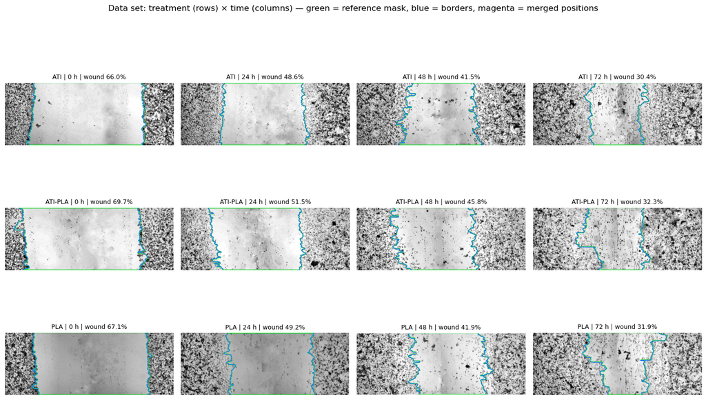

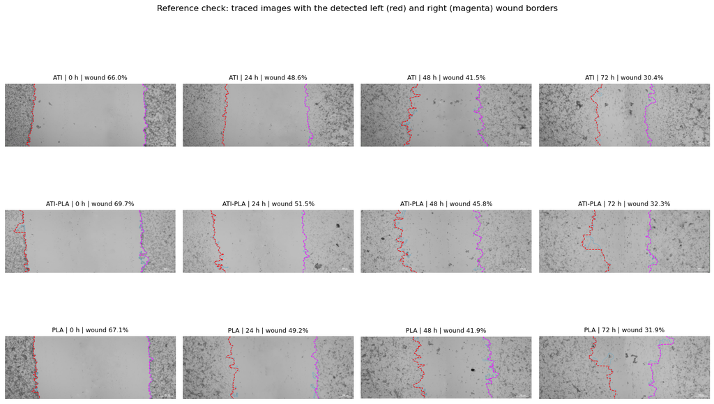

**Figure caption (English):** Extraction of the reference wound borders from the manually traced images. Each panel shows the traced image (treatments in rows, time after scratching in columns) with the automatically detected left (red) and right (magenta) borders superimposed; panel titles give the reference wound area as a percentage of the field of view.

**Referans algılama kontrol tablosu**

|  | file | kaynak | yönelim | mavi_piksel | eşik_kademesi | rgb_margin | çizgi_kaplama_pct | iki_sınır_satır_pct | çizgi_kalınlığı_px | birleşmiş_satır_pct | girdi_inpaint |
| --- | --- | --- | --- | --- | --- | --- | --- | --- | --- | --- | --- |
| 0 | 0_ati.jpeg | 0_ati.jpg | v | 4460 | 0 | 15 | 100.0 | 99.6 | 3.0 | 0.0 | False |
| 1 | 24_ati.jpeg | 24_ati.jpg | v | 4445 | 0 | 15 | 100.0 | 99.4 | 3.0 | 0.0 | False |
| 2 | 48_ati.jpeg | 48_ati.jpg | v | 7051 | 0 | 15 | 100.0 | 99.6 | 3.0 | 0.0 | False |
| 3 | 72_atı.jpeg | 72_atı.jpg | v | 4852 | 0 | 15 | 100.0 | 99.6 | 3.0 | 0.0 | False |
| 4 | 0_ap.jpeg | 0_ap.jpg | v | 7716 | 0 | 15 | 100.0 | 100.0 | 4.0 | 0.0 | False |
| 5 | 24_ap.jpeg | 24_ap.jpg | v | 6752 | 0 | 15 | 100.0 | 99.6 | 4.0 | 0.0 | False |
| 6 | 48_ap.jpeg | 48_ap.jpg | v | 8039 | 0 | 15 | 100.0 | 100.0 | 3.0 | 0.0 | False |
| 7 | 72_ap.jpeg | 72_ap.jpg | v | 6065 | 0 | 15 | 100.0 | 100.0 | 3.0 | 0.0 | False |
| 8 | 0_control.jpeg | 0_control.jpg | v | 6003 | 0 | 15 | 100.0 | 99.4 | 4.0 | 0.0 | False |
| 9 | 24_control.jpeg | 24_control.jpg | v | 8690 | 1 | 10 | 100.0 | 99.6 | 4.0 | 0.0 | False |
| 10 | 48_control.jpeg | 48_control.jpg | v | 8652 | 0 | 15 | 100.0 | 100.0 | 4.0 | 0.0 | False |
| 11 | 72_control.jpeg | 72_control.jpg | v | 6182 | 0 | 15 | 100.0 | 100.0 | 3.0 | 0.0 | False |

|  | file | drug | time_h | mask_src | area_gt_px | wound_frac_% |
| --- | --- | --- | --- | --- | --- | --- |
| 0 | 0_ati.jpeg | ati | 0.0 | mavi çizgi | 446488.13 | 65.95 |
| 1 | 24_ati.jpeg | ati | 24.0 | mavi çizgi | 331543.76 | 48.56 |
| 2 | 48_ati.jpeg | ati | 48.0 | mavi çizgi | 281749.39 | 41.46 |
| 3 | 72_atı.jpeg | ati | 72.0 | mavi çizgi | 207254.02 | 30.40 |
| 4 | 0_ap.jpeg | ap | 0.0 | mavi çizgi | 475715.21 | 69.68 |
| 5 | 24_ap.jpeg | ap | 24.0 | mavi çizgi | 351380.41 | 51.47 |
| 6 | 48_ap.jpeg | ap | 48.0 | mavi çizgi | 312429.90 | 45.80 |
| 7 | 72_ap.jpeg | ap | 72.0 | mavi çizgi | 220353.12 | 32.32 |
| 8 | 0_control.jpeg | PLA | 0.0 | mavi çizgi | 458967.02 | 67.09 |
| 9 | 24_control.jpeg | PLA | 24.0 | mavi çizgi | 333842.65 | 49.19 |
| 10 | 48_control.jpeg | PLA | 48.0 | mavi çizgi | 282362.21 | 41.86 |
| 11 | 72_control.jpeg | PLA | 72.0 | mavi çizgi | 217678.44 | 31.91 |

```python
# Referans parmak izi: kayıtlı sonuçların BU referanslarla üretilip üretilmediğini anlamak için (eski sözde-etiketli
# sonuçlar bu sayede otomatik olarak yok sayılır)
_h = hashlib.sha1()
for i in range(len(META)):
    _h.update(f"{META.loc[i, 'file']}|{MASK_SRC[i]}|{ORIENT[i]}|{MASKS[i].shape}|".encode("utf-8"))
    _h.update(np.packbits(MASKS[i].astype(bool)).tobytes())
REF_FP = _h.hexdigest()[:16]
print("Referans parmak izi:", REF_FP)
print("Maske kaynakları:", dict(pd.Series(MASK_SRC).value_counts()))
if GT_IS_PSEUDO:
    print("⚠️ Tüm maskeler sözde-etiket. Klasik yöntem kendi kendisiyle karşılaştırılacağından sıralamaya dahil edilmeyecek.")

# Birleşme eşiği (çalışma pikseli): kullanıcı verdiyse orijinal pikselden çevrilir, yoksa çizgi kalınlığının 2 katı
LIN_SCALE = [math.sqrt(a) for a in SCALE_AREA]                    # çalışma pikseli → orijinal piksel (doğrusal)
if CFG["MERGE_THR_PX"]:
    MERGE_THR_W = [CFG["MERGE_THR_PX"] / LIN_SCALE[i] for i in range(N_IMG)]
else:
    th_med = float(np.median([g["thick_work"] for g in GT_BORDERS]))
    MERGE_THR_W = [max(3.0, 2 * th_med)] * N_IMG
UNIT_LEN = "µm" if CFG["PIXEL_SIZE_UM"] else "px"
def to_len(px_work, i):
    """Çalışma pikseli uzunluğu → orijinal piksel (veya µm)."""
    v = np.asarray(px_work, float) * LIN_SCALE[i]
    return v * CFG["PIXEL_SIZE_UM"] if CFG["PIXEL_SIZE_UM"] else v

# Alanlar (orijinal piksel birimi ve varsa µm²)
META["area_gt_px"] = [MASKS[i].sum() * SCALE_AREA[i] for i in range(N_IMG)]
if CFG["PIXEL_SIZE_UM"]:
    META["area_gt_um2"] = META["area_gt_px"] * CFG["PIXEL_SIZE_UM"] ** 2
META["wound_frac_%"] = [100 * MASKS[i].mean() for i in range(N_IMG)]

fig, axes = plt.subplots(len(CFG["DRUGS"]), len(CFG["TIMES_OBS"]), figsize=(3.6 * len(CFG["TIMES_OBS"]), 3.0 * len(CFG["DRUGS"])))
axes = np.atleast_2d(axes)
for i, r in META.iterrows():
    try:
        a = axes[CFG["DRUGS"].index(str(r["drug"])), CFG["TIMES_OBS"].index(int(r["time_h"]))]
    except ValueError:
        continue
    a.imshow(overlay_rgb(IMGS[i], gt=MASKS[i])); a.set_axis_off()
    gb = GT_BORDERS[i]; yy_ = np.arange(len(gb["xL"]))
    _blue_src = MASK_SRC[i] == "mavi çizgi"               # sözde-etiket sınırları turuncu kesikli çizilir (karışmasın)
    for xs_ in (gb["xL"], gb["xR"]):
        kw = dict(color="#1f6fff", lw=0.9) if _blue_src else dict(color="orange", lw=0.9, ls="--")
        if gb["orient"] == "v":
            a.plot(xs_, yy_, **kw)
        else:
            a.plot(yy_, xs_, **kw)
    mg = np.flatnonzero(gb["merged"])[::3]
    if len(mg):
        cx = (gb["xL"][mg] + gb["xR"][mg]) / 2
        a.scatter(cx if gb["orient"] == "v" else mg, mg if gb["orient"] == "v" else cx, s=4, c="magenta", zorder=5)
    a.set_title(f"{DL(r['drug'])} | {int(r['time_h'])} h | wound {r['wound_frac_%']:.1f}%" + ("" if _blue_src else " | PSEUDO"), fontsize=9)
plt.suptitle("Data set: treatment (rows) × time (columns) — green = reference mask, blue = borders, magenta = merged positions", y=1.01)
plt.tight_layout(); savefig("00_dataset_grid"); plt.show()

# Kontrol figürü: algılanan sınırlar mavi çizgili ORİJİNAL görüntünün üzerinde (sol = kırmızı, sağ = mor)
if N_BLUE_REF:
    fig, axes = plt.subplots(len(CFG["DRUGS"]), len(CFG["TIMES_OBS"]), figsize=(3.6 * len(CFG["TIMES_OBS"]), 3.0 * len(CFG["DRUGS"])))
    axes = np.atleast_2d(axes)
    for a in axes.ravel():
        a.set_axis_off()
    for i, r in META.iterrows():
        gb = GT_BORDERS[i]
        if MASK_SRC[i] != "mavi çizgi":
            continue
        try:
            a = axes[CFG["DRUGS"].index(str(r["drug"])), CFG["TIMES_OBS"].index(int(r["time_h"]))]
        except ValueError:
            continue
        ann = imread_any(gb["annot_path"])
        ann = ann[..., :3] if ann.dtype == np.uint8 else cv2.normalize(ann[..., :3], None, 0, 255, cv2.NORM_MINMAX).astype(np.uint8)
        Hw, Ww = IMGS[i].shape
        a.imshow(cv2.cvtColor(cv2.resize(ann, (Ww, Hw), interpolation=cv2.INTER_AREA), cv2.COLOR_BGR2RGB))
        yy_ = np.arange(len(gb["xL"]))
        for xs_, c_ in ((gb["xL"], "red"), (gb["xR"], "magenta")):
            if gb["orient"] == "v":
                a.plot(xs_, yy_, color=c_, lw=0.8, ls="--")
            else:
                a.plot(yy_, xs_, color=c_, lw=0.8, ls="--")
        a.set_title(f"{DL(r['drug'])} | {int(r['time_h'])} h | wound {r['wound_frac_%']:.1f}%", fontsize=9)
    plt.suptitle("Reference check: traced images with the detected left (red) and right (magenta) wound borders", y=1.01)
    plt.tight_layout(); savefig("00b_reference_check"); plt.show()
CHECK = pd.DataFrame([dict(file=META.loc[i, "file"], kaynak=GT_BORDERS[i]["src"], yönelim=GT_BORDERS[i]["orient"],
                           mavi_piksel=GT_BORDERS[i]["n_blue"], eşik_kademesi=GT_BORDERS[i].get("blue_level", np.nan),
                           rgb_margin=GT_BORDERS[i].get("rgb_margin", np.nan),
                           çizgi_kaplama_pct=round(100 * GT_BORDERS[i].get("blue_cov", np.nan), 1),
                           iki_sınır_satır_pct=round(100 * GT_BORDERS[i].get("blue_two", np.nan), 1),
                           çizgi_kalınlığı_px=round(GT_BORDERS[i]["thick_work"] * LIN_SCALE[i], 1),
                           birleşmiş_satır_pct=round(100 * GT_BORDERS[i]["merged"].mean(), 1),
                           girdi_inpaint=META.loc[i, "input_inpainted"]) for i in range(N_IMG)])
display(Markdown("**Referans algılama kontrol tablosu**")); display(CHECK)
CHECK.to_csv(DIRS["tables"] / "gt_annotation_check.csv", index=False)
display(META[["file", "drug", "time_h", "mask_src", "area_gt_px", "wound_frac_%"]].round(2))
```

### 4.1 Çapraz doğrulama katlamaları (sızıntısız)

**Latin-kare 4-katlı tasarım:** Katlama *f*'nin test kümesi = {(ati, t<sub>f</sub>), (ap, t<sub>f+1</sub>), (PLA, t<sub>f+2</sub>)} (indeksler mod 4). Böylece:

- Her görüntü tam bir kez test edilir,
- Her test katlamasında **üç farklı ilaç** ve **üç farklı zaman** bulunur (dağılım dengeli),
- Model, test edilen ilaç-zaman kombinasyonunu eğitimde hiç görmez.

`FULL` modda Genetik Algoritma her dış katlamanın **yalnızca eğitim görüntüleri** üzerinde iç Latin-katlamalarla çalışır (iç içe / nested CV) → test görüntüsü hiperparametre seçimine hiç sızmaz.

```python
def latin_folds(indices):
    """indices içindeki görüntüleri (ilaç × zaman) Latin-kare mantığıyla katlamalara böler."""
    sub = META.loc[indices]
    drugs = [d for d in CFG["DRUGS"] if d in set(sub["drug"].astype(str))]
    times = sorted(sub["time_h"].unique())
    K = len(times)
    folds = [[] for _ in range(K)]
    for di, d in enumerate(drugs):
        for f in range(K):
            t = times[(f + di) % K]
            ids = sub[(sub["drug"].astype(str) == d) & (sub["time_h"] == t)]["idx"].tolist()
            folds[f].extend(ids)
    folds = [sorted(f) for f in folds if f]
    covered = sorted(itertools.chain(*folds))
    rest = sorted(set(indices) - set(covered))            # tasarım dışı (replika vb.) görüntüleri dağıt
    for j, i in enumerate(rest):
        folds[j % len(folds)].append(i)
    return folds

def make_outer_folds():
    allidx = META["idx"].tolist()
    if CFG["CV_SCHEME"] == "loocv":
        return [[i] for i in allidx]
    return latin_folds(allidx)

OUTER_FOLDS = make_outer_folds()
for f, te in enumerate(OUTER_FOLDS):
    print(f"Katlama {f}: test = " + ", ".join(f"{META.loc[i,'drug']}-{int(META.loc[i,'time_h'])}h" for i in te))
```

```
Katlama 0: test = ati-0h, ap-24h, PLA-48h
Katlama 1: test = ati-24h, ap-48h, PLA-72h
Katlama 2: test = ati-48h, ap-72h, PLA-0h
Katlama 3: test = ati-72h, ap-0h, PLA-24h
```

## 5. GPU üzerinde yama örnekleyici ve veri artırma

Az veriyle genelleme yapabilmek için her iterasyonda eğitim görüntülerinden **rastgele yamalar** (patch) kesilir ve **GPU'da** şu artırmalar uygulanır (şiddeti GA'nın `aug` geni belirler):

- Geometrik: 8 dihedral dönüşüm (yatay/dikey çevirme, 90° döndürme), rastgele ölçek (±%25).
- Fotometrik: parlaklık, kontrast, gama, Gauss gürültüsü, Gauss bulanıklığı (faz-kontrast mikroskop varyasyonlarını taklit eder).
- **Sınır-odaklı örnekleme:** Yamaların bir kısmı yara–hücre sınırı etrafından seçilir; zor ve bilgi yoğun bölgeler daha sık görülür.

Tüm işlemler GPU'da olduğu için CPU veri hazırlamayı beklemez; GPU sürekli hesaplama yapar.

```python
IMNET_MEAN = torch.tensor([0.485, 0.456, 0.406]).view(1, 3, 1, 1)
IMNET_STD = torch.tensor([0.229, 0.224, 0.225]).view(1, 3, 1, 1)

def to_net_input(x1):
    """(B,1,H,W) [0,1] gri → (B,3,H,W) ImageNet normalize."""
    x3 = x1.expand(-1, 3, -1, -1)
    return (x3 - IMNET_MEAN.to(x1.device)) / IMNET_STD.to(x1.device)

def boundary_of(mask, r=3):
    k = cv2.getStructuringElement(cv2.MORPH_ELLIPSE, (2 * r + 1, 2 * r + 1))
    m = mask.astype(np.uint8)
    return (cv2.dilate(m, k) - cv2.erode(m, k)) > 0

def _gauss_kernel(sigma, device):
    r = max(1, int(math.ceil(2.5 * sigma)))
    x = torch.arange(-r, r + 1, device=device, dtype=torch.float32)
    k = torch.exp(-x ** 2 / (2 * sigma ** 2)); k = k / k.sum()
    return k

class GPUPatchSampler:
    """idxs: etiketli eğitim görüntüleri; extra: [(görüntü, sözde-maske, güven ağırlığı), ...] (yarı-denetimli öz-eğitim)."""
    def __init__(self, idxs, patch, device=DEVICE, seed=0, extra=None):
        self.dev, self.P = device, int(patch)
        self.rng = np.random.default_rng(seed)
        self.tg = torch.Generator(device=device)          # örnekleyiciye özel üreteç: aynı anda çalışan eğitimler
        self.tg.manual_seed(int(seed) + 12345)            # birbirinin rastgeleliğini değiştirmez (tekrarlanabilirlik)
        self.imgs, self.msks, self.wts, self.bnd = [], [], [], []
        items = [(IMGS[i], MASKS[i].astype(np.float32), None) for i in idxs] + list(extra or [])
        for im, m, w in items:
            w = np.ones_like(m, np.float32) if w is None else w.astype(np.float32)
            H, W = im.shape
            ph, pw = max(0, self.P - H), max(0, self.P - W)
            if ph or pw:                                   # görüntü yamadan küçükse yansıtarak doldur
                im, m, w = [np.pad(a, ((0, ph), (0, pw)), mode="reflect") for a in (im, m, w)]
            self.imgs.append(torch.from_numpy(np.ascontiguousarray(im)).to(device))
            self.msks.append(torch.from_numpy(np.ascontiguousarray(m)).to(device))
            self.wts.append(torch.from_numpy(np.ascontiguousarray(w)).to(device))
            b = np.argwhere(boundary_of(m > 0.5, r=max(2, self.P // 32)))
            self.bnd.append(b if len(b) else np.argwhere(np.ones_like(m)))

    @torch.no_grad()
    def sample(self, B, aug=0.5, boundary_frac=0.5, return_weight=False):
        P, rng, dev = self.P, self.rng, self.dev
        xs, ys, ws = [], [], []
        for _ in range(B):
            k = int(rng.integers(len(self.imgs)))
            im, m, wt = self.imgs[k], self.msks[k], self.wts[k]
            H, W = im.shape
            s = int(round(P * 2 ** rng.uniform(-0.35 * aug, 0.35 * aug)))
            s = int(np.clip(s, 16, min(H, W)))
            if rng.random() < boundary_frac:
                cy, cx = self.bnd[k][int(rng.integers(len(self.bnd[k])))]
            else:
                cy, cx = int(rng.integers(H)), int(rng.integers(W))
            y0 = int(np.clip(cy - s // 2 + rng.integers(-s // 4, s // 4 + 1), 0, H - s))
            x0 = int(np.clip(cx - s // 2 + rng.integers(-s // 4, s // 4 + 1), 0, W - s))
            xi = im[y0:y0 + s, x0:x0 + s][None, None]; yi = m[y0:y0 + s, x0:x0 + s][None, None]
            wi = wt[y0:y0 + s, x0:x0 + s][None, None]
            if s != P:
                xi = F.interpolate(xi, size=(P, P), mode="bilinear", align_corners=False)
                yi = F.interpolate(yi, size=(P, P), mode="bilinear", align_corners=False)
                wi = F.interpolate(wi, size=(P, P), mode="nearest")
            kk = int(rng.integers(4))
            if kk:
                xi, yi, wi = torch.rot90(xi, kk, (2, 3)), torch.rot90(yi, kk, (2, 3)), torch.rot90(wi, kk, (2, 3))
            if rng.random() < 0.5:
                xi, yi, wi = xi.flip(3), yi.flip(3), wi.flip(3)
            xs.append(xi); ys.append(yi); ws.append(wi)
        x = torch.cat(xs); y = torch.cat(ys); wb = torch.cat(ws)
        if aug > 0:                                        # fotometrik artırmalar (toplu, GPU'da)
            Bn = x.shape[0]
            tg = self.tg
            b = (torch.rand(Bn, 1, 1, 1, device=dev, generator=tg) - 0.5) * 0.3 * aug
            c = torch.exp((torch.rand(Bn, 1, 1, 1, device=dev, generator=tg) - 0.5) * 0.6 * aug)
            g = torch.exp((torch.rand(Bn, 1, 1, 1, device=dev, generator=tg) - 0.5) * 0.6 * aug)
            x = ((x - 0.5) * c + 0.5 + b).clamp(1e-4, 1) ** g
            if rng.random() < 0.4 * aug:
                kern = _gauss_kernel(float(rng.uniform(0.5, 1.4)), dev)
                pad = len(kern) // 2
                x = F.conv2d(F.pad(x, (pad, pad, 0, 0), mode="reflect"), kern.view(1, 1, 1, -1))
                x = F.conv2d(F.pad(x, (0, 0, pad, pad), mode="reflect"), kern.view(1, 1, -1, 1))
            x = x + torch.randn(x.shape, device=dev, dtype=x.dtype, generator=tg) * (torch.rand(Bn, 1, 1, 1, device=dev, generator=tg) * 0.04 * aug)
            x = x.clamp(0, 1)
        return (x, y, wb) if return_weight else (x, y)
```

## 6. Kayıp fonksiyonları ve değerlendirme metrikleri

**Kayıp:** `L = (1 − w)·Focal/BCE + w·SoftDice`. Ağırlık `w` ve focal parametresi `γ` (γ=0 → saf BCE) **genetik algoritma tarafından** seçilir.

**Metrikler (yara = pozitif sınıf):**

| Metrik | Formül | Yorum |
| --- | --- | --- |
| Dice (= F1, pozitif sınıf) | 2TP / (2TP+FP+FN) | Bölütleme örtüşmesi (ana metrik) |
| IoU (Jaccard) | TP / (TP+FP+FN) | Daha katı örtüşme |
| Precision | TP / (TP+FP) | Tahmin edilen yaranın ne kadarı gerçek yara |
| Recall (Duyarlılık) | TP / (TP+FN) | Gerçek yaranın ne kadarı bulundu |
| Specificity | TN / (TN+FP) | Hücre bölgesini doğru tanıma |
| Accuracy | (TP+TN)/N | Sınıf dengesizliğinde şişebilir, tek başına yorumlanmamalı |
| Balanced Accuracy | (Recall+Specificity)/2 | Dengesizliğe dayanıklı |
| F1-macro | (F1<sub>yara</sub> + F1<sub>hücre</sub>)/2 | İki sınıfın ortalaması |
| MCC | (TP·TN−FP·FN)/√(...) | Dengesizliğe en dayanıklı tek sayı |
| Cohen κ | (p<sub>o</sub>−p<sub>e</sub>)/(1−p<sub>e</sub>) | Şans-düzeltmeli uyum |
| HD95 (piksel) | sınır mesafelerinin 95. yüzdeliği | Kontur doğruluğu |
| **Alan hatası (%)** | (A<sub>tahmin</sub> − A<sub>gerçek</sub>)/A<sub>gerçek</sub>·100 | Biyolojik olarak en kritik çıktı (yara kapanma %'si buna dayanır); işaretli ve mutlak hâli raporlanır |
| **ROC–AUC** | eşikten bağımsız; TPR–FPR eğrisinin altındaki alan | Olasılık haritasının ayırt edicilik gücü |
| **PR–AP** | ortalama kesinlik (precision–recall eğrisi) | Sınıf dengesizliğinde ROC'tan daha bilgilendirici |
| **Sınır konum hatası (BorderMAE)** | her satırda \|x̂<sub>sol</sub>−x<sub>sol</sub>\| ve \|x̂<sub>sağ</sub>−x<sub>sağ</sub>\| ortalaması | Mavi çizgiyle çizilen **iki sınırın** ne kadar doğru bulunduğu (px veya µm) |
| **Genişlik hatası (WidthMAE, WidthErr %)** | yara genişliği profili w(y) = x<sub>sağ</sub> − x<sub>sol</sub> | İki sınır arası mesafenin (kapanmanın) doğruluğu |
| **Birleşme uyumu (MergeAgree)** | satırların "birleşmiş (w ≤ eşik) / açık" sınıflamasındaki uyum | **İki sınırın birleştiği konumların** doğru tespiti |

> Not: İkili piksel sınıflandırmada **F1 skoru matematiksel olarak Dice katsayısına eşittir**; tabloda ikisi de gösterilir.

```python
def seg_loss(logits, target, dice_w=0.5, gamma=0.0, weight=None):
    """(1-w)·Focal/BCE + w·SoftDice. `weight` (0/1 güven maskesi) verilirse yalnız güvenilir pikseller kullanılır (SSL)."""
    logits = logits.float(); target = target.float()
    bce = F.binary_cross_entropy_with_logits(logits, target, reduction="none")
    if gamma > 0:
        p = torch.sigmoid(logits)
        pt = p * target + (1 - p) * (1 - target)
        bce = bce * (1 - pt).clamp_min(0).pow(gamma)
    p = torch.sigmoid(logits).flatten(1); t = target.flatten(1)
    if weight is not None:
        w = weight.float()
        l_bce = (bce * w).sum() / (w.sum() + 1e-6)
        wf = w.flatten(1); p = p * wf; t = t * wf
    else:
        l_bce = bce.mean()
    dice = 1 - (2 * (p * t).sum(1) + 1) / (p.sum(1) + t.sum(1) + 1)
    return (1 - dice_w) * l_bce + dice_w * dice.mean()

def hd95(a, b):
    if a.sum() == 0 or b.sum() == 0:
        return np.nan
    ba = boundary_of(a, 1) & a; bb = boundary_of(b, 1) & b
    if ba.sum() == 0 or bb.sum() == 0:
        return np.nan
    da = ndi.distance_transform_edt(~bb)[ba]; db = ndi.distance_transform_edt(~ba)[bb]
    return float(np.percentile(np.hstack([da, db]), 95))

def seg_metrics(pred, gt, area_scale=1.0):
    pred = np.asarray(pred, bool); gt = np.asarray(gt, bool)
    tp = float((pred & gt).sum()); fp = float((pred & ~gt).sum())
    fn = float((~pred & gt).sum()); tn = float((~pred & ~gt).sum()); n = tp + fp + fn + tn
    div = lambda a, b, empty=1.0: a / b if b > 0 else empty
    dice = div(2 * tp, 2 * tp + fp + fn); iou = div(tp, tp + fp + fn)
    prec = div(tp, tp + fp, 0.0 if tp + fn > 0 else 1.0); rec = div(tp, tp + fn)
    spec = div(tn, tn + fp); acc = (tp + tn) / n
    f1_cell = div(2 * tn, 2 * tn + fp + fn)
    den = math.sqrt((tp + fp) * (tp + fn) * (tn + fp) * (tn + fn))
    mcc = (tp * tn - fp * fn) / den if den > 0 else 0.0
    pe = ((tp + fp) * (tp + fn) + (fn + tn) * (fp + tn)) / (n * n)
    kappa = (acc - pe) / (1 - pe) if pe < 1 else 1.0
    a_gt, a_pr = gt.sum() * area_scale, pred.sum() * area_scale
    aerr = 100 * (a_pr - a_gt) / a_gt if a_gt > 0 else (0.0 if a_pr == 0 else 100.0)
    return OrderedDict(Dice=dice, IoU=iou, F1=dice, F1_macro=(dice + f1_cell) / 2, Precision=prec,
                       Recall=rec, Specificity=spec, Accuracy=acc, BalancedAcc=(rec + spec) / 2,
                       MCC=mcc, Kappa=kappa, HD95_px=hd95(pred, gt) * math.sqrt(area_scale),
                       Area_GT=a_gt, Area_Pred=a_pr, AreaErr_pct=aerr, AbsAreaErr_pct=abs(aerr))

def border_metrics(pred, i):
    """İki sınırın konum hatası, yara genişliği ve birleşme (temas) uyumu — referans: mavi çizgi sınırları."""
    gb = GT_BORDERS[i]; o = gb["orient"]
    gL, gR = gb["xL"], gb["xR"]
    pL, pR = mask_borders(pred, o)
    if np.isnan(pL).all():                                   # tahminde hiç yara yok → her yerde birleşmiş
        pL = pR = (gL + gR) / 2
    else:
        pL, pR, _ = fill_tracks(pL, pR)
    n = min(len(gL), len(pL)); gL, gR, pL, pR = gL[:n], gR[:n], pL[:n], pR[:n]
    eL, eR = np.abs(pL - gL), np.abs(pR - gR)
    wG, wP = np.maximum(gR - gL, 0), np.maximum(pR - pL, 0)
    thr = MERGE_THR_W[i]
    mG, mP = wG <= thr, wP <= thr
    mwg = wG.mean()
    return OrderedDict(BorderMAE=float(to_len(np.mean((eL + eR) / 2), i)),
                       Width_GT=float(to_len(mwg, i)), Width_Pred=float(to_len(wP.mean(), i)),
                       WidthMAE=float(to_len(np.mean(np.abs(wP - wG)), i)),
                       WidthErr_pct=float(100 * (wP.mean() - mwg) / mwg) if mwg > 0 else (0.0 if wP.mean() == 0 else 100.0),
                       Merge_GT_pct=float(100 * mG.mean()), Merge_Pred_pct=float(100 * mP.mean()),
                       MergeAgree=float(np.mean(mG == mP)))

from sklearn.metrics import roc_curve, auc as sk_auc, precision_recall_curve, average_precision_score, roc_auc_score

def prob_metrics(prob, gt):
    y = gt.ravel().astype(np.uint8); p = np.asarray(prob, np.float32).ravel()
    if y.min() == y.max():
        return OrderedDict(AUC=np.nan, AP=np.nan)
    return OrderedDict(AUC=float(roc_auc_score(y, p)), AP=float(average_precision_score(y, p)))

def pixel_roc_pr(probs, idxs=None, stride=2):
    """Tüm (katlama-dışı) test görüntülerinin pikselleri birleştirilerek ROC ve PR eğrisi."""
    idxs = idxs if idxs is not None else sorted(probs)
    y = np.concatenate([MASKS[i][::stride, ::stride].ravel() for i in idxs]).astype(np.uint8)
    p = np.concatenate([np.asarray(probs[i], np.float32)[::stride, ::stride].ravel() for i in idxs])
    fpr, tpr, _ = roc_curve(y, p); prec, rec, _ = precision_recall_curve(y, p)
    return dict(fpr=fpr, tpr=tpr, auc=float(sk_auc(fpr, tpr)), prec=prec, rec=rec,
                ap=float(average_precision_score(y, p)), prevalence=float(y.mean()))

METRIC_COLS = ["Dice", "IoU", "F1", "F1_macro", "Precision", "Recall", "Specificity", "Accuracy",
               "BalancedAcc", "MCC", "Kappa", "AUC", "AP", "HD95_px", "AreaErr_pct", "AbsAreaErr_pct",
               "BorderMAE", "WidthMAE", "WidthErr_pct", "MergeAgree"]

def postprocess(prob, thr=0.5, mode="fixed"):
    """Olasılık → maske. mode='otsu': eşik olasılık haritasından Otsu ile seçilir (Rosoff vd. 2022)."""
    if mode == "otsu":
        try:
            thr = float(np.clip(filters.threshold_otsu(prob), 0.05, 0.95)) if float(np.ptp(prob)) > 1e-3 else 0.5
        except Exception:
            thr = 0.5
    return clean_mask(prob >= thr, min_frac=0.002, hole_frac=0.002)

def binarize(prob, hp):
    hp = hp if isinstance(hp, dict) else {}
    return postprocess(prob, hp.get("thr", 0.5), hp.get("thr_mode", "fixed"))

def full_metrics(prob, i, hp):
    """Görüntü i için tüm metrikler: piksel, olasılık (AUC/AP), alan ve sınır/genişlik/birleşme."""
    pred = binarize(prob, hp)
    return OrderedDict(**seg_metrics(pred, MASKS[i], SCALE_AREA[i]), **prob_metrics(prob, MASKS[i]), **border_metrics(pred, i))
```

## 7. Model hayvanat bahçesi (Model Zoo)

Tüm modeller **aynı eğitim protokolü, aynı veri artırma, aynı kayıp ailesi ve aynı GA bütçesiyle** eğitilir; böylece karşılaştırma adildir.

| Aile | Model | Temel fikir | Kaynak |
| --- | --- | --- | --- |
| **CNN** | U-Net (ResNet34) | Kodlayıcı–çözücü + atlama bağlantıları | Ronneberger vd., 2015 |
| CNN | U-Net++ | İç içe yoğun atlama yolları | Zhou vd., 2018 |
| CNN | Attention U-Net | Atlama bağlantılarında dikkat kapıları (attention gates) | Oktay vd., 2018 |
| CNN | U-Net 3+ | Tam-ölçekli (full-scale) atlama bağlantıları | Huang vd., 2020 |
| CNN | **DeepLabv3+** (ResNet50) | **Atrous (genişletilmiş) konvolüsyon** + ASPP + çözücü | Chen vd., 2018 |
| CNN | FPN | Özellik piramidi | Lin vd., 2017 |
| CNN | MA-Net | Çok ölçekli dikkat (PAB + MFAB) | Fan vd., 2020 |
| **Vision Transformer** | SegFormer (MiT-B2) | Hiyerarşik Mix-Transformer + hafif MLP çözücü | Xie vd., 2021 |
| Vision Transformer | TransUNet | CNN kodlayıcı + Transformer darboğaz + U-Net çözücü | Chen vd., 2021 |
| **SAM (Transformer)** | SAM ViT-B | SA-1B ile eğitilmiş temel model; görüntü kodlayıcı dondurulur, maske çözücü ince ayarlanır | Kirillov vd., 2023 |
| SAM | **MobileSAM** (TinyViT) | SAM'in damıtılmış (distilled) hafif sürümü | Zhang vd., 2023 |
| **Vision GNN** | ViG-Seg (piramit ViG) | Görüntü yamaları = graf düğümleri; dinamik k-NN grafı + max-relative graf konvolüsyonu | Han vd., 2022 |
| **INR** | INR-Seg (SIREN) | Sürekli koordinat fonksiyonu f(x, y ∣ görüntü özellikleri) → yara olasılığı; çözünürlükten bağımsız | Sitzmann vd., 2020; Tancik vd., 2020 |
| **MLP-Mixer** | MLP-Mixer-Seg | Yalnızca MLP: belirteç-karıştırma + kanal-karıştırma | Tolstikhin vd., 2021 |
| *Önerim* | Klasik (Varyans + Otsu) | Literatürdeki standart araçların (TScratch, ImageJ) temeli; **referans taban çizgisi** | Gebäck vd., 2009; Suarez-Arnedo vd., 2020 |
| *Önerim* | Random Forest (ilastik-tipi + MSER) | ilastik "Pixel Classification" öznitelik kümesine yakın çok ölçekli öznitelikler (Gauss, LoG, gradyan, DoG, yapı tensörü ve Hessian özdeğerleri) + yerel entropi + **MSER uç-bölge yoğunluğu**; 100 ağaç… | Rosoff vd., 2022; Plotczyk vd., 2023; Ramesh vd., 2017 |
| *Önerim (opsiyonel)* | SAM ViT-B (alan-özel ağırlık) | `CFG["SAM_CUSTOM_CKPT"]` verilirse: mikroskopiye ince ayarlı SAM (ör. μSAM `vit_b_lm`) veya MedSAM ağırlığıyla aynı çözücü ince ayarı | Archit vd., 2025; Ma vd., 2024 |
| *Önerim* | Ensemble (Top-3) | GA doğrulama başarısına göre seçilen en iyi 3 modelin olasılık ortalaması | — |

**Neden ön-eğitimli ağırlıklar?** 12 görüntüyle sıfırdan eğitilen derin ağlar ezberler. ImageNet (CNN/SegFormer) ve SA-1B (SAM) ön-eğitimi düşük seviye doku/kenar bilgisini taşır. ViG, MLP-Mixer'in token karıştırma katmanları ve INR başlığı sıfırdan eğitilir; bu ailelerin **endüktif yanlılık** (inductive bias) eksikliğinin küçük veride nasıl sonuç verdiği, makalede ilginç bir tartışma noktasıdır.

```python
import segmentation_models_pytorch as smp
import timm

_ENC_CACHE = {}          # ön-eğitimli kodlayıcı ağırlıklarını bellekte tut (GA'da her bireyde yeniden indirme olmasın)
PRETRAIN_STATUS = {}

def _cache_key(name, depth):
    return f"{name}|{depth}"

def build_encoder(name="resnet34", depth=5, pretrained=True):
    key = _cache_key(name, depth)
    enc = smp.encoders.get_encoder(name, in_channels=3, depth=depth, weights=None)
    if pretrained:
        if key not in _ENC_CACHE:
            try:
                e2 = smp.encoders.get_encoder(name, in_channels=3, depth=depth, weights="imagenet")
                _ENC_CACHE[key] = {k: v.detach().cpu().clone() for k, v in e2.state_dict().items()}
                PRETRAIN_STATUS[name] = "imagenet"
            except Exception as ex:
                print(f"⚠️ {name}: ImageNet ağırlıkları indirilemedi ({type(ex).__name__}). Rastgele başlatma kullanılacak.")
                _ENC_CACHE[key] = None
                PRETRAIN_STATUS[name] = "rastgele"
        if _ENC_CACHE[key] is not None:
            enc.load_state_dict(_ENC_CACHE[key])
    return enc

def smp_model(arch, encoder, **kw):
    """smp mimarisini kur, ön-eğitimli kodlayıcıyı önbellekten yükle."""
    model = getattr(smp, arch)(encoder_name=encoder, encoder_weights=None, in_channels=3, classes=1, **kw)
    depth = kw.get("encoder_depth", 5)
    key = _cache_key(encoder, depth)
    if key not in _ENC_CACHE:
        try:
            m2 = getattr(smp, arch)(encoder_name=encoder, encoder_weights="imagenet", in_channels=3, classes=1, **kw)
            _ENC_CACHE[key] = {k: v.detach().cpu().clone() for k, v in m2.encoder.state_dict().items()}
            PRETRAIN_STATUS[encoder] = "imagenet"
            del m2
        except Exception as ex:
            print(f"⚠️ {encoder}: ImageNet ağırlıkları indirilemedi ({type(ex).__name__}). Rastgele başlatma kullanılacak.")
            _ENC_CACHE[key] = None
            PRETRAIN_STATUS[encoder] = "rastgele"
    if _ENC_CACHE[key] is not None:
        model.encoder.load_state_dict(_ENC_CACHE[key])
    return model

class ConvBNAct(nn.Sequential):
    def __init__(self, cin, cout, k=3, s=1, act=nn.ReLU):
        super().__init__(nn.Conv2d(cin, cout, k, s, k // 2, bias=False), nn.BatchNorm2d(cout), act(inplace=True) if act is nn.ReLU else act())

def up_to(x, ref):
    return F.interpolate(x, size=ref.shape[-2:], mode="bilinear", align_corners=False)

# ------------------------------------------------------------------ Attention U-Net (Oktay vd., 2018)
class AttentionGate(nn.Module):
    def __init__(self, g_ch, x_ch, inter):
        super().__init__()
        self.wg = nn.Sequential(nn.Conv2d(g_ch, inter, 1, bias=False), nn.BatchNorm2d(inter))
        self.wx = nn.Sequential(nn.Conv2d(x_ch, inter, 1, bias=False), nn.BatchNorm2d(inter))
        self.psi = nn.Sequential(nn.Conv2d(inter, 1, 1), nn.BatchNorm2d(1), nn.Sigmoid())
    def forward(self, g, x):
        return x * self.psi(F.relu(self.wg(g) + self.wx(x), inplace=True))

class AttUNet(nn.Module):
    def __init__(self, encoder="resnet34", dec=(256, 128, 64, 32, 16)):
        super().__init__()
        self.enc = build_encoder(encoder, 5)
        ch = self.enc.out_channels
        skips = [ch[4], ch[3], ch[2], ch[1]]
        cin = ch[5]
        self.reduce, self.gates, self.blocks = nn.ModuleList(), nn.ModuleList(), nn.ModuleList()
        for j, sc in enumerate(skips):
            self.reduce.append(ConvBNAct(cin, dec[j], 1))
            self.gates.append(AttentionGate(dec[j], sc, max(sc // 2, 8)))
            self.blocks.append(nn.Sequential(ConvBNAct(dec[j] + sc, dec[j]), ConvBNAct(dec[j], dec[j])))
            cin = dec[j]
        self.final = nn.Sequential(ConvBNAct(cin, dec[4]), nn.Conv2d(dec[4], 1, 1))
    def forward(self, x):
        f = self.enc(x)
        d = f[5]
        for j, s in enumerate([f[4], f[3], f[2], f[1]]):
            d = self.reduce[j](up_to(d, s))
            d = self.blocks[j](torch.cat([d, self.gates[j](d, s)], 1))
        return self.final(up_to(d, x))

# ------------------------------------------------------------------ U-Net 3+ (Huang vd., 2020)
class UNet3Plus(nn.Module):
    def __init__(self, encoder="resnet34", cat_ch=64):
        super().__init__()
        self.enc = build_encoder(encoder, 5)
        ch = self.enc.out_channels            # e1..e5 = ch[1..5]
        up_ch = cat_ch * 5
        self.br = nn.ModuleDict(); self.fuse = nn.ModuleDict()
        for i in [4, 3, 2, 1]:
            for j in range(1, 6):
                cin = ch[j] if (j <= i or j == 5) else up_ch
                self.br[f"{i}_{j}"] = ConvBNAct(cin, cat_ch)
            self.fuse[str(i)] = ConvBNAct(up_ch, up_ch)
        self.head = nn.Conv2d(up_ch, 1, 3, padding=1)
    def forward(self, x):
        f = self.enc(x)
        e = {j: f[j] for j in range(1, 6)}
        d = {5: e[5]}
        for i in [4, 3, 2, 1]:
            size = e[i].shape[-2:]
            parts = []
            for j in range(1, 6):
                src = e[j] if (j <= i or j == 5) else d[j]
                if src.shape[-2] > size[0]:
                    src = F.adaptive_max_pool2d(src, size)
                elif src.shape[-2] < size[0]:
                    src = F.interpolate(src, size=size, mode="bilinear", align_corners=False)
                parts.append(self.br[f"{i}_{j}"](src))
            d[i] = self.fuse[str(i)](torch.cat(parts, 1))
        return up_to(self.head(d[1]), x)

# ------------------------------------------------------------------ TransUNet (Chen vd., 2021)
class TransUNet(nn.Module):
    def __init__(self, encoder="resnet34", d_model=384, depth=6, heads=6, dec=(256, 128, 64, 32)):
        super().__init__()
        self.enc = build_encoder(encoder, 4)                 # 1/16'ya kadar CNN (hibrit ViT)
        ch = self.enc.out_channels
        self.proj = nn.Conv2d(ch[4], d_model, 1)
        self.pos = nn.Parameter(torch.zeros(1, d_model, 16, 16)); nn.init.trunc_normal_(self.pos, std=0.02)
        layer = nn.TransformerEncoderLayer(d_model, heads, 4 * d_model, dropout=0.1, activation="gelu",
                                           batch_first=True, norm_first=True)
        self.tr = nn.TransformerEncoder(layer, depth, enable_nested_tensor=False)
        self.norm = nn.LayerNorm(d_model)
        self.mid = ConvBNAct(d_model, dec[0])
        self.blocks = nn.ModuleList()
        cin = dec[0]
        for j, sc in enumerate([ch[3], ch[2], ch[1]]):
            self.blocks.append(nn.Sequential(ConvBNAct(cin + sc, dec[j + 1]), ConvBNAct(dec[j + 1], dec[j + 1])))
            cin = dec[j + 1]
        self.final = nn.Sequential(ConvBNAct(cin, 16), nn.Conv2d(16, 1, 1))
    def forward(self, x):
        f = self.enc(x)
        z = self.proj(f[4]); B, C, h, w = z.shape
        z = z + F.interpolate(self.pos, size=(h, w), mode="bilinear", align_corners=False)
        t = self.norm(self.tr(z.flatten(2).transpose(1, 2)))
        d = self.mid(t.transpose(1, 2).reshape(B, C, h, w))
        for j, s in enumerate([f[3], f[2], f[1]]):
            d = self.blocks[j](torch.cat([up_to(d, s), s], 1))
        return self.final(up_to(d, x))
```

```python
# ------------------------------------------------------------------ Vision GNN (Han vd., 2022)
class MRGraphConv(nn.Module):
    """Max-Relative graf konvolüsyonu: h_i = MLP([x_i, max_j (x_j - x_i)])."""
    def __init__(self, cin, cout):
        super().__init__()
        self.nn = nn.Sequential(nn.Conv2d(2 * cin, cout, 1, groups=4, bias=False), nn.BatchNorm2d(cout), nn.GELU())
    def forward(self, xq, xk, idx):
        B, C, N = xq.shape
        k = idx.shape[-1]
        xkT = xk.transpose(1, 2)                                              # (B,M,C)
        nb = torch.gather(xkT, 1, idx.reshape(B, N * k, 1).expand(-1, -1, C))  # (B,N*k,C)
        nb = nb.reshape(B, N, k, C).permute(0, 3, 1, 2)                        # (B,C,N,k)
        rel = (nb - xq.unsqueeze(-1)).amax(-1)                                 # (B,C,N)
        return self.nn(torch.cat([xq, rel], 1).unsqueeze(-1)).squeeze(-1)

class Grapher(nn.Module):
    def __init__(self, C, k=9, dilation=1, reduce=1):
        super().__init__()
        self.k, self.d, self.r = k, dilation, reduce
        self.cpe = nn.Conv2d(C, C, 3, padding=1, groups=C)                    # konumsal kodlama
        self.fc1 = nn.Sequential(nn.Conv2d(C, C, 1, bias=False), nn.BatchNorm2d(C))
        self.gc = MRGraphConv(C, 2 * C)
        self.fc2 = nn.Sequential(nn.Conv2d(2 * C, C, 1, bias=False), nn.BatchNorm2d(C))
    def forward(self, x):
        x = x + self.cpe(x)
        y = self.fc1(x); B, C, H, W = y.shape
        q = y.flatten(2)
        kv = F.avg_pool2d(y, self.r) if self.r > 1 and min(H, W) >= 2 * self.r else y
        kf = kv.flatten(2)
        with torch.no_grad():                                                  # dinamik k-NN grafı (kosinüs benzerliği)
            qn = F.normalize(q.float(), dim=1); kn = F.normalize(kf.float(), dim=1)
            sim = torch.bmm(qn.transpose(1, 2), kn)
            kk = min(self.k * self.d, kf.shape[-1])
            idx = sim.topk(kk, dim=-1).indices[:, :, ::self.d]
        out = self.gc(q, kf, idx).reshape(B, 2 * C, H, W)
        return x + self.fc2(out)

class FFN(nn.Module):
    def __init__(self, C, e=4):
        super().__init__()
        self.f = nn.Sequential(nn.Conv2d(C, C * e, 1, bias=False), nn.BatchNorm2d(C * e), nn.GELU(),
                               nn.Conv2d(C * e, C, 1, bias=False), nn.BatchNorm2d(C))
    def forward(self, x):
        return x + self.f(x)

class ViGSeg(nn.Module):
    def __init__(self, dims=(48, 96, 192, 384), depths=(2, 2, 4, 2), k=9, reduce=(4, 2, 1, 1), dec=64):
        super().__init__()
        self.stem1 = ConvBNAct(3, dims[0] // 2, 3, 2, nn.GELU)                  # 1/2
        self.stem2 = ConvBNAct(dims[0] // 2, dims[0], 3, 2, nn.GELU)            # 1/4
        self.stages, self.downs = nn.ModuleList(), nn.ModuleList()
        bi = 0
        for s, (C, D) in enumerate(zip(dims, depths)):
            blocks = []
            for _ in range(D):
                blocks += [Grapher(C, k=k, dilation=min(bi // 4 + 1, 3), reduce=reduce[s]), FFN(C)]
                bi += 1
            self.stages.append(nn.Sequential(*blocks))
            if s < len(dims) - 1:
                self.downs.append(ConvBNAct(C, dims[s + 1], 3, 2, nn.GELU))
        self.lat = nn.ModuleList([nn.Conv2d(C, dec, 1) for C in dims])
        self.fuse = nn.Sequential(ConvBNAct(dec * 4, dec), ConvBNAct(dec, dec))
        self.detail = nn.Sequential(ConvBNAct(dec + dims[0] // 2, 32), nn.Conv2d(32, 1, 1))
    def forward(self, x):
        s1 = self.stem1(x); h = self.stem2(s1)
        feats = []
        for s, st in enumerate(self.stages):
            h = st(h); feats.append(h)
            if s < len(self.downs):
                h = self.downs[s](h)
        p = [self.lat[i](f) for i, f in enumerate(feats)]
        for i in range(3, 0, -1):                                               # FPN yukarıdan-aşağı
            p[i - 1] = p[i - 1] + up_to(p[i], p[i - 1])
        y = self.fuse(torch.cat([up_to(q, p[0]) for q in p], 1))
        y = self.detail(torch.cat([up_to(y, s1), s1], 1))
        return up_to(y, x)

# ------------------------------------------------------------------ INR (SIREN) segmentasyon başlığı
class SineLayer(nn.Module):
    def __init__(self, i, o, w0=30.0, first=False):
        super().__init__()
        self.w0, self.l = w0, nn.Linear(i, o)
        with torch.no_grad():
            b = 1 / i if first else math.sqrt(6 / i) / w0
            self.l.weight.uniform_(-b, b)
    def forward(self, x):
        return torch.sin(self.w0 * self.l(x))

class INRSeg(nn.Module):
    """Örtük sinir temsili: her (x, y) sorgu koordinatı için çok ölçekli CNN özelliği + Fourier konum
    kodlaması → SIREN MLP → yara logiti. Sürekli ve çözünürlükten bağımsız maske üretir."""
    is_inr = True
    def __init__(self, encoder="resnet34", feat=48, hidden=256, layers=4, n_freq=8, w0=30.0):
        super().__init__()
        self.enc = build_encoder(encoder, 5)
        ch = self.enc.out_channels
        self.lat = nn.ModuleList([nn.Conv2d(ch[j], feat, 1) for j in range(1, 6)])
        self.n_freq = n_freq
        in_dim = 5 * feat + 2 + 4 * n_freq
        self.ln = nn.LayerNorm(5 * feat)
        mlp = [SineLayer(in_dim, hidden, w0, first=True)] + [SineLayer(hidden, hidden, w0) for _ in range(layers - 1)]
        self.mlp = nn.Sequential(*mlp)
        self.out = nn.Linear(hidden, 1)
        with torch.no_grad():
            b = math.sqrt(6 / hidden) / w0; self.out.weight.uniform_(-b, b)
        self.register_buffer("freqs", (2.0 ** torch.arange(n_freq)) * math.pi, persistent=False)

    def features(self, x):
        f = self.enc(x)
        return [self.lat[j - 1](f[j]) for j in range(1, 6)]

    def query(self, feats, coords):                     # coords: (B,Q,2) ∈ [-1,1], (x,y) sırası
        g = coords.unsqueeze(2)
        s = torch.cat([F.grid_sample(p.float(), g.float(), mode="bilinear", align_corners=False) for p in feats], 1)
        s = s.squeeze(-1).transpose(1, 2)                                       # (B,Q,5f)
        with torch.autocast(device_type=DEVICE.type, enabled=False):
            pe = coords.float().unsqueeze(-1) * self.freqs                      # (B,Q,2,L)
            pe = torch.cat([pe.sin(), pe.cos()], -1).flatten(2)
            h = torch.cat([self.ln(s.float()), coords.float(), pe], -1)
            return self.out(self.mlp(h)).transpose(1, 2)                        # (B,1,Q)
```

```python
    def forward_points(self, x, coords):
        return self.query(self.features(x), coords)

    def forward(self, x, chunk=32768):
        B, _, H, W = x.shape
        feats = self.features(x)
        ys = torch.linspace(-1 + 1 / H, 1 - 1 / H, H, device=x.device)
        xs = torch.linspace(-1 + 1 / W, 1 - 1 / W, W, device=x.device)
        gy, gx = torch.meshgrid(ys, xs, indexing="ij")
        coords = torch.stack([gx, gy], -1).reshape(1, -1, 2).expand(B, -1, -1)
        out = torch.cat([self.query(feats, coords[:, i:i + chunk]) for i in range(0, H * W, chunk)], -1)
        return out.reshape(B, 1, H, W)

# ------------------------------------------------------------------ MLP-Mixer (Tolstikhin vd., 2021)
class MixerBlock(nn.Module):
    def __init__(self, N, C, tok_h, ch_h, drop=0.0):
        super().__init__()
        self.ln1, self.ln2 = nn.LayerNorm(C), nn.LayerNorm(C)
        self.tok = nn.Sequential(nn.Linear(N, tok_h), nn.GELU(), nn.Dropout(drop), nn.Linear(tok_h, N))
        self.ch = nn.Sequential(nn.Linear(C, ch_h), nn.GELU(), nn.Dropout(drop), nn.Linear(ch_h, C))
    def forward(self, x):
        x = x + self.tok(self.ln1(x).transpose(1, 2)).transpose(1, 2)           # belirteç (token) karıştırma
        return x + self.ch(self.ln2(x))                                         # kanal karıştırma

class MixerSeg(nn.Module):
    fixed_size = True
    def __init__(self, img=256, patch=8, dim=256, depth=8, tok_h=256, ch_h=1024):
        super().__init__()
        self.img, self.g = img, img // patch
        self.s1 = ConvBNAct(3, 32); self.s2 = ConvBNAct(32, 64, 3, 2)
        self.embed = nn.Conv2d(3, dim, patch, patch)
        self.blocks = nn.Sequential(*[MixerBlock(self.g * self.g, dim, tok_h, ch_h) for _ in range(depth)])
        self.ln = nn.LayerNorm(dim)
        self.u1 = ConvBNAct(dim, 128); self.u2 = ConvBNAct(128 + 64, 64); self.u3 = ConvBNAct(64 + 32, 32)
        self.head = nn.Conv2d(32, 1, 1)
    def forward(self, x):
        H, W = x.shape[-2:]
        if (H, W) != (self.img, self.img):
            x = F.interpolate(x, size=(self.img, self.img), mode="bilinear", align_corners=False)
        a = self.s1(x); b = self.s2(a)
        z = self.embed(x); B, C, g, _ = z.shape
        z = self.ln(self.blocks(z.flatten(2).transpose(1, 2))).transpose(1, 2).reshape(B, C, g, g)
        z = self.u1(F.interpolate(z, scale_factor=2, mode="bilinear", align_corners=False))
        z = self.u2(torch.cat([up_to(z, b), b], 1))
        z = self.u3(torch.cat([up_to(z, a), a], 1))
        y = self.head(z)
        return F.interpolate(y, size=(H, W), mode="bilinear", align_corners=False) if (H, W) != (self.img, self.img) else y
```

### 7.1 Model tanımları ve GA arama uzayları

Her model için **arama uzayı** (genetik algoritmanın optimize ettiği hiperparametreler):

- `lr` (öğrenme oranı, log-ölçek), `wd` (ağırlık çürümesi), `bs` (batch), `patch` (yama boyutu)
- `dice_w` (Dice/BCE karışım ağırlığı), `gamma` (focal kayıp), `aug` (artırma şiddeti), `bnd` (sınır-odaklı örnekleme oranı)
- `enc_lr_mult` (ön-eğitimli kodlayıcı için öğrenme oranı çarpanı — ayrımcı ince ayar / discriminative fine-tuning)
- `thr` (olasılık → maske eşik değeri)
- Mimariye özgü genler: ViG için `k` (komşu sayısı), INR için `w0` (SIREN frekansı), Mixer için `depth`, TransUNet için `tdepth`, RF için ağaç sayısı/derinliği, klasik yöntem için pencere boyutu/eşik çarpanı.

```python
def safe_slug(name):
    """Dosya adı için güvenli kısa ad. '+' korunur ('p'): U-Net → U_Net, U-Net++ → U_Netpp (eskiden ikisi de U_Net idi)."""
    return re.sub(r"[^A-Za-z0-9]+", "_", str(name).replace("+", "p")).strip("_")

class ModelSpec:
    def __init__(self, name, family, kind, builder=None, space=None, defaults=None, fixed_patch=None, ref=""):
        self.name, self.family, self.kind, self.builder = name, family, kind, builder
        self.space, self.defaults, self.fixed_patch, self.ref = space, defaults or {}, fixed_patch, ref
    @property
    def slug(self):
        return safe_slug(self.name)

P0 = CFG["PATCH"]
PATCH_CHOICES = sorted({max(64, int(round(P0 * f / 32)) * 32) for f in (0.75, 1.0, 1.25)}) if not SMOKE_TEST else [P0]

TORCH_SPACE = {
    "lr": ("log", 1e-4, 3e-3), "wd": ("log", 1e-6, 1e-2), "bs": ("choice", [4, 8, 12, 16]),
    "patch": ("choice", PATCH_CHOICES), "dice_w": ("float", 0.2, 0.9), "gamma": ("float", 0.0, 3.0),
    "aug": ("float", 0.2, 1.0), "bnd": ("float", 0.2, 0.8), "enc_lr_mult": ("float", 0.1, 1.0),
    "thr": ("float", 0.35, 0.65), "thr_mode": ("choice", ["fixed", "otsu"]),
}
TORCH_DEF = dict(lr=5e-4, wd=1e-4, bs=8, patch=P0, dice_w=0.5, gamma=1.0, aug=0.6, bnd=0.5, enc_lr_mult=0.3, thr=0.5, thr_mode="fixed")

def space_with(**extra):
    s = dict(TORCH_SPACE); s.update(extra); return s

SAM_SPACE = {"lr": ("log", 1e-5, 1e-3), "wd": ("log", 1e-6, 1e-2), "bs": ("choice", [2, 4, 8]),
             "dice_w": ("float", 0.2, 0.9), "gamma": ("float", 0.0, 3.0), "thr": ("float", 0.35, 0.65),
             "thr_mode": ("choice", ["fixed", "otsu"])}
SAM_DEF = dict(lr=1e-4, wd=1e-4, bs=4, dice_w=0.5, gamma=1.0, thr=0.5, thr_mode="fixed")
RF_SPACE = {"n_est": ("int", 50, 300), "depth": ("int", 6, 30), "leaf": ("int", 1, 20),
            "mf": ("choice", ["sqrt", 0.3, 0.5]), "smooth": ("float", 0.0, 3.0), "thr": ("float", 0.35, 0.65),
            "thr_mode": ("choice", ["fixed", "otsu"])}
RF_DEF = dict(n_est=100, depth=18, leaf=4, mf="sqrt", smooth=1.0, thr=0.5, thr_mode="otsu")   # ilastik: 100 ağaç + Otsu
CL_SPACE = {"win": ("int", 7, 41), "thr_mult": ("float", 0.6, 1.4), "morph_r": ("int", 1, 15), "smooth": ("float", 0.1, 0.5)}
CL_DEF = dict(win=21, thr_mult=1.0, morph_r=7, smooth=0.25)

def _has(arch):
    return hasattr(smp, arch)

MIXER_IMG = P0
ALL_SPECS = [
    ModelSpec("U-Net", "CNN", "torch", lambda hp: smp_model("Unet", "resnet34"), TORCH_SPACE, TORCH_DEF, ref="Ronneberger 2015"),
    ModelSpec("U-Net++", "CNN", "torch", lambda hp: smp_model("UnetPlusPlus", "resnet34"), TORCH_SPACE, TORCH_DEF, ref="Zhou 2018"),
    ModelSpec("Attention U-Net", "CNN", "torch", lambda hp: AttUNet("resnet34"), TORCH_SPACE, TORCH_DEF, ref="Oktay 2018"),
    ModelSpec("U-Net 3+", "CNN", "torch", lambda hp: UNet3Plus("resnet34"), TORCH_SPACE, TORCH_DEF, ref="Huang 2020"),
    ModelSpec("DeepLabV3+", "CNN", "torch", lambda hp: smp_model("DeepLabV3Plus", "resnet50", encoder_output_stride=16,
              decoder_atrous_rates=(12, 24, 36)), TORCH_SPACE, TORCH_DEF, ref="Chen 2018"),
    ModelSpec("FPN", "CNN", "torch", lambda hp: smp_model("FPN", "resnet34"), TORCH_SPACE, TORCH_DEF, ref="Lin 2017"),
    ModelSpec("MA-Net", "CNN", "torch", lambda hp: smp_model("MAnet", "resnet34"), TORCH_SPACE, TORCH_DEF, ref="Fan 2020"),
    ModelSpec("SegFormer", "Vision Transformer", "torch",
              (lambda hp: smp_model("Segformer", "mit_b2")) if _has("Segformer") else (lambda hp: smp_model("Unet", "mit_b2", decoder_channels=(256, 128, 64, 32, 16))),
              TORCH_SPACE, TORCH_DEF, ref="Xie 2021"),
    ModelSpec("TransUNet", "Vision Transformer", "torch", lambda hp: TransUNet("resnet34", depth=int(hp.get("tdepth", 6))),
              space_with(tdepth=("choice", [4, 6, 8])), dict(TORCH_DEF, tdepth=6), ref="Chen 2021"),
    ModelSpec("SAM ViT-B", "SAM (Transformer)", "sam", None, SAM_SPACE, dict(SAM_DEF, variant="vit_b"), ref="Kirillov 2023"),
    ModelSpec("MobileSAM", "SAM (Transformer)", "sam", None, SAM_SPACE, dict(SAM_DEF, variant="vit_t"), ref="Zhang 2023"),
    ModelSpec("ViG-Seg", "Vision GNN", "torch", lambda hp: ViGSeg(k=int(hp.get("k", 9))),
              space_with(k=("choice", [6, 9, 12]), enc_lr_mult=("float", 1.0, 1.0)), dict(TORCH_DEF, k=9, enc_lr_mult=1.0), ref="Han 2022"),
    ModelSpec("INR-Seg (SIREN)", "INR", "torch", lambda hp: INRSeg("resnet34", w0=float(hp.get("w0", 30.0))),
              space_with(w0=("float", 5.0, 40.0)), dict(TORCH_DEF, w0=30.0), ref="Sitzmann 2020"),
    ModelSpec("MLP-Mixer-Seg", "MLP-Mixer", "torch", lambda hp: MixerSeg(img=MIXER_IMG, depth=int(hp.get("depth", 8))),
              space_with(depth=("choice", [4, 6, 8]), enc_lr_mult=("float", 1.0, 1.0), patch=("choice", [MIXER_IMG])),
              dict(TORCH_DEF, depth=8, enc_lr_mult=1.0), fixed_patch=MIXER_IMG, ref="Tolstikhin 2021"),
    ModelSpec("Klasik (Varyans+Otsu)", "Önerilen: Klasik", "classical", None, CL_SPACE, CL_DEF, ref="Suarez-Arnedo 2020"),
    *( [ModelSpec("SAM ViT-B (alan-özel ağırlık)", "SAM (Transformer)", "sam", None, SAM_SPACE, dict(SAM_DEF, variant="vit_b_custom"),
                  ref="μSAM / MedSAM")] if CFG.get("SAM_CUSTOM_CKPT") and Path(CFG["SAM_CUSTOM_CKPT"]).exists() else [] ),
    ModelSpec("Random Forest (ilastik+MSER)", "Önerilen: ML", "rf", None, RF_SPACE, RF_DEF, ref="Rosoff 2022; Plotczyk 2023; Ramesh 2017"),
]
SPECS = [s for s in ALL_SPECS if (CFG["MODELS"] == "all" or s.name in CFG["MODELS"]) and s.name not in CFG["SKIP_MODELS"]]
# Sıra: ana model önce (sonuçları ilk biter), sonra klasik yöntem (dakikalar), sonra diğerleri
SPECS = sorted(SPECS, key=lambda s: (0 if s.name == CFG.get("ANA_MODEL") else (1 if s.kind == "classical" else 2)))
print("Eğitim sırası:", [s.name for s in SPECS])
FAMILY_COLORS = {"CNN": "#1f77b4", "Vision Transformer": "#ff7f0e", "SAM (Transformer)": "#d62728", "Vision GNN": "#9467bd",
                 "INR": "#8c564b", "MLP-Mixer": "#e377c2", "Önerilen: Klasik": "#7f7f7f", "Önerilen: ML": "#bcbd22", "Ensemble": "#17becf"}

# hızlı mimari doğrulaması (ileri geçiş + parametre sayısı)
_rows = []
for s in SPECS:
    if s.kind != "torch":
        continue
    try:
        m = s.builder(s.defaults).eval()
        P = s.fixed_patch or s.defaults.get("patch", P0)
        with torch.no_grad():
            y = m(torch.randn(1, 3, P, P))
        _rows.append(dict(model=s.name, aile=s.family, parametre_M=sum(p.numel() for p in m.parameters()) / 1e6,
                          çıktı=tuple(y.shape)))
        del m
    except Exception as ex:
        _rows.append(dict(model=s.name, aile=s.family, parametre_M=np.nan, çıktı=f"HATA: {ex}"))
display(pd.DataFrame(_rows).round(2))
print("Ön-eğitim durumu:", PRETRAIN_STATUS)
```

```
Eğitim sırası: ['Attention U-Net', 'Klasik (Varyans+Otsu)', 'U-Net']
```

|  | model | aile | parametre_M | çıktı |
| --- | --- | --- | --- | --- |
| 0 | Attention U-Net | CNN | 23.92 | (1, 1, 256, 256) |
| 1 | U-Net | CNN | 24.44 | (1, 1, 256, 256) |

```
Ön-eğitim durumu: {'resnet34': 'imagenet'}
```

## 8. Eğitim motoru ve çıkarım (inference)

- **Optimizasyon:** AdamW + OneCycle öğrenme oranı planı; ön-eğitimli kodlayıcıya `enc_lr_mult` ile daha küçük öğrenme oranı (ayrımcı ince ayar).
- **Karma hassasiyet (AMP, float16) + GradScaler**, gradyan kırpma (‖g‖ ≤ 1), `channels_last` bellek düzeni → GPU'nun tensör çekirdekleri kullanılır.
- **VRAM bütçesi (yüksek ama güvenli GPU kullanımı):** Her model için iki kısa eğitim adımıyla bellek modeli ölçülür: *tepe ≈ taban + örnek başı × mikro-batch × yama²*. Bir eğitimin batch'i bütçeye sığmazsa **mikro-batch'lere bölünür ve gradyanlar biriktirilir** (etkin batch ve hiperparametre aynı kalır). Birden çok eğitim (GA bireyleri, tohum tekrarları, öğrenme eğrisi) toplam ihtiyaçları bütçeyi (boş VRAM'in %85'i) aşmadıkça **aynı anda** çalışır. Böylece GPU boşta kalmaz ama paylaşılan belleğe taşma (Windows'ta çok yavaş) olmaz.
- **Kayan pencere çıkarımı:** Görüntü %50 örtüşmeli pencerelere bölünür, Gauss ağırlıklı birleştirme ile kenar artefaktları önlenir.
- **TTA:** 8 dihedral dönüşümün ortalaması.
- **SAM / MobileSAM:** Ağır görüntü kodlayıcısı **bir kez** çalıştırılıp gömmeler (embeddings, 256×64×64) önbelleğe alınır; yalnızca maske çözücü (~4M parametre) ince ayarlanır. İstem (prompt) olarak tüm görüntü kutusu verilir → **istem gerektirmeyen otomatik** bölütleme (4 GB VRAM'e sığar).
- **Random Forest (ilastik-tipi):** ilastik'in piksel sınıflandırma öznitelik ailesi (6 ölçekte Gauss, LoG, gradyan büyüklüğü, DoG, yapı tensörü ve Hessian özdeğerleri; Rosoff vd. 2022 ve Plotczyk vd. 2023 bu aracı kullanmıştır) + yerel std + yerel entropi + **MSER uç-bölge yoğunluğu** (Ramesh vd. 2017); sınıf-dengeli piksel örnekleme; `n_jobs=-1` ile 12 iş parçacığı.
- **Yarı-denetimli öz-eğitim (SSL, Ramesh vd. 2017'den esinlenerek):** Eğitimden sonra model, **etiketi kullanılmayan** test görüntülerini tahmin eder; yalnızca çok emin olduğu pikseller (p ≥ τ veya p ≤ 1−τ) sözde-etiket olur ve model etiketli + sözde-etiketli yamalarla kısa bir ince ayar yapar.

```python
import contextlib

def _gauss_window(P, device):
    g = torch.exp(-((torch.arange(P, device=device) - (P - 1) / 2) ** 2) / (2 * (P / 4) ** 2))
    w = g[:, None] * g[None, :]
    return (w / w.max()).clamp_min(1e-3)

D4 = [(k, f) for f in (0, 1) for k in range(4)]

def d4_t(x, a):                       # tensör (…,H,W)
    k, f = D4[a]
    x = torch.rot90(x, k, (-2, -1)) if k else x
    return x.flip(-1) if f else x

def d4_inv_t(x, a):
    k, f = D4[a]
    x = x.flip(-1) if f else x
    return torch.rot90(x, -k, (-2, -1)) if k else x

def d4_np(x, a):
    k, f = D4[a]
    x = np.rot90(x, k) if k else x
    return np.ascontiguousarray(np.fliplr(x) if f else x)

def d4_inv_np(x, a):
    k, f = D4[a]
    x = np.fliplr(x) if f else x
    return np.ascontiguousarray(np.rot90(x, -k) if k else x)

def count_params(m):
    return sum(p.numel() for p in m.parameters()) / 1e6

@torch.no_grad()
def predict_prob(model, img, patch, tta=False, win_bs=8):
    model.eval()
    H0, W0 = img.shape
    ph, pw = max(0, patch - H0), max(0, patch - W0)
    im = np.pad(img, ((0, ph), (0, pw)), mode="reflect") if (ph or pw) else img
    H, W = im.shape
    stride = max(patch // 2, 1)
    ys = list(range(0, H - patch + 1, stride)); xs = list(range(0, W - patch + 1, stride))
    if ys[-1] != H - patch: ys.append(H - patch)
    if xs[-1] != W - patch: xs.append(W - patch)
    t = torch.from_numpy(im).to(DEVICE)
    acc = torch.zeros(H, W, device=DEVICE); wsum = torch.zeros(H, W, device=DEVICE)
    wnd = _gauss_window(patch, DEVICE)
    pos = [(y, x) for y in ys for x in xs]
    augs = range(8) if tta else [0]
    for i in range(0, len(pos), win_bs):
        chunk = pos[i:i + win_bs]
        xb = torch.stack([t[y:y + patch, x:x + patch] for y, x in chunk])[:, None]
        pr = torch.zeros_like(xb)
        for a in augs:
            with autocast():
                lo = model(to_net_input(d4_t(xb, a)).contiguous(memory_format=torch.channels_last))
            pr += d4_inv_t(torch.sigmoid(lo.float()), a)
        pr /= len(augs)
        for j, (y, x) in enumerate(chunk):
            acc[y:y + patch, x:x + patch] += pr[j, 0] * wnd
            wsum[y:y + patch, x:x + patch] += wnd
    return (acc / wsum)[:H0, :W0].float().cpu().numpy()

# ------------------------------------------------------------------ VRAM bütçesi ve bellek kapısı
VRAM_STATE = {"budget": None, "total": None, "prof": {}}
_PROF_LOCK = threading.Lock()
_INIT_LOCK = threading.Lock()
ARCH_KEYS = ("tdepth", "k", "depth", "w0")

def _is_oom(ex):
    return "out of memory" in str(ex).lower() or isinstance(ex, getattr(torch.cuda, "OutOfMemoryError", MemoryError))

def vram_budget():
    """Bu işlemin kullanabileceği toplam VRAM (bayt) = (boş + kendi ayırdığı) × VRAM_FRAC. CPU'da None."""
    if DEVICE.type != "cuda":
        return None
    if VRAM_STATE["budget"] is None:
        free, total = torch.cuda.mem_get_info()
        VRAM_STATE["total"] = int(total)
        VRAM_STATE["budget"] = int(min(total, free + torch.cuda.memory_reserved()) * float(CFG.get("VRAM_FRAC", 0.85)))
    return VRAM_STATE["budget"]

class MemGate:
    """Aynı anda çalışan GPU işlerinin toplam bellek ihtiyacını bütçe içinde tutar. need=None → tek başına çalış."""
    def __init__(self):
        self.cv = threading.Condition(); self.used = 0; self.active = 0; self.peak_active = 0
    @contextlib.contextmanager
    def hold(self, need=None):
        budget = vram_budget()
        if budget is None:
            yield
            return
        need = budget if need is None else int(min(max(int(need), 1), budget))
        with self.cv:
            while self.active > 0 and self.used + need > budget:
                self.cv.wait()
            self.used += need; self.active += 1; self.peak_active = max(self.peak_active, self.active)
        try:
            yield
        finally:
            with self.cv:
                self.used -= need; self.active -= 1; self.cv.notify_all()

MEM_GATE = MemGate()

def _prof_key(spec, hp):
    return (spec.name,) + tuple((k, hp.get(k)) for k in ARCH_KEYS if k in hp)

def _eff_bs(hp):
    return max(2, int(round(hp["bs"] * CFG["BATCH_MULT"])))

def _max_patch(spec):
    if spec.fixed_patch:
        return int(spec.fixed_patch)
    ch = (spec.space or {}).get("patch")
    return int(max(ch[1])) if ch and ch[0] == "choice" else int(spec.defaults.get("patch", P0))

def _peak_bytes(spec, hp, P, mb):
    """mb örnekli eğitim adımının kararlı-durum tepe VRAM'i (bayt). İlk adım ısınmadır (cuDNN algoritma seçimi geçici
    büyük çalışma alanı ayırabilir); ölçüm sonraki iki adımda yapılır."""
    torch.cuda.synchronize(); torch.cuda.empty_cache()
    a0, r0 = torch.cuda.memory_allocated(), torch.cuda.memory_reserved()
    model = opt = x = y = lo = loss = tgt = None
    try:
        model = spec.builder(hp).to(DEVICE).to(memory_format=torch.channels_last); model.train()
        opt = torch.optim.AdamW(model.parameters(), lr=1e-6)
        scaler = torch.amp.GradScaler(DEVICE.type, enabled=USE_AMP)
        x = torch.rand(mb, 1, P, P, device=DEVICE); y = (torch.rand(mb, 1, P, P, device=DEVICE) > 0.5).float()
        for it in range(3):
            if it == 1:                                  # ısınma bitti → tepe ölçümünü sıfırla
                torch.cuda.synchronize(); torch.cuda.empty_cache(); torch.cuda.reset_peak_memory_stats()
            xin = to_net_input(x).contiguous(memory_format=torch.channels_last)
            with autocast():
                if getattr(model, "is_inr", False):
                    coords = torch.rand(mb, 8192, 2, device=DEVICE) * 2 - 1
                    tgt = F.grid_sample(y, coords.unsqueeze(2), mode="nearest", align_corners=False).squeeze(-1)
                    lo = model.forward_points(xin, coords)
                else:
                    lo, tgt = model(xin), y
            loss = seg_loss(lo, tgt, 0.5, 1.0)
            opt.zero_grad(set_to_none=True); scaler.scale(loss).backward(); scaler.step(opt); scaler.update()
            lo = loss = tgt = None
        torch.cuda.synchronize()
        return max(torch.cuda.max_memory_allocated() - a0, torch.cuda.max_memory_reserved() - r0)
    finally:
        del model, opt, x, y, lo, loss, tgt
        torch.cuda.empty_cache()
```

```python
def ensure_vram_profile(spec, hp=None):
    """Modelin bellek modelini bir kez ölç (yalnızca başka GPU işi yokken çağrılır: GA ve CV başlamadan önce)."""
    if DEVICE.type != "cuda" or spec.kind != "torch":
        return None
    hp = dict(spec.defaults, **(hp or {}))
    key = _prof_key(spec, hp)
    with _PROF_LOCK:
        if key in VRAM_STATE["prof"]:
            return VRAM_STATE["prof"][key]
        P = _max_patch(spec); prof = None
        for a, b in ((2, 4), (1, 2)):
            try:
                pa = _peak_bytes(spec, hp, P, a); pb = _peak_bytes(spec, hp, P, b)
                per = max((pb - pa) / float((b - a) * P * P), 1.0)
                base = max(pa - a * per * P * P, 0.0)
                prof = (base * 1.10, per * 1.15)        # ayırıcı parçalanması ve cuDNN çalışma alanı payı
                break
            except Exception as ex:
                if not _is_oom(ex):
                    raise
                torch.cuda.empty_cache()
        VRAM_STATE["prof"][key] = prof
    bud = vram_budget()
    if prof:
        mb, need = plan_batch(spec, hp, _eff_bs(hp), int(spec.fixed_patch or hp.get("patch", P0)))
        print(f"   🧮 VRAM [{spec.name}]: taban {prof[0] / 2**30:.2f} GB + {prof[1] * P * P / 2**20:.0f} MB/örnek (yama {P}) | "
              f"bütçe {bud / 2**30:.2f} GB / toplam {VRAM_STATE['total'] / 2**30:.1f} GB | varsayılan hp ile tek eğitim ≈ "
              f"{need / 2**30:.2f} GB → aynı anda ≈ {max(1, int(bud // max(need, 1)))} eğitim sığar")
    else:
        print(f"   ⚠️ VRAM [{spec.name}]: bellek ölçülemedi; eğitimler tek tek çalışacak.")
    return prof

def plan_batch(spec, hp, bs, P):
    """(mikro_batch, VRAM_ihtiyacı_bayt). Batch bütçeye sığmıyorsa mikro-batch'lere bölünür (gradyan biriktirme).
    Bellek modeli yoksa (CPU / ölçülmedi): (bs, None) → işler tek tek çalışır."""
    if DEVICE.type != "cuda" or spec.kind != "torch":
        return bs, None
    prof = VRAM_STATE["prof"].get(_prof_key(spec, hp))
    budget = vram_budget()
    if not prof or not budget:
        return bs, None
    base, per = prof
    cap = int((budget - base) // (per * P * P)) if budget > base else 1
    mb = max(1, min(bs, cap))
    need = base + per * P * P * mb
    return mb, int(min(need, budget))

def gpu_need(spec, hp):
    hp = dict(spec.defaults, **hp)
    return plan_batch(spec, hp, _eff_bs(hp), int(spec.fixed_patch or hp.get("patch", P0)))[1]

def gpu_call(fn, need):
    """fn()'i bellek kapısından geçirerek çalıştır; VRAM yetmezse diğer işler bitince tek başına bir kez daha dener."""
    try:
        with MEM_GATE.hold(need):
            return fn()
    except Exception as ex:
        if not (_is_oom(ex) and DEVICE.type == "cuda"):
            raise
        torch.cuda.empty_cache()
        with MEM_GATE.hold(None):
            return fn()

def run_gpu_jobs(spec, hp, jobs, on_done=None):
    """Aynı model ve hiperparametreli bağımsız işleri (tohum tekrarları, öğrenme eğrisi) VRAM'e sığdığı kadar paralel
    çalıştır. on_done(k, sonuç) ana iş parçacığında, her iş bitince çağrılır. Sonuçlar iş sırasıyla döner."""
    n = len(jobs)
    par = 1 if (DEVICE.type != "cuda" or spec.kind != "torch") else max(1, min(n, int(CFG["GA"]["workers"])))
    need = gpu_need(spec, hp) if par > 1 else None
    out = [None] * n
    if par == 1:
        for k, j in enumerate(jobs):
            out[k] = j()
            if on_done:
                on_done(k, out[k])
        return out
    with ThreadPoolExecutor(par) as ex:
        futs = {ex.submit(gpu_call, j, need): k for k, j in enumerate(jobs)}
        for fu in as_completed(futs):
            k = futs[fu]; out[k] = fu.result()
            if on_done:
                on_done(k, out[k])
    return out

def _param_groups(model, lr, mult):
    enc, rest = [], []
    for n, p in model.named_parameters():
        if not p.requires_grad:
            continue
        (enc if (n.startswith("encoder.") or n.startswith("enc.")) else rest).append(p)
    groups = [{"params": rest, "lr": lr}]
    if enc:
        groups.append({"params": enc, "lr": lr * mult})
    return groups

def train_torch(spec, hp, train_idx, iters, seed=0, inr_points=8192, init_model=None, extra=None, lr_scale=1.0):
    """Yama tabanlı eğitim. init_model verilirse onun üzerinden devam edilir; extra = sözde-etiketli
    (etiketsiz) görüntüler [(görüntü, sözde-maske, güven ağırlığı)] → yarı-denetimli öz-eğitim."""
    with _INIT_LOCK:                                   # aynı anda çalışan eğitimlerde ağırlık başlatma tekrarlanabilir kalsın
        set_seed(seed)
        model = init_model if init_model is not None else spec.builder(hp).to(DEVICE).to(memory_format=torch.channels_last)
    P = int(spec.fixed_patch or hp.get("patch", P0))
    bs = _eff_bs(hp)
    mb, _ = plan_batch(spec, hp, bs, P)                # VRAM'e sığmazsa mikro-batch + gradyan biriktirme
    n_acc = int(math.ceil(bs / mb))
    chunks = [bs // n_acc + (1 if q < bs % n_acc else 0) for q in range(n_acc)]
    if mb >= 2:                                        # 1 örnekli parça BatchNorm için sorun olabilir → öncekine kat
        while len(chunks) > 1 and chunks[-1] < 2:
            last = chunks.pop(); chunks[-1] += last
    lr = hp["lr"] * lr_scale
    groups = _param_groups(model, lr, hp.get("enc_lr_mult", 1.0))
    opt = torch.optim.AdamW(groups, lr=lr, weight_decay=hp["wd"])
    sched = torch.optim.lr_scheduler.OneCycleLR(opt, max_lr=[g["lr"] for g in groups], total_steps=max(iters, 2),
                                                pct_start=0.15, div_factor=10, final_div_factor=100)
    scaler = torch.amp.GradScaler(DEVICE.type, enabled=USE_AMP)
    sampler = GPUPatchSampler(train_idx, P, seed=seed, extra=extra)
    is_inr = getattr(model, "is_inr", False)
    use_w = extra is not None
    model.train()
    for it in range(iters):
        opt.zero_grad(set_to_none=True)
        for b_a in chunks:
            x, y, wb = sampler.sample(b_a, hp.get("aug", 0.5), hp.get("bnd", 0.5), return_weight=True)
            xin = to_net_input(x).contiguous(memory_format=torch.channels_last)
            with autocast():
                if is_inr:
                    coords = torch.rand(x.shape[0], inr_points, 2, device=DEVICE, generator=sampler.tg) * 2 - 1
                    g = coords.unsqueeze(2)
                    tgt = F.grid_sample(y, g, mode="nearest", align_corners=False).squeeze(-1)
                    wt = F.grid_sample(wb, g, mode="nearest", align_corners=False).squeeze(-1)
                    logits = model.forward_points(xin, coords)
                else:
                    logits, tgt, wt = model(xin), y, wb
            loss = seg_loss(logits, tgt, hp.get("dice_w", 0.5), hp.get("gamma", 0.0), weight=wt if use_w else None)
            if not torch.isfinite(loss):
                raise FloatingPointError("Kayıp NaN/Inf oldu (öğrenme oranı çok yüksek olabilir).")
            scaler.scale(loss * (b_a / bs) if len(chunks) > 1 else loss).backward()
        scaler.unscale_(opt)
        torch.nn.utils.clip_grad_norm_(model.parameters(), 1.0)
        scaler.step(opt); scaler.update(); sched.step()
    model._wh_win = int(min(8, max(1, 2 * min(chunks))))   # çıkarımda aynı anda işlenen pencere sayısı (VRAM'e göre)
    return model, P
```

```python
# ------------------------------------------------------------------ SAM / MobileSAM
_SAM_STORE = {}
_SAM_LOCK = threading.Lock()

def _download(url, dst):
    dst = Path(dst)
    if dst.exists() and dst.stat().st_size > 1e6:
        return dst
    print(f"İndiriliyor: {url}")
    tmp = dst.with_suffix(".part")
    urllib.request.urlretrieve(url, tmp)
    tmp.replace(dst)
    return dst

def _load_sam_tolerant(sam, path):
    """Alan-özel SAM ağırlıklarını (μSAM, MedSAM…) önek/anahtar farklarına toleranslı yükle; eşleşme oranını döndür."""
    try:
        obj = torch.load(path, map_location="cpu", weights_only=True)
    except Exception:
        print("ℹ️ Ağırlık dosyası tensör dışı nesneler içeriyor; yalnızca güvendiğiniz kaynaktan indirdiyseniz devam edin.")
        obj = torch.load(path, map_location="cpu", weights_only=False)
    for key in ("model_state", "state_dict", "model"):
        if isinstance(obj, dict) and isinstance(obj.get(key), dict):
            obj = obj[key]; break
    sd = {}
    for k, v in obj.items():
        if not torch.is_tensor(v):
            continue
        for pre in ("module.", "sam.", "model."):
            if k.startswith(pre):
                k = k[len(pre):]
        sd[k] = v
    ref = sam.state_dict()
    match = {k: v for k, v in sd.items() if k in ref and tuple(ref[k].shape) == tuple(v.shape)}
    sam.load_state_dict(match, strict=False)
    return len(match) / max(len(ref), 1)

def get_sam(variant):
    from mobile_sam import sam_model_registry
    if variant == "vit_b_custom":
        ck = Path(CFG["SAM_CUSTOM_CKPT"])
        sam = sam_model_registry["vit_b"](checkpoint=None)
        frac = _load_sam_tolerant(sam, ck)
        print(f"Alan-özel SAM ağırlığı ({ck.name}): parametrelerin %{100*frac:.1f}'i eşleşti.")
        if frac < 0.9:
            raise RuntimeError("Ağırlıkların çoğu SAM ViT-B ile eşleşmedi; dosya ViT-B tabanlı bir SAM ağırlığı olmayabilir.")
        PRETRAIN_STATUS["sam_vit_b_custom"] = ck.stem
        return sam.eval()
    url = CFG["SAM_URLS"][variant]
    ck = CFG["SAM_CKPT_DIR"] / Path(url).name
    try:
        _download(url, ck); ok = True
    except Exception as ex:
        ok = False
        msg = f"SAM ağırlığı ({variant}) indirilemedi: {ex}. Dosyayı elle indirip {ck} konumuna koyun."
        if not CFG["SAM_ALLOW_RANDOM"]:
            raise RuntimeError(msg)
        print("⚠️", msg, "→ (yalnızca test) rastgele başlatma.")
    sam = sam_model_registry[variant](checkpoint=None)
    if ok:
        sd = torch.load(ck, map_location="cpu", weights_only=True)
        sam.load_state_dict(sd)
    PRETRAIN_STATUS[f"sam_{variant}"] = "SA-1B" if ok else "rastgele"
    return sam.eval()

def sam_store(variant):
    """Görüntü kodlayıcıyı bir kez çalıştır, D4-artırılmış gömmeleri ve 256×256 hedef maskeleri önbelleğe al."""
    with _SAM_LOCK:
        if variant in _SAM_STORE:
            return _SAM_STORE[variant]
        MONITOR.set_stage(f"SAM gömmeleri ({variant})")
        sam = get_sam(variant).to(DEVICE)
        A = int(CFG["SAM_AUGS"])
        cache = DIRS["cache"] / f"sam_{variant}_emb_n{N_IMG}_w{CFG['WORK_LONG_SIDE']}_a{A}_{PRETRAIN_STATUS[f'sam_{variant}']}.pt"
        S = 1024
        emb = None
        if cache.exists():
            try:
                emb = torch.load(cache, map_location="cpu", weights_only=True)
            except Exception:
                emb = None
        sizes = {}
        tg = torch.zeros(N_IMG, A, 1, 256, 256)
        if emb is None:
            emb = torch.zeros(N_IMG, A, 256, 64, 64, dtype=torch.float16)
            compute = True
        else:
            compute = False
        for i in tqdm(range(N_IMG), desc=f"SAM {variant} gömme", leave=False):
            for a in range(A):
                im = d4_np(IMGS[i], a); m = d4_np(MASKS[i].astype(np.float32), a)
                h, w = im.shape; s = S / max(h, w); hh, ww = int(round(h * s)), int(round(w * s))
                sizes[(i, a)] = (hh, ww, h, w)
                mm = cv2.resize(m, (ww, hh), interpolation=cv2.INTER_LINEAR)
                mpad = np.zeros((S, S), np.float32); mpad[:hh, :ww] = mm
                tg[i, a, 0] = torch.from_numpy(cv2.resize(mpad, (256, 256), interpolation=cv2.INTER_AREA))
                if compute:
                    imr = cv2.resize(im, (ww, hh), interpolation=cv2.INTER_LINEAR)
                    x = torch.from_numpy(np.repeat(imr[None] * 255.0, 3, 0)).float()[None].to(DEVICE)
                    with torch.no_grad(), autocast():
                        e = sam.image_encoder(sam.preprocess(x))
                    emb[i, a] = e[0].half().cpu()
        if compute:
            torch.save(emb, cache)
        store = dict(emb=emb.to(DEVICE), tg=tg.to(DEVICE), sizes=sizes, A=A,
                     prompt=copy.deepcopy(sam.prompt_encoder).eval(),
                     dec_state={k: v.detach().cpu().clone() for k, v in sam.mask_decoder.state_dict().items()},
                     dec_template=copy.deepcopy(sam.mask_decoder).cpu(),
                     n_params=count_params(sam))
        for p in store["prompt"].parameters():
            p.requires_grad_(False)
        with torch.no_grad():
            store["image_pe"] = store["prompt"].get_dense_pe()
        store["prompt_cache"] = {}
        del sam
        if DEVICE.type == "cuda":
            torch.cuda.synchronize()                    # diğer iş parçacıkları/stream'ler güvenle okuyabilsin
            torch.cuda.empty_cache()
        _SAM_STORE[variant] = store
        return store

def _sam_prompt(store, hh, ww):
    key = (hh, ww)
    if key not in store["prompt_cache"]:
        box = torch.tensor([[0.0, 0.0, ww - 1.0, hh - 1.0]], device=DEVICE)
        with torch.no_grad():
            sp, de = store["prompt"](points=None, boxes=box, masks=None)
        if DEVICE.type == "cuda":
            torch.cuda.current_stream().synchronize()
        store["prompt_cache"][key] = (sp, de)
    return store["prompt_cache"][key]

def _sam_forward(dec, store, i, a):
    hh, ww, h, w = store["sizes"][(i, a)]
    sp, de = _sam_prompt(store, hh, ww)
    low, _ = dec(image_embeddings=store["emb"][i, a][None].float(), image_pe=store["image_pe"],
                 sparse_prompt_embeddings=sp, dense_prompt_embeddings=de, multimask_output=False)
    return low, hh, ww, h, w
```

```python
def train_sam(hp, train_idx, iters, seed=0):
    store = sam_store(hp["variant"])
    set_seed(seed)
    dec = copy.deepcopy(store["dec_template"]); dec.load_state_dict(store["dec_state"]); dec = dec.to(DEVICE).train()
    opt = torch.optim.AdamW(dec.parameters(), lr=hp["lr"], weight_decay=hp["wd"])
    sched = torch.optim.lr_scheduler.OneCycleLR(opt, max_lr=hp["lr"], total_steps=max(iters, 2), pct_start=0.1)
    scaler = torch.amp.GradScaler(DEVICE.type, enabled=USE_AMP)
    rng = np.random.default_rng(seed)
    bs = int(hp["bs"])
    for it in range(iters):
        losses = []
        with autocast():
            for _ in range(bs):
                i = int(rng.choice(train_idx)); a = int(rng.integers(store["A"]))
                low, hh, ww, _, _ = _sam_forward(dec, store, i, a)
                vh, vw = max(1, math.ceil(hh / 4)), max(1, math.ceil(ww / 4))
                losses.append(seg_loss(low[..., :vh, :vw], store["tg"][i, a][None, :, :vh, :vw], hp["dice_w"], hp["gamma"]))
        loss = torch.stack(losses).mean()
        opt.zero_grad(set_to_none=True)
        scaler.scale(loss).backward(); scaler.unscale_(opt)
        torch.nn.utils.clip_grad_norm_(dec.parameters(), 1.0)
        scaler.step(opt); scaler.update(); sched.step()
    return dec, store

@torch.no_grad()
def predict_sam(dec, store, i, tta=False):
    dec.eval()
    augs = range(store["A"]) if tta else [0]
    acc = None
    for a in augs:
        with autocast():
            low, hh, ww, h, w = _sam_forward(dec, store, i, a)
        up = F.interpolate(low.float(), size=(1024, 1024), mode="bilinear", align_corners=False)[..., :hh, :ww]
        pr = torch.sigmoid(F.interpolate(up, size=(h, w), mode="bilinear", align_corners=False))[0, 0].cpu().numpy()
        pr = d4_inv_np(pr, a)
        acc = pr if acc is None else acc + pr
    return (acc / len(augs)).astype(np.float32)

# ------------------------------------------------------------------ Random Forest (doku + MSER)
_RF_FEATS = {}
_RF_LOCK = threading.Lock()

def mser_density(u8, sigma=4.0):
    """Ramesh & Tasdizen (2017)'den esinlenen MSER uç-bölge yoğunluk haritası (hücre-benzeri yapılar)."""
    out = np.zeros(u8.shape, np.float32)
    for im in (u8, 255 - u8):
        try:
            ms = cv2.MSER_create(delta=5, min_area=10, max_area=max(200, u8.size // 200))
            regions, _ = ms.detectRegions(im)
            for r in regions:
                out[r[:, 1], r[:, 0]] += 1
        except Exception:
            pass
    out = cv2.GaussianBlur(out, (0, 0), sigma)
    return out / (out.max() + 1e-6)

ILASTIK_SIGMAS = (0.7, 1.0, 1.6, 3.5, 5.0, 10.0)

def _ilastik_sigma_feats(sm, sg):
    """ilastik 'Pixel Classification' öznitelik ailesi (tek σ): Gauss yumuşatma, LoG, gradyan büyüklüğü, DoG,
    yapı tensörü özdeğerleri, Hessian özdeğerleri."""
    out = [ndi.gaussian_filter(sm, sg), ndi.gaussian_laplace(sm, sg), ndi.gaussian_gradient_magnitude(sm, sg),
           ndi.gaussian_filter(sm, sg) - ndi.gaussian_filter(sm, 1.66 * sg)]
    try:
        st = feature.structure_tensor(sm, sigma=sg, order="rc")
        out += list(feature.structure_tensor_eigenvalues(st))
    except Exception:
        pass
    try:
        hm = feature.hessian_matrix(sm, sigma=sg, order="rc", use_gaussian_derivatives=False)
        out += list(feature.hessian_matrix_eigvals(hm))
    except TypeError:
        hm = feature.hessian_matrix(sm, sigma=sg, order="rc")
        out += list(feature.hessian_matrix_eigvals(hm))
    return [o.astype(np.float32) for o in out]

def rf_features(i, scale=0.5):
    with _RF_LOCK:
        if i in _RF_FEATS:
            return _RF_FEATS[i]
    im = IMGS[i]
    sm = cv2.resize(im, (max(8, int(im.shape[1] * scale)), max(8, int(im.shape[0] * scale))), interpolation=cv2.INTER_AREA)
    sm = sm.astype(np.float32)
    f = [sm]
    for sg in ILASTIK_SIGMAS:
        f += _ilastik_sigma_feats(sm, sg)
    for w in (7, 15, 31):
        f.append(np.log1p(50 * local_std(sm, w)))
    u8 = (sm * 255).astype(np.uint8)
    for r in (5, 11):
        f.append(filters.rank.entropy(u8, morphology.disk(r)).astype(np.float32) / 8.0)
    f.append(mser_density(u8))
    X = np.stack(f, -1)
    with _RF_LOCK:
        _RF_FEATS[i] = (X, sm.shape)
    return X, sm.shape

def rf_warm(idxs):
    """Öznitelikleri tüm CPU çekirdeklerinde paralel hesapla (önbelleğe al)."""
    todo = [i for i in idxs if i not in _RF_FEATS]
    if todo:
        with ThreadPoolExecutor(max(1, N_CPU)) as ex:
            list(ex.map(rf_features, todo))

def fit_predict_rf(hp, train_idx, test_idx, seed=0, n_per_class=15000):
    rf_warm(list(train_idx) + list(test_idx))
    rng = np.random.default_rng(seed)
    Xs, ys = [], []
    for i in train_idx:
        X, shp = rf_features(i)
        y = cv2.resize(MASKS[i].astype(np.uint8), (shp[1], shp[0]), interpolation=cv2.INTER_NEAREST).ravel()
        Xf = X.reshape(-1, X.shape[-1])
        for c in (0, 1):
            ids = np.flatnonzero(y == c)
            if len(ids):
                ids = rng.choice(ids, min(n_per_class, len(ids)), replace=False)
                Xs.append(Xf[ids]); ys.append(np.full(len(ids), c, np.uint8))
    clf = RandomForestClassifier(n_estimators=int(hp["n_est"]), max_depth=int(hp["depth"]),
                                 min_samples_leaf=int(hp["leaf"]), max_features=hp["mf"], n_jobs=-1,
                                 random_state=seed, class_weight="balanced_subsample")
    clf.fit(np.concatenate(Xs), np.concatenate(ys))
    out = {}
    for i in test_idx:
        X, shp = rf_features(i)
        p = clf.predict_proba(X.reshape(-1, X.shape[-1]))[:, 1].reshape(shp).astype(np.float32)
        if hp["smooth"] > 0.05:
            p = cv2.GaussianBlur(p, (0, 0), float(hp["smooth"]))
        out[i] = cv2.resize(p, (IMGS[i].shape[1], IMGS[i].shape[0]), interpolation=cv2.INTER_LINEAR)
    return out, sum(e.tree_.node_count for e in clf.estimators_) / 1e6

# ------------------------------------------------------------------ ortak arayüz
def fit_predict(spec, hp, train_idx, test_idx, iters, seed=0, tta=False, ssl=None):
    """Modeli train_idx üzerinde eğit, test_idx için olasılık haritası döndür.
    ssl={'iters_frac':…, 'tau':…} verilirse (yalnız torch modelleri): test görüntülerinin ETİKETLERİ KULLANILMADAN
    modelin kendi güvenli tahminleri sözde-etiket yapılır ve model bunlarla birlikte ince ayarlanır (transdüktif öz-eğitim)."""
    info = {}
    t0 = time.time()
    stream = torch.cuda.Stream() if DEVICE.type == "cuda" else None
    ctx = torch.cuda.stream(stream) if stream is not None else contextlib.nullcontext()
    with ctx:
        if spec.kind == "torch":
            model, P = train_torch(spec, hp, train_idx, iters, seed)
            if ssl:
                tau = float(ssl.get("tau", 0.9))
                extra = []
                for i in test_idx:
                    pr = predict_prob(model, IMGS[i], P, tta=tta, win_bs=getattr(model, "_wh_win", 8))
                    w = ((pr >= tau) | (pr <= 1 - tau)).astype(np.float32)
                    extra.append((IMGS[i], (pr >= 0.5).astype(np.float32), w))
                model, P = train_torch(spec, hp, train_idx, max(2, int(iters * ssl.get("iters_frac", 0.5))), seed + 777,
                                       init_model=model, extra=extra, lr_scale=0.3)
                info["ssl_conf_frac"] = float(np.mean([e[2].mean() for e in extra]))
            info["train_s"] = time.time() - t0; t1 = time.time()
            probs = {i: predict_prob(model, IMGS[i], P, tta=tta, win_bs=getattr(model, "_wh_win", 8)) for i in test_idx}
            info["params_M"] = count_params(model)
            del model
        elif spec.kind == "sam":
            dec, store = train_sam(hp, train_idx, iters, seed)
            info["train_s"] = time.time() - t0; t1 = time.time()
            probs = {i: predict_sam(dec, store, i, tta=tta) for i in test_idx}
            info["params_M"] = store["n_params"]
            del dec
        elif spec.kind == "rf":
            probs, nodes = fit_predict_rf(hp, train_idx, test_idx, seed)
            info["train_s"] = time.time() - t0; t1 = time.time(); info["params_M"] = nodes
        elif spec.kind == "classical":
            t1 = time.time(); info["train_s"] = 0.0
            probs = {i: classical_wound_mask(IMGS[i], hp["win"], hp["thr_mult"], hp["morph_r"], hp["smooth"]).astype(np.float32)
                     for i in test_idx}
            info["params_M"] = 0.0
        else:
            raise ValueError(spec.kind)
    if stream is not None:
        stream.synchronize()
    info["infer_s_per_img"] = (time.time() - t1) / max(len(test_idx), 1)
    if DEVICE.type == "cuda":
        torch.cuda.empty_cache()
    return probs, info
```

## 9. Genetik Algoritma ile hiperparametre optimizasyonu

**Gerçel kodlu genetik algoritma** (Holland, 1975; Goldberg, 1989; BLX-α: Eshelman & Schaffer, 1993):

1. **Kodlama:** Her birey, her geni [0, 1] aralığında olan bir vektördür; çözümleme (decode) ile gerçek hiperparametreye dönüşür (log-ölçekli, tam sayı ve kategorik genler desteklenir).
2. **Başlangıç popülasyonu:** Latin Hiperküp Örnekleme (LHS) — arama uzayını düzgün kaplar; ilk bireye literatür varsayılanları yerleştirilir (GA asla varsayılandan kötü sonuç döndürmez).
3. **Uygunluk (fitness):** Doğrulama görüntülerinde `ortalama Dice − 0.25 × ortalama |alan hatası|/100`. Alan terimi, biyolojik çıktı olan yara alanının doğru tahminini ödüllendirir.
4. **Seçilim:** k=3 turnuva seçimi. **Çaprazlama:** BLX-α (α=0.3), olasılık 0.9. **Mutasyon:** Gauss (σ=0.15), gen başına olasılık 0.3 + küçük olasılıkla rastgele sıfırlama.
5. **Elitizm:** En iyi 2 birey değişmeden sonraki nesle geçer.
6. **Önbellek:** Aynı hiperparametre tekrar değerlendirilmez. **Paralel değerlendirme:** bireyler, ölçülen VRAM ihtiyaçlarının toplamı bütçeye sığdığı sürece aynı anda (ayrı CUDA stream'lerinde) eğitilir; büyük bireyler tek başına çalışır. **Erken durdurma:** `patience` nesil iyileşme yoksa durur.
7. **Bellek güvenliği:** Bütçeyi aşan batch'ler mikro-batch'lere bölünür; buna rağmen bellek yetmezse birey diğerleri bitince tek başına tekrar denenir, yine olmazsa düşük uygunluk alır.

```python
class GPUGate:
    """Paylaşımlı/özel GPU erişimi: normalde `workers` birey paralel; VRAM taşarsa tek başına tekrar."""
    def __init__(self, n):
        self.n, self.sem, self.excl = n, threading.Semaphore(n), threading.Lock()
    @contextlib.contextmanager
    def shared(self):
        self.sem.acquire()
        try:
            yield
        finally:
            self.sem.release()
    @contextlib.contextmanager
    def exclusive(self):
        with self.excl:
            for _ in range(self.n):
                self.sem.acquire()
            try:
                yield
            finally:
                for _ in range(self.n):
                    self.sem.release()

class GeneticAlgorithm:
    def __init__(self, space, fitness_fn, pop=8, gens=4, elite=2, cx_rate=0.9, mut_rate=0.3, mut_sigma=0.15,
                 tour_k=3, blx_alpha=0.3, workers=1, patience=3, seed=0, defaults=None, name="GA", need_fn=None, **_):
        self.space, self.names = space, list(space)
        self.fit, self.pop, self.gens, self.elite = fitness_fn, pop, gens, elite
        self.cx, self.mr, self.ms, self.k, self.alpha = cx_rate, mut_rate, mut_sigma, tour_k, blx_alpha
        self.workers, self.patience, self.name, self.defaults = workers, patience, name, defaults or {}
        self.rng = np.random.default_rng(seed)
        self.cache, self.history = {}, []
        self.lock = threading.Lock()
        self.gate = GPUGate(max(1, workers))
        self.need_fn = need_fn                     # verilirse: VRAM bellek kapısı (MEM_GATE) kullanılır
        self.t0 = None

    def decode(self, z):
        hp = {}
        for g, (n, spec) in zip(z, self.space.items()):
            t = spec[0]
            if t == "float":
                hp[n] = float(spec[1] + g * (spec[2] - spec[1]))
            elif t == "log":
                hp[n] = float(math.exp(math.log(spec[1]) + g * (math.log(spec[2]) - math.log(spec[1]))))
            elif t == "int":
                hp[n] = int(round(spec[1] + g * (spec[2] - spec[1])))
            elif t == "choice":
                hp[n] = spec[1][min(int(g * len(spec[1])), len(spec[1]) - 1)]
        return hp

    def encode(self, hp):
        z = []
        for n, spec in self.space.items():
            v, t = hp.get(n), spec[0]
            if v is None:
                z.append(0.5); continue
            if t == "float":
                z.append((v - spec[1]) / (spec[2] - spec[1] + 1e-12))
            elif t == "log":
                z.append((math.log(v) - math.log(spec[1])) / (math.log(spec[2]) - math.log(spec[1]) + 1e-12))
            elif t == "int":
                z.append((v - spec[1]) / (spec[2] - spec[1] + 1e-12))
            else:
                opts = spec[1]; z.append((opts.index(v) + 0.5) / len(opts) if v in opts else 0.5)
        return np.clip(np.array(z, float), 0, 1)

    @staticmethod
    def _key(hp):
        return tuple((k, round(v, 4 - int(math.floor(math.log10(abs(v))))) if isinstance(v, float) and v != 0 else v)
                     for k, v in sorted(hp.items()))

    def _eval_one(self, hp):
        key = self._key(hp)
        with self.lock:
            if key in self.cache:
                return self.cache[key]
        try:
            if self.need_fn is not None:
                f = gpu_call(lambda: float(self.fit(hp)), self.need_fn(hp))
            else:
                with self.gate.shared():
                    f = float(self.fit(hp))
        except Exception as ex:
            oom = _is_oom(ex)
            if DEVICE.type == "cuda":
                torch.cuda.empty_cache()
            if oom and self.need_fn is not None:
                f = -1.0
                print(f"   [{self.name}] birey VRAM'e sığmadı: {hp}")
            elif oom:
                with self.gate.exclusive():                # diğer bireyler bitince GPU'yu tek başına kullanarak tekrar dene
                    try:
                        f = float(self.fit(hp))
                    except Exception:
                        f = -1.0
                        print(f"   [{self.name}] birey VRAM'e sığmadı: {hp}")
                    if DEVICE.type == "cuda":
                        torch.cuda.empty_cache()
            else:
                print(f"   [{self.name}] birey hatası: {type(ex).__name__}: {str(ex)[:160]}")
                f = -1.0
        if not np.isfinite(f):
            f = -1.0
        with self.lock:
            self.cache[key] = f
        return f

    def _evaluate(self, Z, gen):
        hps = [self.decode(z) for z in Z]
        if self.workers > 1:
            with ThreadPoolExecutor(self.workers) as ex:
                fits = list(ex.map(self._eval_one, hps))
        else:
            fits = [self._eval_one(h) for h in hps]
        for j, (h, f) in enumerate(zip(hps, fits)):
            self.history.append(dict(gen=gen, ind=j, fitness=f, **h))
        return np.array(fits)

    def _tournament(self, Z, fits):
        ids = self.rng.choice(len(Z), size=min(self.k, len(Z)), replace=False)
        return Z[ids[np.argmax(fits[ids])]]

    def _blx(self, a, b):
        lo, hi = np.minimum(a, b), np.maximum(a, b); d = hi - lo
        c1 = self.rng.uniform(lo - self.alpha * d, hi + self.alpha * d)
        c2 = self.rng.uniform(lo - self.alpha * d, hi + self.alpha * d)
        return np.clip(c1, 0, 1), np.clip(c2, 0, 1)

    def _mutate(self, z):
        z = z.copy()
        m = self.rng.random(len(z)) < self.mr
        z[m] += self.rng.normal(0, self.ms, m.sum())
        r = self.rng.random(len(z)) < 0.05
        z[r] = self.rng.random(r.sum())
        return np.clip(z, 0, 1)

    def run(self, verbose=True):
        d = len(self.names)
        Z = np.stack([(self.rng.permutation(self.pop) + self.rng.random(self.pop)) / self.pop for _ in range(d)], 1)
        if self.defaults:
            Z[0] = self.encode(self.defaults)
        best_f, best_z, stall = -np.inf, None, 0
        self.t0 = time.time()
        for g in range(self.gens + 1):
            fits = self._evaluate(Z, g)
            o = np.argsort(-fits)
            if fits[o[0]] > best_f + 1e-4:
                best_f, best_z, stall = fits[o[0]], Z[o[0]].copy(), 0
            else:
                stall += 1
            if verbose:
                print(f"   [{self.name}] nesil {g}: en iyi={fits[o[0]]:.4f}  ort={np.mean(fits[fits > -1]) if (fits > -1).any() else -1:.4f}  "
                      f"(genel en iyi={best_f:.4f}, önbellek={len(self.cache)}, geçen {(time.time() - self.t0) / 60:.1f} dk)")
            if g == self.gens or stall >= self.patience:
                break
            new = [Z[i].copy() for i in o[:self.elite]]
            while len(new) < self.pop:
                p1, p2 = self._tournament(Z, fits), self._tournament(Z, fits)
                c1, c2 = self._blx(p1, p2) if self.rng.random() < self.cx else (p1.copy(), p2.copy())
                new += [self._mutate(c1), self._mutate(c2)]
            Z = np.stack(new[:self.pop])
        return self.decode(best_z), float(best_f), pd.DataFrame(self.history)


def make_fitness(spec, folds, seed=0):
    """folds: [(eğitim_idx, doğrulama_idx), ...]"""
    def fitness(hp):
        hp = dict(spec.defaults, **hp)
        dices, aerrs = [], []
        for k, (tr, va) in enumerate(folds):
            probs, _ = fit_predict(spec, hp, tr, va, iters=CFG["GA"]["iters"], seed=seed + k, tta=False)
            for i in va:
                m = seg_metrics(binarize(probs[i], hp), MASKS[i])
                dices.append(m["Dice"]); aerrs.append(min(m["AbsAreaErr_pct"], 100.0))
        return float(np.mean(dices) - 0.25 * np.mean(aerrs) / 100.0)
    return fitness

def run_ga(spec, folds, tag="", seed=0):
    if spec.space is None:
        return dict(spec.defaults), np.nan, pd.DataFrame()
    gcfg = dict(CFG["GA"])
    need_fn = None
    if spec.kind in ("rf", "classical"):
        gcfg["workers"] = 1 if spec.kind == "rf" else max(1, min(N_CPU // 2, gcfg["pop"]))
    elif spec.kind == "sam":
        gcfg["workers"] = 1
    elif spec.kind == "torch" and DEVICE.type == "cuda" and ensure_vram_profile(spec) is not None:
        need_fn = lambda hp: gpu_need(spec, hp)          # bireyler VRAM bütçesine sığdığı kadar paralel
    else:
        gcfg["workers"] = 1
    ga = GeneticAlgorithm(spec.space, make_fitness(spec, folds, seed), seed=seed, name=f"{spec.name}{tag}",
                          defaults={k: v for k, v in spec.defaults.items() if k in spec.space}, need_fn=need_fn, **gcfg)
    best, fit, hist = ga.run()
    return dict(spec.defaults, **best), fit, hist
```

## 10. Çapraz doğrulama — her model için GA + eğitim + test (sonuçlar **ayrı ayrı**)

Her model için sırasıyla:

1. **GA** ile hiperparametreler bulunur (`FAST`: küresel; `FULL`: her dış katlamada iç içe).
2. Bulunan hiperparametrelerle her dış katlamada model **sıfırdan** `TRAIN_ITERS` iterasyon eğitilir; `N_REPEATS > 1` ise farklı tohumlarla tekrarlanır (Ramesh vd. 2017), olasılıklar ortalanır (tohum topluluğu) ve tohumlar arası Dice standart sapması raporlanır.
3. Hiç görülmemiş test görüntüleri tahmin edilir (TTA açık); 12 görüntünün tamamı için **katlama-dışı (OOF)** tahminler birleştirilir.
4. Sonuçlar hemen bu modelin altında gösterilir: görüntü başına metrikler (piksel, **ROC–AUC / PR–AP**, alan, **sınır konum hatası, genişlik hatası, birleşme uyumu**), 3×4 görsel karşılaştırma, **ROC ve PR eğrileri**, GA yakınsaması.

Ara sonuçlar `outputs/tables/cv_<model>.csv`, olasılık haritaları `outputs/cache/oof_<model>.npz`; her dış katlama ayrıca `outputs/cache/fold_<model>_<k>.*` olarak kaydedilir. `RESUME=True` ise **yalnızca aynı referans maskeler ve aynı ayarlarla** (parmak izi) üretilmiş sonuçlar yüklenir; eski sözde-etiketli sonuçlar yok sayılır ve yeniden eğitilir.

```python
ALL_IDX = META["idx"].tolist()
RESULTS, OOF, BEST_HP, GA_FIT, INFO, FOLD_HP, ROC_CACHE = {}, {}, {}, {}, {}, {}, {}
EXTRA_SPECS = {}                          # SSL varyantları ve topluluk

def spec_of(name):
    return next((x for x in SPECS if x.name == name), None) or EXTRA_SPECS.get(name)

def fold_of(i):
    return next(k for k, te in enumerate(OUTER_FOLDS) if i in te)

def run_fp(spec):
    """Sonuç parmak izi: referans maskeler + model + eğitim/GA/CV ayarları. Biri değişirse kayıtlı sonuç kullanılmaz."""
    keys = dict(ref=REF_FP, model=spec.name, kind=spec.kind, iters=CFG["TRAIN_ITERS"], reps=CFG["N_REPEATS"],
                ga={k: CFG["GA"].get(k) for k in ("protocol", "pop", "gens", "iters", "inner_folds", "val_folds", "elite", "patience",
                                                  "cx_rate", "mut_rate", "mut_sigma", "tour_k", "blx_alpha")},
                wls=CFG["WORK_LONG_SIDE"], patch=CFG["PATCH"], clahe=CFG["CLAHE"], tta=CFG["USE_TTA"], cv=CFG["CV_SCHEME"],
                seed=CFG["SEED"], folds=[[int(i) for i in f] for f in OUTER_FOLDS])
    return "f" + hashlib.sha1(json.dumps(keys, sort_keys=True, default=str).encode("utf-8")).hexdigest()[:16]

def ga_folds_global():
    return [(sorted(set(ALL_IDX) - set(OUTER_FOLDS[f])), OUTER_FOLDS[f]) for f in CFG["GA"]["val_folds"] if f < len(OUTER_FOLDS)]

def ga_folds_nested(train_idx):
    inner = latin_folds(train_idx)
    inner = [f for f in inner if f][:CFG["GA"]["inner_folds"]]
    return [(sorted(set(train_idx) - set(v)), v) for v in inner]

def metrics_table(probs, hp_for, seed_sd=None):
    rows = []
    for i in ALL_IDX:
        m = full_metrics(probs[i], i, hp_for(i))
        row = dict(idx=i, file=META.loc[i, "file"], drug=str(META.loc[i, "drug"]), time_h=float(META.loc[i, "time_h"]),
                   fold=fold_of(i), **m)
        if seed_sd is not None:
            row["Dice_seed_sd"] = seed_sd.get(i, np.nan)
        rows.append(row)
    return pd.DataFrame(rows)

def show_model_results(spec, dfm, hist, hp, name=None):
    name = name or spec.name
    display(Markdown(f"### 📊 {name}  —  *{spec.family}*"))
    print("En iyi hiperparametreler:", {k: (round(v, 6) if isinstance(v, float) else v) for k, v in hp.items()})
    cols = ["file", "drug", "time_h", "Dice", "IoU", "Precision", "Recall", "Specificity", "Accuracy", "MCC", "AUC", "AP",
            "AreaErr_pct", "BorderMAE", "WidthErr_pct", "MergeAgree"] + (["Dice_seed_sd"] if "Dice_seed_sd" in dfm else [])
    display(dfm[[c for c in cols if c in dfm]].round(4))
    mean, std = dfm[METRIC_COLS].mean(), dfm[METRIC_COLS].std()
    print("Ortalama ± SS:  " + "  ".join(f"{c}={mean[c]:.4f}±{std[c]:.4f}" for c in
          ["Dice", "IoU", "F1", "Precision", "Recall", "Accuracy", "AUC", "AbsAreaErr_pct", "BorderMAE", "MergeAgree"]))
    print(f"(Sınır/genişlik birimi: {UNIT_LEN})")
    fig, axes = plt.subplots(len(CFG["DRUGS"]), len(CFG["TIMES_OBS"]), figsize=(3.6 * len(CFG["TIMES_OBS"]), 2.9 * len(CFG["DRUGS"])))
    axes = np.atleast_2d(axes)
    for a in axes.ravel():
        a.set_axis_off()
    for _, r in dfm.iterrows():
        i = int(r["idx"])
        try:
            a = axes[CFG["DRUGS"].index(str(r["drug"])), CFG["TIMES_OBS"].index(int(r["time_h"]))]
        except ValueError:
            continue
        a.imshow(overlay_rgb(IMGS[i], gt=MASKS[i], pred=binarize(OOF[name][i], hp)))
        a.set_title(f"{DL(r['drug'])} {int(r['time_h'])} h | Dice = {r['Dice']:.3f} | border error = {r['BorderMAE']:.1f}", fontsize=8)
    fig.suptitle(f"{ML(name)}: green = reference (traced borders), red = prediction (out-of-fold test)", y=1.0)
    plt.tight_layout(); savefig(f"model_{safe_slug(name)}", model=ML(name)); plt.show()

    roc = pixel_roc_pr(OOF[name]); ROC_CACHE[name] = roc
    has_ga = hist is not None and len(hist)
    fig, ax = plt.subplots(2, 3, figsize=(17, 8))
    lab = dfm["drug"].astype(str).map(DL) + " " + dfm["time_h"].astype(int).astype(str) + " h"
    xx = np.arange(len(dfm)); wdt = 0.4
    col = FAMILY_COLORS.get(spec.family, "gray")
    ax[0, 0].bar(xx - wdt / 2, dfm["Dice"], wdt, label="Dice", color=col)
    ax[0, 0].bar(xx + wdt / 2, dfm["IoU"], wdt, label="IoU", color="lightgray", edgecolor="k")
    ax[0, 0].set_ylim(0, 1.05); ax[0, 0].legend(fontsize=7); ax[0, 0].set_title("Per-image Dice / IoU", fontsize=9)
    ax[0, 1].bar(xx, dfm["AreaErr_pct"], color=np.where(dfm["AreaErr_pct"] >= 0, "tomato", "steelblue"))
    ax[0, 1].axhline(0, color="k", lw=0.8); ax[0, 1].set_ylabel("%"); ax[0, 1].set_title("Signed area error (%)", fontsize=9)
    ax[0, 2].bar(xx - wdt / 2, dfm["Width_GT"], wdt, label="reference", color="lightgray", edgecolor="k")
    ax[0, 2].bar(xx + wdt / 2, dfm["Width_Pred"], wdt, label="prediction", color=col)
    ax[0, 2].set_ylabel(f"Mean width ({UNIT_LEN})"); ax[0, 2].legend(fontsize=7)
    ax[0, 2].set_title("Mean distance between the borders (wound width)", fontsize=9)
    for a in ax[0]:
        a.set_xticks(xx); a.set_xticklabels(lab, rotation=60, fontsize=7)
    ax[1, 0].plot(roc["fpr"], roc["tpr"], color=col, lw=2, label=f"AUC = {roc['auc']:.4f}")
    ax[1, 0].plot([0, 1], [0, 1], "k--", lw=0.8); ax[1, 0].set_xlabel("False-positive rate (1 − specificity)")
    ax[1, 0].set_ylabel("True-positive rate (sensitivity)"); ax[1, 0].legend(loc="lower right"); ax[1, 0].set_title("Pixel-level ROC curve", fontsize=9)
    ax[1, 1].plot(roc["rec"], roc["prec"], color=col, lw=2, label=f"AP = {roc['ap']:.4f}")
    ax[1, 1].axhline(roc["prevalence"], color="k", ls="--", lw=0.8, label=f"chance level ({roc['prevalence']:.3f})")
    ax[1, 1].set_xlabel("Recall (sensitivity)"); ax[1, 1].set_ylabel("Precision"); ax[1, 1].legend(loc="lower left", fontsize=8)
    ax[1, 1].set_title("Pixel-level precision–recall curve", fontsize=9)
    if has_ga:
        g = hist[hist["fitness"] > -1].groupby("gen")["fitness"]
        if len(g):
            ax[1, 2].plot(g.max().index, g.max().cummax().values, "o-", label="best so far")
            ax[1, 2].plot(g.mean().index, g.mean().values, "s--", label="generation mean")
        ax[1, 2].set_xlabel("Generation"); ax[1, 2].set_ylabel("Fitness"); ax[1, 2].set_title("GA convergence", fontsize=9); ax[1, 2].legend(fontsize=7)
    else:
        ax[1, 2].set_axis_off()
    plt.tight_layout(); savefig(f"model_{safe_slug(name)}_metrics", model=ML(name)); plt.show()
```

```python
def run_model(spec):
    name, slug = spec.name, spec.slug
    f_csv, f_npz, f_hp = DIRS["tables"] / f"cv_{slug}.csv", DIRS["cache"] / f"oof_{slug}.npz", DIRS["ga"] / f"best_{slug}.json"
    fp = run_fp(spec)
    meta = None
    if CFG["RESUME"] and f_csv.exists() and f_npz.exists() and f_hp.exists():
        try:
            meta = json.loads(f_hp.read_text(encoding="utf-8"))
        except Exception:
            meta = None
        if meta is not None and meta.get("fp") != fp:
            print(f"↺ {name}: kayıtlı sonuç başka referans/ayarlarla üretilmiş (ör. eski sözde-etiketler) → kullanılmıyor, yeniden eğitiliyor.")
            meta = None
    if meta is not None:
        dfm = pd.read_csv(f_csv); z = np.load(f_npz)
        OOF[name] = {int(k[1:]): z[k].astype(np.float32) for k in z.files}
        BEST_HP[name], GA_FIT[name], INFO[name] = meta["hp"], meta["ga_fitness"], meta["info"]
        FOLD_HP[name] = {int(k): v for k, v in meta.get("fold_hp", {}).items()} or {f: meta["hp"] for f in range(len(OUTER_FOLDS))}
        hist = pd.read_csv(DIRS["ga"] / f"ga_{slug}.csv") if (DIRS["ga"] / f"ga_{slug}.csv").exists() else None
        if any(c not in dfm.columns for c in METRIC_COLS) or len(dfm) != len(ALL_IDX):
            print(f"   (kayıtlı tablo eski sürümden; metrikler kayıtlı olasılık haritalarından yeniden hesaplanıyor)")
            dfm = metrics_table(OOF[name], lambda i: FOLD_HP[name].get(fold_of(i), BEST_HP[name]))
            dfm.to_csv(f_csv, index=False)
        RESULTS[name] = dfm
        print(f"↻ {name}: önceki sonuçlar yüklendi (RESUME).")
        show_model_results(spec, dfm, hist, BEST_HP[name]); return
    t_start = time.time()
    print(f"\n{'='*90}\n▶ {name} ({spec.family}) — GA protokolü: {CFG['GA']['protocol']} | parmak izi {fp}\n{'='*90}")
    if spec.kind == "torch":
        ensure_vram_profile(spec)
    hps, fits, hists = {}, [], []
    if CFG["GA"]["protocol"] == "global":
        MONITOR.set_stage(f"GA | {name}")
        hp, fit, hist = run_ga(spec, ga_folds_global(), seed=CFG["SEED"])
        hps = {f: hp for f in range(len(OUTER_FOLDS))}; fits = [fit]; hists = [hist.assign(fold="global")]
    R = 1 if spec.kind == "classical" else max(1, int(CFG["N_REPEATS"]))
    oof, infos, seed_sd = {}, [], {}
    n_new, t_new = 0, 0.0
    for f, te in enumerate(OUTER_FOLDS):
        tr = sorted(set(ALL_IDX) - set(te))
        ck_npz, ck_js, ck_ga = (DIRS["cache"] / f"fold_{slug}_{f}.npz", DIRS["cache"] / f"fold_{slug}_{f}.json",
                                DIRS["cache"] / f"fold_{slug}_{f}_ga.csv")
        if CFG["RESUME"] and ck_npz.exists() and ck_js.exists():          # ↻ katlama düzeyinde devam
            try:
                ck = json.loads(ck_js.read_text(encoding="utf-8"))
                if ck.get("fp") == fp:
                    z = np.load(ck_npz)
                    for i in te:
                        oof[i] = z[f"i{i}"].astype(np.float32)
                    hps[f] = ck["hp"]
                    if CFG["GA"]["protocol"] == "nested":
                        fits.append(ck.get("fit", np.nan))
                        if ck_ga.exists():
                            hists.append(pd.read_csv(ck_ga).assign(fold=f))
                    infos += ck["infos"]; seed_sd.update({int(k): float(v) for k, v in ck.get("seed_sd", {}).items()})
                    print(f"   ↻ katlama {f}: kayıtlı sonuç yüklendi")
                    continue
            except Exception as ex:
                print(f"   (katlama {f} kaydı okunamadı: {type(ex).__name__}; yeniden hesaplanıyor)")
        t_f = time.time()
        fit = np.nan; hist = pd.DataFrame()
        if CFG["GA"]["protocol"] == "nested":
            MONITOR.set_stage(f"GA | {name}")
            hp, fit, hist = run_ga(spec, ga_folds_nested(tr), tag=f" [dış katlama {f}]", seed=CFG["SEED"] + 100 * f)
            hps[f] = hp; fits.append(fit); hists.append(hist.assign(fold=f))
        MONITOR.set_stage(f"CV | {name}")
        if spec.kind == "torch":
            ensure_vram_profile(spec, hps[f])
        jobs = [(lambda r=r: fit_predict(spec, hps[f], tr, te, iters=CFG["TRAIN_ITERS"], seed=CFG["SEED"] + f + 1000 * r,
                                         tta=CFG["USE_TTA"])) for r in range(R)]
        res = run_gpu_jobs(spec, hps[f], jobs)                           # tohum tekrarları VRAM'e sığdığı kadar paralel
        reps = [p for p, _ in res]; f_infos = [inf for _, inf in res]; infos += f_infos
        f_sd = {}
        for i in te:
            oof[i] = np.mean([rp[i] for rp in reps], 0).astype(np.float32)
            if R > 1:
                f_sd[i] = float(np.std([seg_metrics(binarize(rp[i], hps[f]), MASKS[i])["Dice"] for rp in reps], ddof=1))
        seed_sd.update(f_sd)
        np.savez_compressed(ck_npz, **{f"i{i}": oof[i].astype(np.float16) for i in te})
        if len(hist):
            hist.to_csv(ck_ga, index=False)
        ck_js.write_text(json.dumps(dict(fp=fp, hp=hps[f], fit=fit, infos=f_infos, seed_sd={str(k): v for k, v in f_sd.items()}),
                                    ensure_ascii=False, indent=1, default=str), encoding="utf-8")
        n_new += 1; t_new += time.time() - t_f
        left = sum(1 for g in range(f + 1, len(OUTER_FOLDS)) if not (CFG["RESUME"] and (DIRS["cache"] / f"fold_{slug}_{g}.json").exists()))
        print(f"   katlama {f}: eğitim {np.mean([x['train_s'] for x in f_infos]):.1f}s × {R} tohum, çıkarım "
              f"{f_infos[-1]['infer_s_per_img']:.2f}s/görüntü | ⏱️ bu katlama {(time.time() - t_f) / 60:.1f} dk, "
              f"{name} için kalan ≈ {t_new / n_new * left / 3600:.1f} saat")
    OOF[name] = oof; FOLD_HP[name] = hps
    dfm = metrics_table(oof, lambda i: hps[fold_of(i)], seed_sd if R > 1 else None)
    hist = pd.concat(hists) if hists and any(len(h) for h in hists) else pd.DataFrame()
    INFO[name] = dict(params_M=float(np.mean([x["params_M"] for x in infos])), train_s=float(np.mean([x["train_s"] for x in infos])),
                      infer_s=float(np.mean([x["infer_s_per_img"] for x in infos])), total_min=(time.time() - t_start) / 60, repeats=R)
    BEST_HP[name] = hps[0]; GA_FIT[name] = float(np.nanmean(fits)) if len(fits) else np.nan
    RESULTS[name] = dfm
    dfm.to_csv(f_csv, index=False)
    np.savez_compressed(f_npz, **{f"i{i}": oof[i].astype(np.float16) for i in oof})
    f_hp.write_text(json.dumps(dict(fp=fp, hp=hps[0], fold_hp={str(k): v for k, v in hps.items()}, ga_fitness=GA_FIT[name], info=INFO[name]),
                               ensure_ascii=False, indent=1, default=str), encoding="utf-8")
    if len(hist):
        hist.to_csv(DIRS["ga"] / f"ga_{slug}.csv", index=False)
    pdir = DIRS["predictions"] / slug; pdir.mkdir(exist_ok=True)
    for i in ALL_IDX:
        st = META.loc[i, "stem"]
        imwrite_any(pdir / f"{st}_prob.png", (np.clip(oof[i], 0, 1) * 255).astype(np.uint8))
        imwrite_any(pdir / f"{st}_overlay.png", cv2.cvtColor(overlay_rgb(IMGS[i], MASKS[i], binarize(oof[i], hps[fold_of(i)])), cv2.COLOR_RGB2BGR))
    print(f"✔ {name} tamamlandı: {INFO[name]['total_min']:.1f} dk"
          + (f" | GPU'da aynı anda en fazla {MEM_GATE.peak_active} eğitim" if DEVICE.type == "cuda" else ""))
    show_model_results(spec, dfm, hist if len(hist) else None, hps[0])
```

### 10.1 Tüm modelleri çalıştır

> **Bu sürümde** referanslar (mavi çizgiler) değiştiği için eski sonuçlar "↺ … kullanılmıyor, yeniden eğitiliyor" mesajıyla atlanır ve modeller sırayla eğitilir: **Attention U-Net → klasik yöntem → U-Net**. Her dış katlamadan sonra o model için kalan süre yazılır. Notebook'u durdurup yeniden çalıştırırsanız tamamlanan katlamalar "↻ katlama k: kayıtlı sonuç yüklendi" ile atlanır.

> Bir model hata verirse (ör. ağırlık indirilemedi) o model atlanır, diğerleri çalışmaya devam eder.